# GGlasso Model Validation: Predicting IBD Flares Using Group Lasso

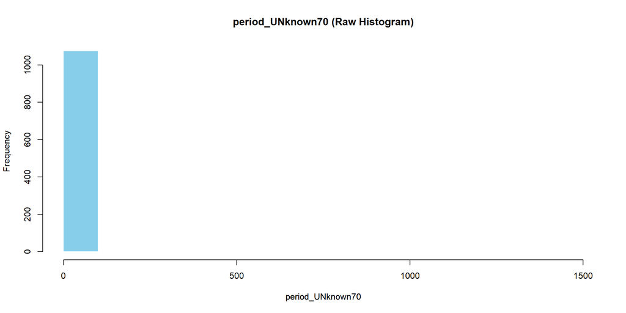

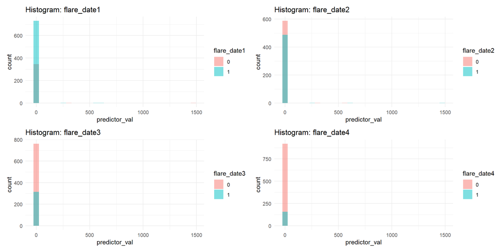

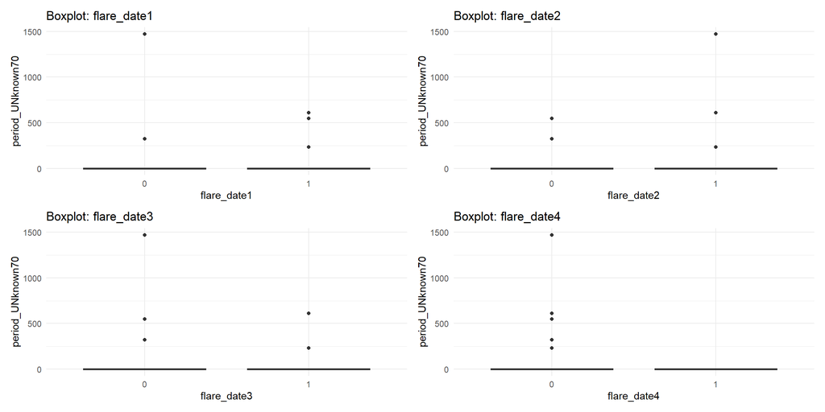

```
##
## ========== ANALYSIS FOR: period_UNknown70 ==========
##
## == Displaying 4 Histograms ==
##
## == Displaying 4 Boxplots ==
##
## == T-test Results on Box-Cox Transformed Predictor ==
##    Dependent t_stat    df p_value
##  flare_date1  0.357 585.8  0.7216
##  flare_date2 -0.639 889.9  0.5231
##  flare_date3 -0.481 483.9  0.6309
##  flare_date4  2.241 924.0  0.0253
```

```r
analyze_numeric_predictor(combined_dataset, "period_UNknown70")
```

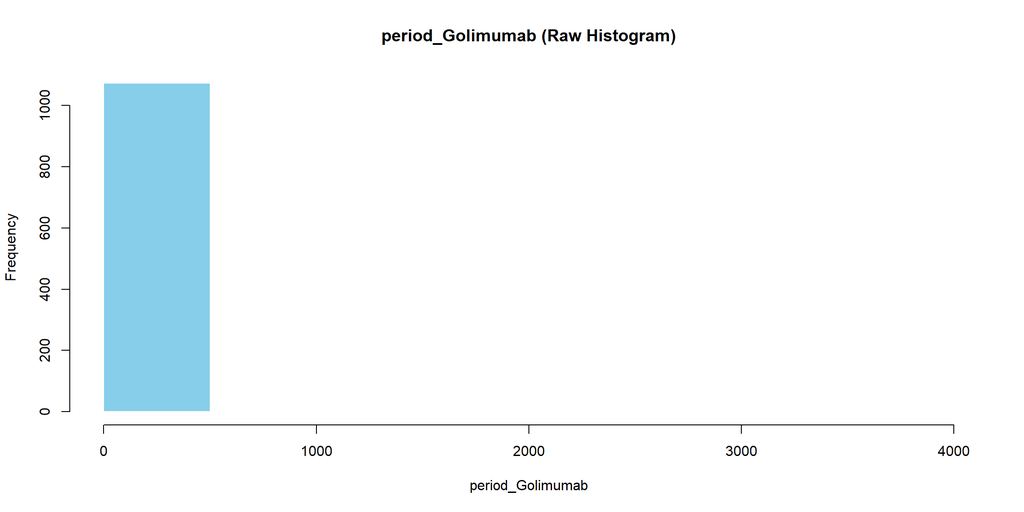

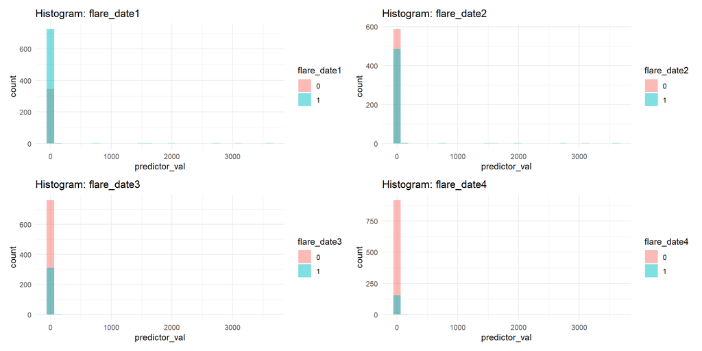

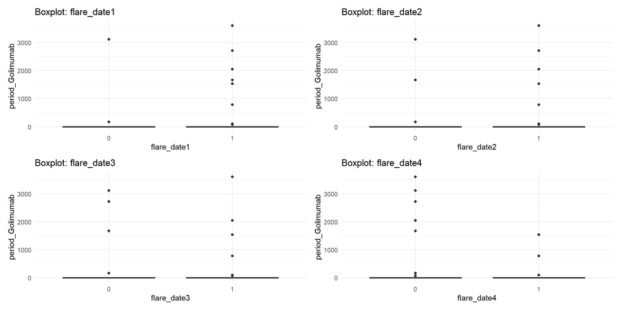

```
##
## ========== ANALYSIS FOR: period_Golimumab ==========
##
## == Displaying 4 Histograms ==
##
## == Displaying 4 Boxplots ==
##
## == T-test Results on Box-Cox Transformed Predictor ==
##    Dependent t_stat    df p_value
##  flare_date1 -0.918 898.8  0.3587
##  flare_date2 -1.502 770.0  0.1334
##  flare_date3 -1.694 389.6   0.091
##  flare_date4 -1.024 176.3  0.3074
```

```r
analyze_numeric_predictor(combined_dataset, "period_Golimumab")
```

```r
str(combined_dataset)
## tibble [1,081 × 67] (S3: tbl_df/tbl/data.frame)
##  $ flare_date1                      : int [1:1081] 1 0 0 0 1 1 1 0 0 1 ...
##  $ flare_date2                      : int [1:1081] 1 1 1 0 0 1 0 0 0 1 ...
##  $ flare_date3                      : int [1:1081] 0 0 0 0 0 1 0 0 0 1 ...
##  $ flare_date4                      : int [1:1081] 0 0 0 0 0 0 0 0 0 1 ...
##  $ DiseaseEntity                    : Factor w/ 2 levels "CD","UC": 2 1 1 2 2 2 1 2 1 2 ...
##  $ gender                           : Factor w/ 2 levels "Male","Female": 1 2 2 1 2 1 1 2 2 2 ...
##  $ age_at_inclusion                 : num [1:1081] 61.1 45.3 33.8 74.3 78.6 ...
##  $ bmi                              : num [1:1081] 27 25.1 21.7 26.6 33.9 ...
##  $ montreal_extent_uc               : Factor w/ 4 levels "1","2","3","9999": 2 4 4 2 2 3 4 2 4 2 ...
##  $ montreal_severity_uc             : Factor w/ 2 levels "0","1": 2 1 1 2 2 2 1 2 1 2 ...
##  $ montreal_age_cd                  : num [1:1081] NA 1 1 NA NA NA 0 NA 0 NA ...
##  $ surg_colon_resection             : Factor w/ 2 levels "0","1": 1 1 1 1 1 1 1 1 1 1 ...
##  $ surg_subtotal_colectomy          : Factor w/ 2 levels "0","1": 1 1 1 1 1 1 1 1 1 1 ...
##  $ surg_fistula_abcess              : Factor w/ 2 levels "0","1": 1 2 1 1 1 1 1 1 1 1 ...
##  $ surg_ileo_anal_pouch             : Factor w/ 2 levels "0","1": 1 1 1 1 1 1 1 1 1 1 ...
##  $ surg_small_bowel_resection       : Factor w/ 2 levels "0","1": 1 1 1 1 1 1 1 1 1 1 ...
##  $ surg_ileocaecal_resection        : Factor w/ 2 levels "0","1": 1 2 1 1 1 1 1 1 1 1 ...
##  $ surg_small_bowel_stoma           : Factor w/ 2 levels "0","1": 1 1 1 1 1 1 1 1 1 1 ...
##  $ surg_colostoma                   : Factor w/ 2 levels "0","1": 1 1 1 1 1 1 1 1 1 1 ...
##  $ surg_proctocolectomy             : Factor w/ 2 levels "0","1": 1 1 1 1 1 1 1 1 1 1 ...
##  $ surg_stoma_reversal              : Factor w/ 2 levels "0","1": 1 1 2 1 1 1 1 1 1 1 ...
##  $ surg_proctectomy                 : Factor w/ 2 levels "0","1": 1 1 1 1 1 1 1 1 1 1 ...
##  $ surg_stenoplasty                 : Factor w/ 2 levels "0","1": 1 1 1 1 1 1 1 1 1 1 ...
##  $ number_of_surgeries              : num [1:1081] 0 2 1 0 0 0 0 0 0 0 ...
##  $ age_at_surg_colon_resection      : num [1:1081] 0 0 0 0 0 0 0 0 0 0 ...
##  $ age_at_surg_subtotal_colectomy   : num [1:1081] 0 0 0 0 0 0 0 0 0 0 ...
##  $ age_at_surg_fistula_abcess       : num [1:1081] 0 36.2 0 0 0 ...
##  $ age_at_surg_ileo_anal_pouch      : num [1:1081] 0 0 0 0 0 0 0 0 0 0 ...
##  $ age_at_surg_small_bowel_resection: num [1:1081] 0 0 0 0 0 0 0 0 0 0 ...
##  $ age_at_surg_ileocaecal_resection : num [1:1081] 0 19.5 0 0 0 ...
##  $ age_at_surg_small_bowel_stoma    : num [1:1081] 0 0 0 0 0 0 0 0 0 0 ...
##  $ age_at_surg_colostoma            : num [1:1081] 0 0 0 0 0 0 0 0 0 0 ...
##  $ age_at_surg_proctocolectomy      : num [1:1081] 0 0 0 0 0 0 0 0 0 0 ...
##  $ age_at_surg_stoma_reversal       : num [1:1081] 0 0 33.7 0 0 ...
##  $ age_at_surg_proctectomy          : num [1:1081] 0 0 0 0 0 0 0 0 0 0 ...
##  $ age_at_surg_stenoplasty          : num [1:1081] 0 0 0 0 0 0 0 0 0 0 ...
##  $ max_age_at_surg                  : num [1:1081] 0 36.2 33.7 0 0 ...
##  $ Family_IBD_final                 : Factor w/ 2 levels "0","1": NA NA NA 1 1 2 1 NA 1 NA ...
##  $ History_colitis                  : Factor w/ 2 levels "0","1": NA NA NA 1 1 2 1 NA 1 NA ...
##  $ History_crohn                    : Factor w/ 2 levels "0","1": NA NA NA 1 1 2 1 NA 1 NA ...
##  $ Anxious_mean                     : num [1:1081] 0 0 0.25 2 0 0 0 0 2 0.5 ...
##  $ Stress_mean                      : num [1:1081] 5.29 2 6.25 5.25 5.29 ...
##  $ Fatigue_mean                     : num [1:1081] 0 4 3 4 0 3 0 4 0 3 ...
##  $ Pain_mean                        : num [1:1081] 0 0 1 1.5 0 0.5 0 0 1 0 ...
##  $ smoker                           : Factor w/ 4 levels "1","2","3","4": 1 2 1 1 1 4 1 1 1 1 ...
##  $ used_Adalimumab                  : Factor w/ 2 levels "0","1": 2 1 1 1 1 1 2 1 2 1 ...
##  $ used_Infliximab_Remicade         : Factor w/ 2 levels "0","1": 1 2 2 1 2 2 1 2 1 1 ...
##  $ used_Vedolizumab                 : Factor w/ 2 levels "0","1": 1 1 1 2 1 1 1 1 1 2 ...
##  $ used_UNknown80                   : Factor w/ 2 levels "0","1": 1 1 1 1 1 1 1 1 1 1 ...
##  $ used_Ustekinumab_Stelara         : Factor w/ 2 levels "0","1": 1 1 1 1 1 1 1 1 1 1 ...
##  $ used_Tofacitinib                 : Factor w/ 2 levels "0","1": 1 1 1 1 1 1 1 1 1 1 ...
##  $ used_UNknown88                   : Factor w/ 2 levels "0","1": 1 1 1 1 1 1 1 1 1 1 ...
##  $ used_UNknown77                   : Factor w/ 2 levels "0","1": 1 1 1 1 1 1 1 1 1 1 ...
##  $ used_UNknown70                   : Factor w/ 2 levels "0","1": 1 1 1 1 1 1 1 1 1 1 ...
##  $ used_Golimumab                   : Factor w/ 2 levels "0","1": 1 1 1 1 1 1 1 1 1 1 ...
##  $ total_medication                 : num [1:1081] 1 1 1 1 1 1 1 1 1 1 ...
##  $ total_medication_period          : num [1:1081] 1942 8708 991 1064 4585 ...
##  $ period_Adalimumab                : num [1:1081] 1942 0 0 0 0 ...
##  $ period_Infliximab_Remicade       : num [1:1081] 0 8708 991 0 4585 ...
##  $ period_Vedolizumab               : num [1:1081] 0 0 0 1064 0 ...
##  $ period_UNknown80                 : num [1:1081] 0 0 0 0 0 0 0 0 0 0 ...
##  $ period_Ustekinumab_Stelara       : num [1:1081] 0 0 0 0 0 0 0 0 0 0 ...
##  $ period_Tofacitinib               : num [1:1081] 0 0 0 0 0 0 0 0 0 0 ...
##  $ period_UNknown88                 : num [1:1081] 0 0 0 0 0 0 0 0 0 0 ...
##  $ period_UNknown77                 : num [1:1081] 0 0 0 0 0 0 0 0 0 0 ...
##  $ period_UNknown70                 : num [1:1081] 0 0 0 0 0 0 0 0 0 0 ...
##  $ period_Golimumab                 : num [1:1081] 0 0 0 0 0 0 0 0 0 0 ...
```

## 3.4 Missing Data Handling

Multiple imputation using MICE with appropriate methods:

- Logistic regression for binary variables (Family_IBD_final, History_colitis, etc.)
- Polytomous regression for multi-category variables (smoker status)
- Predictive mean matching (PMM) for continuous variables (BMI)

which variable contains na:

```r
str(combined_dataset[colSums(is.na(combined_dataset))>1])

#colMeans(is.na(combined_dataset))
## tibble [1,081 × 6] (S3: tbl_df/tbl/data.frame)
##  $ bmi             : num [1:1081] 27 25.1 21.7 26.6 33.9 ...
##  $ montreal_age_cd : num [1:1081] NA 1 1 NA NA NA 0 NA 0 NA ...
##  $ Family_IBD_final: Factor w/ 2 levels "0","1": NA NA NA 1 1 2 1 NA 1 NA ...
##  $ History_colitis : Factor w/ 2 levels "0","1": NA NA NA 1 1 2 1 NA 1 NA ...
##  $ History_crohn   : Factor w/ 2 levels "0","1": NA NA NA 1 1 2 1 NA 1 NA ...
##  $ smoker          : Factor w/ 4 levels "1","2","3","4": 1 2 1 1 1 4 1 1 1 1 ...
```

High missing values in: - montreal_age_cd: 36% - Family_IBD_final: 46% - History_colitis: 49% - History_crohn : 49% - smoker: 20% - bmi : 13%

```r
combined_dataset <- combined_dataset %>%
  mutate(smoker = ifelse(smoker %in% c(3, 4), 3, smoker))

combined_dataset$smoker <- factor(
  combined_dataset$smoker,
  levels = c(1, 2, 3),
  labels = c("Never", "Former", "Current")
)
combined_dataset$Family_IBD_final <- factor(
  combined_dataset$Family_IBD_final,
  levels = c(0,1),
  labels = c("No", "Yes")
)

combined_dataset$History_colitis <- factor(
  combined_dataset$History_colitis,
  levels = c(0,1),
  labels = c("No", "Yes")
)

combined_dataset$History_crohn <- factor(
  combined_dataset$History_crohn,
  levels = c(0,1),
  labels = c("No", "Yes")
)

combined_dataset$montreal_age_cd <- factor(
  combined_dataset$montreal_age_cd,
  levels = c(0,1),
  labels = c("No", "Yes")
)
```

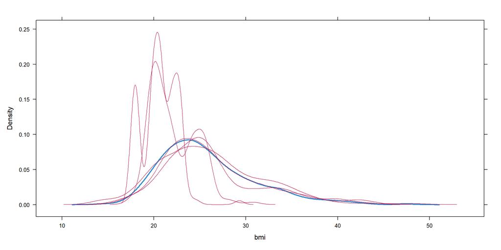

```r
library(mice)
# Define categorical variables
categorical_vars <- c(
  "Family_IBD_final",
  "History_colitis",
  "History_crohn",
  "smoker",
  "montreal_age_cd")


numerical_vars <- c(
  "bmi")

# Check missing data pattern
all_vars <- c(categorical_vars, numerical_vars)

# Initialize mice to get default methods
init <- mice(combined_dataset, maxit = 0)
method <- init$method
predictorMatrix <- init$predictorMatrix

# Set all variables to not be imputed by default
method[] <- ""

# Binary variables (2 categories) - use logreg
binary_vars <- c(
  "Family_IBD_final",        # 0, 1
  "History_colitis",         # 0, 1
  "History_crohn" ,           # 0, 1
  "montreal_age_cd"
  )

method[binary_vars] <- "logreg"

# Multi-category variables - use polyreg
method["smoker"] <- "polyreg"              # 1, 2, 3, 4 (4 categories)


# Set imputation methods for numerical variables
# Use pmm (predictive mean matching) for numerical variables
method[numerical_vars] <- "pmm"


# Perform imputation
imputed_data <- mice(combined_dataset,
                     method = method,
                     m = 5,           # 5 imputed datasets
                     maxit = 10,      # 10 iterations
                     seed = 123,      # reproducibility
                     printFlag = FALSE
                     )

# Get completed dataset (first imputation)
combined_dataset_imputed <- complete(imputed_data, 1)


# Check imputed values
densityplot(imputed_data)
```

## 3.5. Variable Transformation and Selection

This chunk constructs a standardized, disease-aware composite score that integrates objective clinical severity and subjective symptom burden into a single interpretable measure of overall disease impact, improving both clinical validity and predictive stability.

```r
# ==============================================================================
# DISEASE BURDEN COMPOSITE SCORE
# ==============================================================================

combined_dataset_imputed <- combined_dataset_imputed %>%
  mutate(
    # Standardize each component (z-score) before combining
    # This ensures each component contributes equally

    # UC severity component (only for UC patients)
    severity_uc_std = ifelse(
      DiseaseEntity == "UC",
      scale(as.numeric(as.character(montreal_severity_uc)))[,1],
      0
    ),

    # CD surgery component (only for CD patients)
    surgery_cd_std = ifelse(
      DiseaseEntity == "CD",
      scale(as.numeric(as.character(surg_ileocaecal_resection)))[,1],
      0
    ),

    # Universal components (both UC and CD)
    fatigue_std = scale(Fatigue_mean)[,1],
    pain_std = scale(Pain_mean)[,1],

    # Composite disease burden score
    # Average of standardized components
    disease_burden_score = (
      abs(severity_uc_std) +
      abs(surgery_cd_std) +
      abs(fatigue_std) +
      abs(pain_std)
    ) / 4
  )
```

### 3.5.1 Categorization Strategy

Continuous variables undergo systematic evaluation using four categorization schemes:

- Tertiles (Low/Medium/High)
- Quartiles (Q1/Q2/Q3/Q4)
- Median split (Low/High)
- Top 25% (Normal/High)

Chi-square tests determine which categorization best predicts each outcome.

```r
# Main function to categorize and test a numerical predictor
categorize_and_test_predictor <- function(data, predictor_name, outcomes) {

  cat("\n", strrep("=", 80), "\n")
  cat("PROCESSING:", predictor_name, "\n")
  cat(strrep("=", 80), "\n\n")

  # Extract the predictor
  predictor <- data[[predictor_name]]

  # Check for unique values
  n_unique <- length(unique(na.omit(predictor)))
  n_valid <- sum(!is.na(predictor))
  cat("Number of unique values:", n_unique, "\n")
  cat("Number of valid observations:", n_valid, "\n")

  if(n_unique < 2 || n_valid < 10) {
    cat("\nWARNING: Insufficient data for categorization\n")
    return(NULL)
  }

  # Overall summary statistics
  cat("\nOverall summary statistics:\n")
  print(summary(predictor))

  # ==============================================================================
  # Safe cut function
  # ==============================================================================

  safe_cut <- function(x, breaks, labels = NULL, include.lowest = TRUE, right = TRUE) {
    breaks_unique <- unique(breaks)
    if(length(breaks_unique) <= 2) {
      return(rep(NA, length(x)))
    }
    if(!is.null(labels) && length(labels) != (length(breaks_unique) - 1)) {
      labels <- NULL
    }

    result <- cut(x, breaks = breaks_unique, labels = labels,
                 include.lowest = include.lowest, right = right)

    return(result)
  }

  # ==============================================================================
  # Create temporary data with all categorizations
  # ==============================================================================

  temp_data <- data %>%
    mutate(
      predictor = !!sym(predictor_name),

      # Quantile-based categorizations
      cat_q3 = safe_cut(
        predictor,
        breaks = quantile(predictor, probs = c(0, 1/3, 2/3, 1), na.rm = TRUE),
        labels = c("Low", "Medium", "High")
      ),

      cat_q4 = safe_cut(
        predictor,
        breaks = quantile(predictor, probs = c(0, 0.25, 0.5, 0.75, 1), na.rm = TRUE),
        labels = c("Q1", "Q2", "Q3", "Q4")
      ),

      cat_median = safe_cut(
        predictor,
        breaks = c(-Inf, median(predictor, na.rm = TRUE), Inf),
        labels = c("Low", "High")
      ),

      cat_top25 = safe_cut(
        predictor,
        breaks = c(-Inf, quantile(predictor, 0.75, na.rm = TRUE), Inf),
        labels = c("Normal", "High")
      )
    )

  # ==============================================================================
  # Identify valid categorizations
  # ==============================================================================

  cat_vars <- grep("^cat_", names(temp_data), value = TRUE)
  valid_cats <- c()

  cat("\n=== CATEGORIZATION DISTRIBUTIONS ===\n")
  for(cat_var in cat_vars) {
    tbl <- table(temp_data[[cat_var]], useNA = "ifany")
    n_categories <- length(unique(na.omit(temp_data[[cat_var]])))
    n_obs <- sum(!is.na(temp_data[[cat_var]]))

    if(n_categories >= 2 && n_obs >= 10) {
      cat("\n", cat_var, ":\n")
      print(tbl)
      valid_cats <- c(valid_cats, cat_var)
    } else {
      cat("\n", cat_var, ": SKIPPED (insufficient categories or data)\n")
    }
  }

  if(length(valid_cats) == 0) {
    cat("\nERROR: No valid categorizations created\n")
    return(NULL)
  }

  # ==============================================================================
  # Chi-square testing function
  # ==============================================================================

  compute_chisq <- function(data, cat_var, outcome) {

    # Filter out any remaining missing values
    test_data <- data %>%
      filter(!is.na(.data[[cat_var]]), !is.na(.data[[outcome]]))

    if(nrow(test_data) < 10) return(NULL)

    tbl <- table(test_data[[cat_var]], test_data[[outcome]])

    # Remove categories with 0 observations
    if(any(rowSums(tbl) == 0)) {
      tbl <- tbl[rowSums(tbl) > 0, , drop = FALSE]
    }
    if(any(colSums(tbl) == 0)) {
      tbl <- tbl[, colSums(tbl) > 0, drop = FALSE]
    }

    if (min(dim(tbl)) > 0 && all(rowSums(tbl) > 0) && all(colSums(tbl) > 0)) {
      test <- tryCatch({
        chisq.test(tbl)
      }, warning = function(w) {
        if(prod(dim(tbl)) <= 4 && all(tbl < 1000)) {
          fisher.test(tbl, simulate.p.value = TRUE, B = 10000)
        } else {
          chisq.test(tbl)
        }
      }, error = function(e) {
        cat("Error in chi-square test for", cat_var, "vs", outcome, ":", e$message, "\n")
        return(NULL)
      })

      if(!is.null(test)) {
        return(data.frame(
          predictor = predictor_name,
          categorization = cat_var,
          outcome = outcome,
          chi_sq = ifelse("statistic" %in% names(test), round(test$statistic, 3), NA),
          df = ifelse("parameter" %in% names(test), test$parameter, NA),
          p_value = test$p.value,
          p_formatted = ifelse(test$p.value < 0.001, "< 0.001",
                              sprintf("%.4f", test$p.value)),
          n = nrow(test_data)
        ))
      }
    }
    return(NULL)
  }

  # ==============================================================================
  # Test all categorizations against all outcomes
  # ==============================================================================

  results <- expand.grid(
    cat_var = valid_cats,
    outcome = outcomes,
    stringsAsFactors = FALSE
  ) %>%
    rowwise() %>%
    do({
      compute_chisq(temp_data, .$cat_var, .$outcome)
    }) %>%
    ungroup() %>%
    filter(!is.na(p_value)) %>%
    arrange(outcome, p_value)

  cat("\n=== CHI-SQUARE TEST RESULTS ===\n")
  print(results)

  # Find best categorization for each outcome

  best_by_outcome <- results %>%
    group_by(outcome) %>%
    slice_min(p_value, n = 1) %>%
    ungroup()

  cat("\n=== BEST CATEGORIZATION FOR EACH OUTCOME ===\n")
  print(best_by_outcome)

  # Create detailed crosstabs for best categorizations

  cat("\n=== DETAILED CROSSTABS FOR BEST CATEGORIZATIONS ===\n")

  crosstabs_list <- list()

  for(i in 1:nrow(best_by_outcome)) {
    outcome <- best_by_outcome$outcome[i]
    cat_var <- best_by_outcome$categorization[i]

    cat("\n", strrep("-", 80), "\n")
    cat("OUTCOME:", outcome, "| CATEGORIZATION:", cat_var, "\n")
    cat("p-value:", best_by_outcome$p_formatted[i], "| N:", best_by_outcome$n[i], "\n")
    cat(strrep("-", 80), "\n\n")

    tbl <- table(temp_data[[cat_var]], temp_data[[outcome]], useNA = "ifany")
    cat("Frequency table:\n")
    print(tbl)

    cat("\nRow proportions (% within each category):\n")
    row_props <- round(prop.table(tbl, margin = 1) * 100, 1)
    print(row_props)

    crosstabs_list[[outcome]] <- list(
      table = tbl,
      row_proportions = row_props
    )
  }

  # ==============================================================================
  # Return results
  # ==============================================================================

  return(list(
    predictor_name = predictor_name,
    summary_stats = summary(predictor),
    n_unique = n_unique,
    n_valid = n_valid,
    all_results = results,
    best_by_outcome = best_by_outcome,
    crosstabs = crosstabs_list
    ))

}


# Helper function to add best categorizations to main dataset

# Define the function with error handling
add_best_categorizations <- function(data, predictor_name, best_cat) {

  if(is.null(best_cat)) {
    message("No categorization results provided")
    return(data)
  }

  # Extract the predictor values
  predictor <- data[[predictor_name]]

  # Check for sufficient unique values
  n_unique <- length(unique(na.omit(predictor)))
  if(n_unique < 2) {
    warning("Predictor '", predictor_name, "' has fewer than 2 unique values. Cannot categorize.")
    return(data)
  }

  # Safe cut function that checks for unique breaks
  safe_cut <- function(x, breaks, labels, include.lowest = TRUE, right = TRUE) {
    breaks_unique <- unique(breaks)

    if(length(breaks_unique) < 2) {
      warning("Not enough unique break points for categorization")
      return(rep(NA, length(x)))
    }

    # If we don't have enough unique breaks for the labels, adjust
    if(!is.null(labels) && length(labels) != (length(breaks_unique) - 1)) {
      warning("Adjusting labels due to non-unique quantiles")
      labels <- NULL  # Let cut() generate default labels
    }

    result <- cut(x,
                  breaks = breaks_unique,
                  labels = labels,
                  include.lowest = include.lowest,
                  right = right)

    return(result)
  }

  # Apply the appropriate categorization based on best_cat
  if(best_cat == "cat_q3") {
    breaks <- quantile(predictor, probs = c(0, 1/3, 2/3, 1), na.rm = TRUE)
    data[[predictor_name]] <- safe_cut(
      predictor,
      breaks = breaks,
      labels = c("Low", "Medium", "High")
    )
    message("Applied cat_q3 categorization to ", predictor_name)

  } else if(best_cat == "cat_q4") {
    breaks <- quantile(predictor, probs = c(0, 0.25, 0.5, 0.75, 1), na.rm = TRUE)
    data[[predictor_name]] <- safe_cut(
      predictor,
      breaks = breaks,
      labels = c("Q1", "Q2", "Q3", "Q4")
    )
    message("Applied cat_q4 categorization to ", predictor_name)

  } else if(best_cat == "cat_median") {
    breaks <- c(-Inf, median(predictor, na.rm = TRUE), Inf)
    data[[predictor_name]] <- safe_cut(
      predictor,
      breaks = breaks,
      labels = c("Low", "High")
    )
    message("Applied cat_median categorization to ", predictor_name)

  } else if(best_cat == "cat_top25") {
    breaks <- c(-Inf, quantile(predictor, 0.75, na.rm = TRUE), Inf)
    data[[predictor_name]] <- safe_cut(
      predictor,
      breaks = breaks,
      labels = c("Normal", "High")
    )
    message("Applied cat_top25 categorization to ", predictor_name)

  } else {
    message("Unknown categorization type: ", best_cat)
    message("Valid options: cat_q3, cat_q4, cat_median, cat_top25")
  }

  return(data)
}

flare_outcomes <- c("flare_date1", "flare_date2", "flare_date3", "flare_date4")
```

#### disease_burden_score

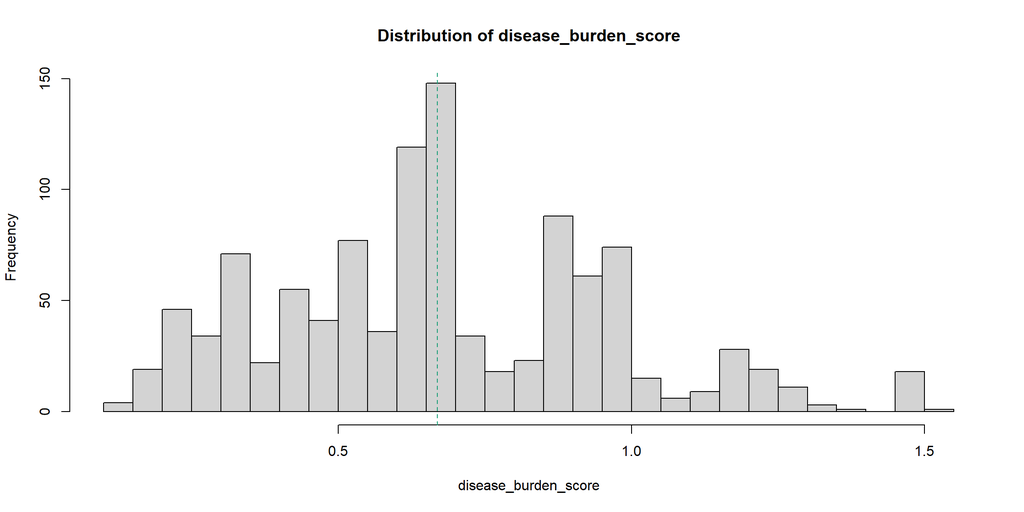

```r
# Visualize distribution
hist(combined_dataset_imputed$disease_burden_score, breaks = 30,
     main = "Distribution of disease_burden_score",
     xlab = "disease_burden_score")
abline(v = c(0, median(combined_dataset_imputed$disease_burden_score, na.rm = TRUE)),
       col = c( "#D95F02", "#1B9E77"), lty = 2)
```

```r
results <- categorize_and_test_predictor(
  data = combined_dataset_imputed,
  predictor_name = "disease_burden_score",
  outcomes = flare_outcomes
)


# Add best categorizations to the main dataset
combined_dataset_imputed <- add_best_categorizations(data= combined_dataset_imputed,
                                                     predictor_name= "disease_burden_score",
                                                     best_cat= "cat_q3"  )


summarize_chisq_for_factor(combined_dataset_imputed, "disease_burden_score")
##
##  ================================================================================
## PROCESSING: disease_burden_score
## ================================================================================
##
## Number of unique values: 237
## Number of valid observations: 1081
##
## Overall summary statistics:
##    Min. 1st Qu.  Median    Mean 3rd Qu.    Max.
##  0.1186  0.4695  0.6685  0.6756  0.8635  1.5429
##
## === CATEGORIZATION DISTRIBUTIONS ===
##
##  cat_q3 :
##
##    Low Medium   High
##    366    358    357
##
##  cat_q4 :
##
##  Q1  Q2  Q3  Q4
## 274 374 175 258
##
##  cat_median :
##
##  Low High
##  648  433
##
##  cat_top25 :
##
## Normal   High
##    823    258
##
## === CHI-SQUARE TEST RESULTS ===
## # A tibble: 16 × 8
##    predictor      categorization outcome chi_sq    df  p_value p_formatted     n
##    <chr>          <chr>          <chr>    <dbl> <int>    <dbl> <chr>       <int>
##  1 disease_burde… cat_q3         flare_… 14.3       2 7.69e- 4 < 0.001      1081
##  2 disease_burde… cat_median     flare_…  0.217     1 6.41e- 1 0.6410       1081
##  3 disease_burde… cat_top25      flare_…  0.066     1 7.97e- 1 0.7971       1081
##  4 disease_burde… cat_q4         flare_…  0.504     3 9.18e- 1 0.9181       1081
##  5 disease_burde… cat_q3         flare_… 42.4       2 6.25e-10 < 0.001      1081
##  6 disease_burde… cat_q4         flare_… 30.9       3 9.01e- 7 < 0.001      1081
##  7 disease_burde… cat_top25      flare_… 12.5       1 4.04e- 4 < 0.001      1081
##  8 disease_burde… cat_median     flare_…  6.97      1 8.30e- 3 0.0083       1081
##  9 disease_burde… cat_q3         flare_… 42.4       2 6.22e-10 < 0.001      1081
## 10 disease_burde… cat_q4         flare_… 33.7       3 2.35e- 7 < 0.001      1081
## 11 disease_burde… cat_top25      flare_… 15.3       1 9.26e- 5 < 0.001      1081
## 12 disease_burde… cat_median     flare_…  6.08      1 1.36e- 2 0.0136       1081
## 13 disease_burde… cat_q3         flare_… 34.8       2 2.83e- 8 < 0.001      1081
## 14 disease_burde… cat_q4         flare_… 28.1       3 3.42e- 6 < 0.001      1081
## 15 disease_burde… cat_top25      flare_… 13.0       1 3.18e- 4 < 0.001      1081
## 16 disease_burde… cat_median     flare_…  5.26      1 2.18e- 2 0.0218       1081
##
## === BEST CATEGORIZATION FOR EACH OUTCOME ===
## # A tibble: 4 × 8
##   predictor       categorization outcome chi_sq    df  p_value p_formatted     n
##   <chr>           <chr>          <chr>    <dbl> <int>    <dbl> <chr>       <int>
## 1 disease_burden… cat_q3         flare_…   14.3     2 7.69e- 4 < 0.001      1081
## 2 disease_burden… cat_q3         flare_…   42.4     2 6.25e-10 < 0.001      1081
## 3 disease_burden… cat_q3         flare_…   42.4     2 6.22e-10 < 0.001      1081
## 4 disease_burden… cat_q3         flare_…   34.8     2 2.83e- 8 < 0.001      1081
##
## === DETAILED CROSSTABS FOR BEST CATEGORIZATIONS ===
##
##  --------------------------------------------------------------------------------
## OUTCOME: flare_date1 | CATEGORIZATION: cat_q3
## p-value: < 0.001 | N: 1081
## --------------------------------------------------------------------------------
##
## Frequency table:
##
##            0   1
##   Low    123 243
##   Medium  89 269
##   High   135 222
##
## Row proportions (% within each category):
##
##             0    1
##   Low    33.6 66.4
##   Medium 24.9 75.1
##   High   37.8 62.2
##
##  --------------------------------------------------------------------------------
## OUTCOME: flare_date2 | CATEGORIZATION: cat_q3
## p-value: < 0.001 | N: 1081
## --------------------------------------------------------------------------------
##
## Frequency table:
##
##            0   1
##   Low    158 208
##   Medium 192 166
##   High   240 117
##
## Row proportions (% within each category):
##
##             0    1
##   Low    43.2 56.8
##   Medium 53.6 46.4
##   High   67.2 32.8
##
##  --------------------------------------------------------------------------------
## OUTCOME: flare_date3 | CATEGORIZATION: cat_q3
## p-value: < 0.001 | N: 1081
## --------------------------------------------------------------------------------
##
## Frequency table:
##
##            0   1
##   Low    221 145
##   Medium 250 108
##   High   294  63
##
## Row proportions (% within each category):
##
##             0    1
##   Low    60.4 39.6
##   Medium 69.8 30.2
##   High   82.4 17.6
##
##  --------------------------------------------------------------------------------
## OUTCOME: flare_date4 | CATEGORIZATION: cat_q3
## p-value: < 0.001 | N: 1081
## --------------------------------------------------------------------------------
##
## Frequency table:
##
##            0   1
##   Low    285  81
##   Medium 307  51
##   High   333  24
##
## Row proportions (% within each category):
##
##             0    1
##   Low    77.9 22.1
##   Medium 85.8 14.2
##   High   93.3  6.7
## x
##   High    Low Medium
##    357    366    358
##
## Chi-squared summary for predictor: disease_burden_score
##         Flare  ChiSq df   p_value
## 1 flare_date1 14.340  2 7.694e-04
## 2 flare_date2 42.386  2 6.252e-10
## 3 flare_date3 42.395  2 6.223e-10
## 4 flare_date4 34.762  2 2.829e-08
```

#### age_at_inclusion

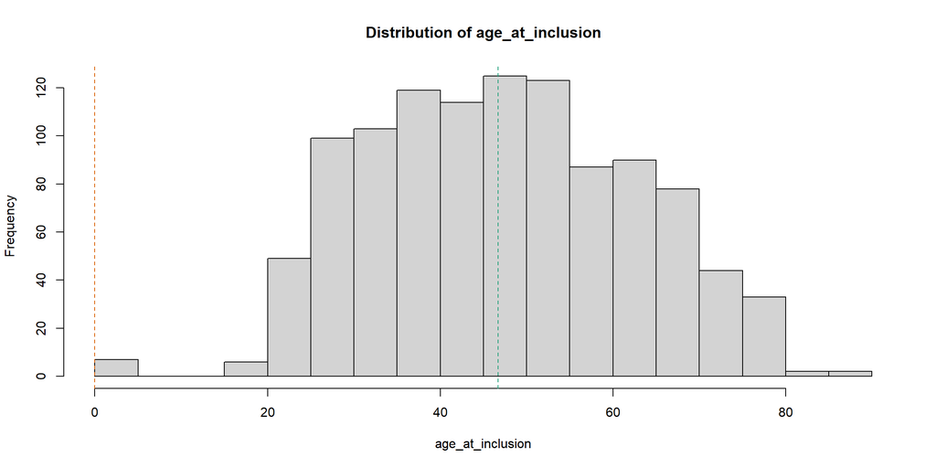

```r
# Visualize distribution
hist(combined_dataset_imputed$age_at_inclusion, breaks = 30,
     main = "Distribution of age_at_inclusion",
     xlab = "age_at_inclusion")
abline(v = c(0, median(combined_dataset_imputed$age_at_inclusion, na.rm = TRUE)),
       col = c( "#D95F02", "#1B9E77"), lty = 2)
```

```r
results <- categorize_and_test_predictor(
  data = combined_dataset_imputed,
  predictor_name = "age_at_inclusion",
  outcomes = flare_outcomes
)


# Add best categorizations to the main dataset
combined_dataset_imputed <- add_best_categorizations(data= combined_dataset_imputed,
                                                     predictor_name= "age_at_inclusion",
                                                     best_cat= "cat_q4"  )


summarize_chisq_for_factor(combined_dataset_imputed, "age_at_inclusion")
##
##  ================================================================================
## PROCESSING: age_at_inclusion
## ================================================================================
##
## Number of unique values: 1053
## Number of valid observations: 1081
##
## Overall summary statistics:
##    Min. 1st Qu.  Median    Mean 3rd Qu.    Max.
##  0.1944 35.2389 46.6886 47.1564 59.0582 87.2882
##
## === CATEGORIZATION DISTRIBUTIONS ===
##
##  cat_q3 :
##
##    Low Medium   High
##    361    360    360
##
##  cat_q4 :
##
##  Q1  Q2  Q3  Q4
## 271 270 270 270
##
##  cat_median :
##
##  Low High
##  541  540
##
##  cat_top25 :
##
## Normal   High
##    811    270
##
## === CHI-SQUARE TEST RESULTS ===
## # A tibble: 16 × 8
##    predictor       categorization outcome chi_sq    df p_value p_formatted     n
##    <chr>           <chr>          <chr>    <dbl> <int>   <dbl> <chr>       <int>
##  1 age_at_inclusi… cat_q4         flare_…  6.69      3 8.26e-2 0.0826       1081
##  2 age_at_inclusi… cat_q3         flare_…  2.46      2 2.92e-1 0.2921       1081
##  3 age_at_inclusi… cat_top25      flare_…  0.862     1 3.53e-1 0.3531       1081
##  4 age_at_inclusi… cat_median     flare_…  0.579     1 4.47e-1 0.4467       1081
##  5 age_at_inclusi… cat_q4         flare_… 24.2       3 2.30e-5 < 0.001      1081
##  6 age_at_inclusi… cat_q3         flare_… 19.2       2 6.69e-5 < 0.001      1081
##  7 age_at_inclusi… cat_top25      flare_… 10.4       1 1.25e-3 0.0013       1081
##  8 age_at_inclusi… cat_median     flare_…  9.50      1 2.06e-3 0.0021       1081
##  9 age_at_inclusi… cat_q3         flare_… 24.5       2 4.73e-6 < 0.001      1081
## 10 age_at_inclusi… cat_q4         flare_… 22.9       3 4.19e-5 < 0.001      1081
## 11 age_at_inclusi… cat_top25      flare_… 14.4       1 1.47e-4 < 0.001      1081
## 12 age_at_inclusi… cat_median     flare_… 13.7       1 2.18e-4 < 0.001      1081
## 13 age_at_inclusi… cat_q4         flare_… 22.7       3 4.58e-5 < 0.001      1081
## 14 age_at_inclusi… cat_top25      flare_… 13.7       1 2.10e-4 < 0.001      1081
## 15 age_at_inclusi… cat_q3         flare_… 15.9       2 3.53e-4 < 0.001      1081
## 16 age_at_inclusi… cat_median     flare_…  6.36      1 1.17e-2 0.0117       1081
##
## === BEST CATEGORIZATION FOR EACH OUTCOME ===
## # A tibble: 4 × 8
##   predictor        categorization outcome chi_sq    df p_value p_formatted     n
##   <chr>            <chr>          <chr>    <dbl> <int>   <dbl> <chr>       <int>
## 1 age_at_inclusion cat_q4         flare_…   6.69     3 8.26e-2 0.0826       1081
## 2 age_at_inclusion cat_q4         flare_…  24.2      3 2.30e-5 < 0.001      1081
## 3 age_at_inclusion cat_q3         flare_…  24.5      2 4.73e-6 < 0.001      1081
## 4 age_at_inclusion cat_q4         flare_…  22.7      3 4.58e-5 < 0.001      1081
##
## === DETAILED CROSSTABS FOR BEST CATEGORIZATIONS ===
##
##  --------------------------------------------------------------------------------
## OUTCOME: flare_date1 | CATEGORIZATION: cat_q4
## p-value: 0.0826 | N: 1081
## --------------------------------------------------------------------------------
##
## Frequency table:
##
##        0   1
##   Q1 103 168
##   Q2  77 193
##   Q3  87 183
##   Q4  80 190
##
## Row proportions (% within each category):
##
##         0    1
##   Q1 38.0 62.0
##   Q2 28.5 71.5
##   Q3 32.2 67.8
##   Q4 29.6 70.4
##
##  --------------------------------------------------------------------------------
## OUTCOME: flare_date2 | CATEGORIZATION: cat_q4
## p-value: < 0.001 | N: 1081
## --------------------------------------------------------------------------------
##
## Frequency table:
##
##        0   1
##   Q1 180  91
##   Q2 141 129
##   Q3 145 125
##   Q4 124 146
##
## Row proportions (% within each category):
##
##         0    1
##   Q1 66.4 33.6
##   Q2 52.2 47.8
##   Q3 53.7 46.3
##   Q4 45.9 54.1
##
##  --------------------------------------------------------------------------------
## OUTCOME: flare_date3 | CATEGORIZATION: cat_q3
## p-value: < 0.001 | N: 1081
## --------------------------------------------------------------------------------
##
## Frequency table:
##
##            0   1
##   Low    287  74
##   Medium 252 108
##   High   226 134
##
## Row proportions (% within each category):
##
##             0    1
##   Low    79.5 20.5
##   Medium 70.0 30.0
##   High   62.8 37.2
##
##  --------------------------------------------------------------------------------
## OUTCOME: flare_date4 | CATEGORIZATION: cat_q4
## p-value: < 0.001 | N: 1081
## --------------------------------------------------------------------------------
##
## Frequency table:
##
##        0   1
##   Q1 251  20
##   Q2 227  43
##   Q3 235  35
##   Q4 212  58
##
## Row proportions (% within each category):
##
##         0    1
##   Q1 92.6  7.4
##   Q2 84.1 15.9
##   Q3 87.0 13.0
##   Q4 78.5 21.5
## x
##  Q1  Q2  Q3  Q4
## 271 270 270 270
##
## Chi-squared summary for predictor: age_at_inclusion
##         Flare  ChiSq df   p_value
## 1 flare_date1  6.686  3 8.262e-02
## 2 flare_date2 24.172  3 2.299e-05
## 3 flare_date3 22.923  3 4.191e-05
## 4 flare_date4 22.739  3 4.576e-05
```

#### bmi

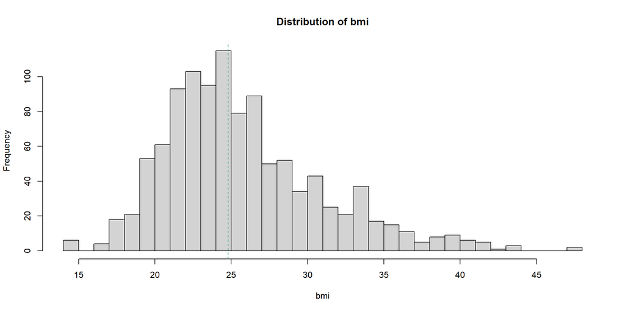

```r
# Visualize distribution
hist(combined_dataset_imputed$bmi, breaks = 30,
     main = "Distribution of bmi",
     xlab = "bmi")
abline(v = c(0, median(combined_dataset_imputed$bmi, na.rm = TRUE)),
       col = c( "#D95F02", "#1B9E77"), lty = 2)
```

```r
results <- categorize_and_test_predictor(
  data = combined_dataset_imputed,
  predictor_name = "bmi",
  outcomes = flare_outcomes
)


# Add best categorizations to the main dataset
combined_dataset_imputed <- add_best_categorizations(data= combined_dataset_imputed,
                                                     predictor_name= "bmi",
                                                     best_cat= "cat_q3"  )


summarize_chisq_for_factor(combined_dataset_imputed, "bmi")
##
##  ================================================================================
## PROCESSING: bmi
## ================================================================================
##
## Number of unique values: 706
## Number of valid observations: 1081
##
## Overall summary statistics:
##    Min. 1st Qu.  Median    Mean 3rd Qu.    Max.
##   14.37   22.21   24.80   25.78   28.41   47.78
##
## === CATEGORIZATION DISTRIBUTIONS ===
##
##  cat_q3 :
##
##    Low Medium   High
##    362    359    360
##
##  cat_q4 :
##
##  Q1  Q2  Q3  Q4
## 271 271 269 270
##
##  cat_median :
##
##  Low High
##  542  539
##
##  cat_top25 :
##
## Normal   High
##    811    270
##
## === CHI-SQUARE TEST RESULTS ===
## # A tibble: 16 × 8
##    predictor categorization outcome     chi_sq    df p_value p_formatted     n
##    <chr>     <chr>          <chr>        <dbl> <int>   <dbl> <chr>       <int>
##  1 bmi       cat_top25      flare_date1  0.332     1   0.564 0.5643       1081
##  2 bmi       cat_q3         flare_date1  0.516     2   0.772 0.7725       1081
##  3 bmi       cat_q4         flare_date1  0.892     3   0.827 0.8275       1081
##  4 bmi       cat_median     flare_date1  0.005     1   0.946 0.9461       1081
##  5 bmi       cat_top25      flare_date2  0.471     1   0.493 0.4925       1081
##  6 bmi       cat_q4         flare_date2  2.07      3   0.558 0.5579       1081
##  7 bmi       cat_median     flare_date2  0.164     1   0.685 0.6851       1081
##  8 bmi       cat_q3         flare_date2  0.178     2   0.915 0.9148       1081
##  9 bmi       cat_q3         flare_date3  4.05      2   0.132 0.1318       1081
## 10 bmi       cat_median     flare_date3  1.13      1   0.288 0.2884       1081
## 11 bmi       cat_top25      flare_date3  0.499     1   0.480 0.4799       1081
## 12 bmi       cat_q4         flare_date3  2.19      3   0.534 0.5337       1081
## 13 bmi       cat_q4         flare_date4  3.53      3   0.317 0.3171       1081
## 14 bmi       cat_q3         flare_date4  1.36      2   0.506 0.5061       1081
## 15 bmi       cat_top25      flare_date4  0.094     1   0.759 0.7587       1081
## 16 bmi       cat_median     flare_date4  0.015     1   0.901 0.9013       1081
##
## === BEST CATEGORIZATION FOR EACH OUTCOME ===
## # A tibble: 4 × 8
##   predictor categorization outcome     chi_sq    df p_value p_formatted     n
##   <chr>     <chr>          <chr>        <dbl> <int>   <dbl> <chr>       <int>
## 1 bmi       cat_top25      flare_date1  0.332     1   0.564 0.5643       1081
## 2 bmi       cat_top25      flare_date2  0.471     1   0.493 0.4925       1081
## 3 bmi       cat_q3         flare_date3  4.05      2   0.132 0.1318       1081
## 4 bmi       cat_q4         flare_date4  3.53      3   0.317 0.3171       1081
##
## === DETAILED CROSSTABS FOR BEST CATEGORIZATIONS ===
##
##  --------------------------------------------------------------------------------
## OUTCOME: flare_date1 | CATEGORIZATION: cat_top25
## p-value: 0.5643 | N: 1081
## --------------------------------------------------------------------------------
##
## Frequency table:
##
##            0   1
##   Normal 256 555
##   High    91 179
##
## Row proportions (% within each category):
##
##             0    1
##   Normal 31.6 68.4
##   High   33.7 66.3
##
##  --------------------------------------------------------------------------------
## OUTCOME: flare_date2 | CATEGORIZATION: cat_top25
## p-value: 0.4925 | N: 1081
## --------------------------------------------------------------------------------
##
## Frequency table:
##
##            0   1
##   Normal 448 363
##   High   142 128
##
## Row proportions (% within each category):
##
##             0    1
##   Normal 55.2 44.8
##   High   52.6 47.4
##
##  --------------------------------------------------------------------------------
## OUTCOME: flare_date3 | CATEGORIZATION: cat_q3
## p-value: 0.1318 | N: 1081
## --------------------------------------------------------------------------------
##
## Frequency table:
##
##            0   1
##   Low    270  92
##   Medium 250 109
##   High   245 115
##
## Row proportions (% within each category):
##
##             0    1
##   Low    74.6 25.4
##   Medium 69.6 30.4
##   High   68.1 31.9
##
##  --------------------------------------------------------------------------------
## OUTCOME: flare_date4 | CATEGORIZATION: cat_q4
## p-value: 0.3171 | N: 1081
## --------------------------------------------------------------------------------
##
## Frequency table:
##
##        0   1
##   Q1 240  31
##   Q2 225  46
##   Q3 231  38
##   Q4 229  41
##
## Row proportions (% within each category):
##
##         0    1
##   Q1 88.6 11.4
##   Q2 83.0 17.0
##   Q3 85.9 14.1
##   Q4 84.8 15.2
## x
##   High    Low Medium
##    360    362    359
##
## Chi-squared summary for predictor: bmi
##         Flare ChiSq df p_value
## 1 flare_date1 0.516  2  0.7725
## 2 flare_date2 0.178  2  0.9148
## 3 flare_date3 4.052  2  0.1318
## 4 flare_date4 1.362  2  0.5061
```

#### number_of_surgeries

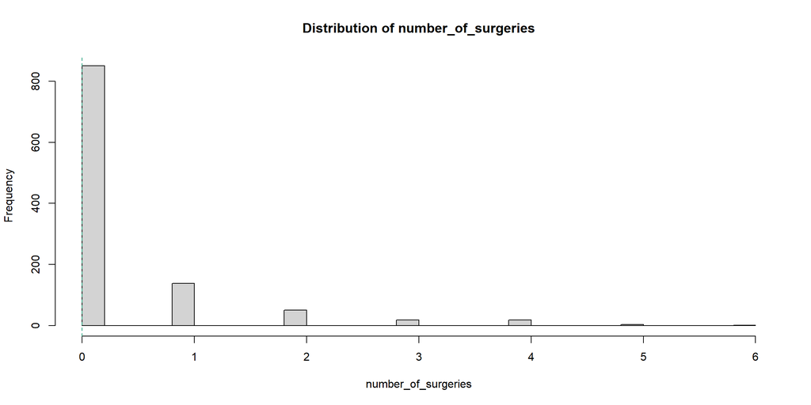

```r
# Visualize distribution
hist(combined_dataset_imputed$number_of_surgeries, breaks = 30,
     main = "Distribution of number_of_surgeries",
     xlab = "number_of_surgeries")
abline(v = c(0, median(combined_dataset_imputed$number_of_surgeries, na.rm = TRUE)),
       col = c( "#D95F02", "#1B9E77"), lty = 2)
```

```r
combined_dataset_imputed$number_of_surgeries <- ifelse(combined_dataset_imputed$number_of_surgeries==0,0,1)
```

#### age_at_surg_colon_resection

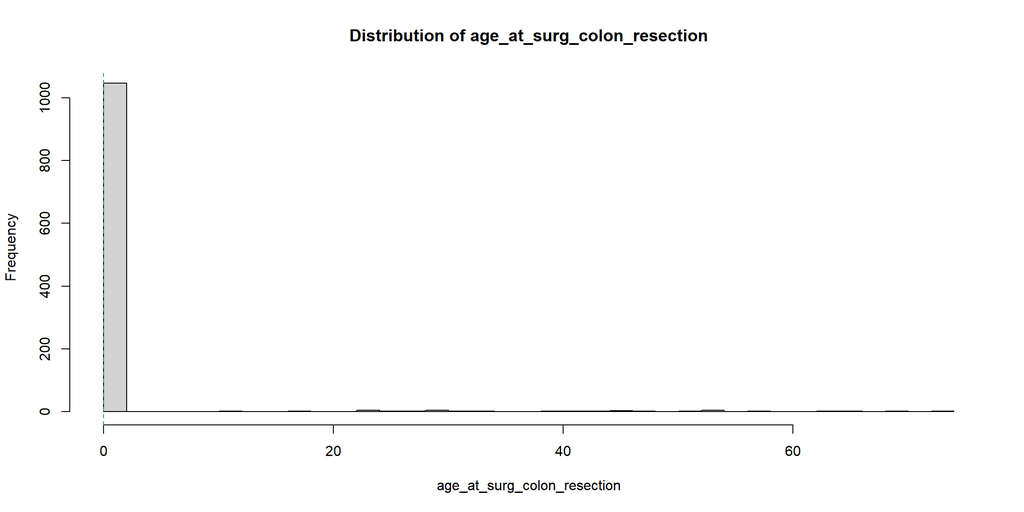

```r
# Visualize distribution
hist(combined_dataset_imputed$age_at_surg_colon_resection, breaks = 30,
     main = "Distribution of age_at_surg_colon_resection",
     xlab = "age_at_surg_colon_resection")
abline(v = c(0, median(combined_dataset_imputed$age_at_surg_colon_resection, na.rm = TRUE)),
       col = c( "#D95F02", "#1B9E77"), lty = 2)
```

```r
results <- categorize_and_test_predictor(
  data = combined_dataset_imputed,
  predictor_name = "age_at_surg_colon_resection",
  outcomes = flare_outcomes
)
combined_dataset_imputed$age_at_surg_colon_resection <- scale(combined_dataset_imputed$age_at_surg_colon_resection)
##
##  ================================================================================
## PROCESSING: age_at_surg_colon_resection
## ================================================================================
##
## Number of unique values: 35
## Number of valid observations: 1081
##
## Overall summary statistics:
##    Min. 1st Qu.  Median    Mean 3rd Qu.    Max.
##   0.000   0.000   0.000   1.262   0.000  73.985
##
## === CATEGORIZATION DISTRIBUTIONS ===
##
##  cat_q3 : SKIPPED (insufficient categories or data)
##
##  cat_q4 : SKIPPED (insufficient categories or data)
##
##  cat_median :
##
##  Low High
## 1047   34
##
##  cat_top25 :
##
## Normal   High
##   1047     34
##
## === CHI-SQUARE TEST RESULTS ===
## # A tibble: 8 × 8
##   predictor        categorization outcome chi_sq    df p_value p_formatted     n
##   <chr>            <chr>          <chr>    <dbl> <int>   <dbl> <chr>       <int>
## 1 age_at_surg_col… cat_median     flare_…   0.35     1   0.554 0.5538       1081
## 2 age_at_surg_col… cat_top25      flare_…   0.35     1   0.554 0.5538       1081
## 3 age_at_surg_col… cat_median     flare_…   0        1   0.984 0.9841       1081
## 4 age_at_surg_col… cat_top25      flare_…   0        1   0.984 0.9841       1081
## 5 age_at_surg_col… cat_median     flare_…   0        1   1.00  1.0000       1081
## 6 age_at_surg_col… cat_top25      flare_…   0        1   1.00  1.0000       1081
## 7 age_at_surg_col… cat_median     flare_…  NA       NA   0.135 0.1353       1081
## 8 age_at_surg_col… cat_top25      flare_…  NA       NA   0.135 0.1353       1081
##
## === BEST CATEGORIZATION FOR EACH OUTCOME ===
## # A tibble: 8 × 8
##   predictor        categorization outcome chi_sq    df p_value p_formatted     n
##   <chr>            <chr>          <chr>    <dbl> <int>   <dbl> <chr>       <int>
## 1 age_at_surg_col… cat_median     flare_…   0.35     1   0.554 0.5538       1081
## 2 age_at_surg_col… cat_top25      flare_…   0.35     1   0.554 0.5538       1081
## 3 age_at_surg_col… cat_median     flare_…   0        1   0.984 0.9841       1081
## 4 age_at_surg_col… cat_top25      flare_…   0        1   0.984 0.9841       1081
## 5 age_at_surg_col… cat_median     flare_…   0        1   1.00  1.0000       1081
## 6 age_at_surg_col… cat_top25      flare_…   0        1   1.00  1.0000       1081
## 7 age_at_surg_col… cat_median     flare_…  NA       NA   0.135 0.1353       1081
## 8 age_at_surg_col… cat_top25      flare_…  NA       NA   0.135 0.1353       1081
##
## === DETAILED CROSSTABS FOR BEST CATEGORIZATIONS ===
##
##  --------------------------------------------------------------------------------
## OUTCOME: flare_date1 | CATEGORIZATION: cat_median
## p-value: 0.5538 | N: 1081
## --------------------------------------------------------------------------------
##
## Frequency table:
##
##          0   1
##   Low  334 713
##   High  13  21
##
## Row proportions (% within each category):
##
##           0    1
##   Low  31.9 68.1
##   High 38.2 61.8
##
##  --------------------------------------------------------------------------------
## OUTCOME: flare_date1 | CATEGORIZATION: cat_top25
## p-value: 0.5538 | N: 1081
## --------------------------------------------------------------------------------
##
## Frequency table:
##
##            0   1
##   Normal 334 713
##   High    13  21
##
## Row proportions (% within each category):
##
##             0    1
##   Normal 31.9 68.1
##   High   38.2 61.8
##
##  --------------------------------------------------------------------------------
## OUTCOME: flare_date2 | CATEGORIZATION: cat_median
## p-value: 0.9841 | N: 1081
## --------------------------------------------------------------------------------
##
## Frequency table:
##
##          0   1
##   Low  572 475
##   High  18  16
##
## Row proportions (% within each category):
##
##           0    1
##   Low  54.6 45.4
##   High 52.9 47.1
##
##  --------------------------------------------------------------------------------
## OUTCOME: flare_date2 | CATEGORIZATION: cat_top25
## p-value: 0.9841 | N: 1081
## --------------------------------------------------------------------------------
##
## Frequency table:
##
##            0   1
##   Normal 572 475
##   High    18  16
##
## Row proportions (% within each category):
##
##             0    1
##   Normal 54.6 45.4
##   High   52.9 47.1
##
##  --------------------------------------------------------------------------------
## OUTCOME: flare_date3 | CATEGORIZATION: cat_median
## p-value: 1.0000 | N: 1081
## --------------------------------------------------------------------------------
##
## Frequency table:
##
##          0   1
##   Low  741 306
##   High  24  10
##
## Row proportions (% within each category):
##
##           0    1
##   Low  70.8 29.2
##   High 70.6 29.4
##
##  --------------------------------------------------------------------------------
## OUTCOME: flare_date3 | CATEGORIZATION: cat_top25
## p-value: 1.0000 | N: 1081
## --------------------------------------------------------------------------------
##
## Frequency table:
##
##            0   1
##   Normal 741 306
##   High    24  10
##
## Row proportions (% within each category):
##
##             0    1
##   Normal 70.8 29.2
##   High   70.6 29.4
##
##  --------------------------------------------------------------------------------
## OUTCOME: flare_date4 | CATEGORIZATION: cat_median
## p-value: 0.1353 | N: 1081
## --------------------------------------------------------------------------------
##
## Frequency table:
##
##          0   1
##   Low  899 148
##   High  26   8
##
## Row proportions (% within each category):
##
##           0    1
##   Low  85.9 14.1
##   High 76.5 23.5
##
##  --------------------------------------------------------------------------------
## OUTCOME: flare_date4 | CATEGORIZATION: cat_top25
## p-value: 0.1353 | N: 1081
## --------------------------------------------------------------------------------
##
## Frequency table:
##
##            0   1
##   Normal 899 148
##   High    26   8
##
## Row proportions (% within each category):
##
##             0    1
##   Normal 85.9 14.1
##   High   76.5 23.5
```

#### age_at_surg_subtotal_colectomy

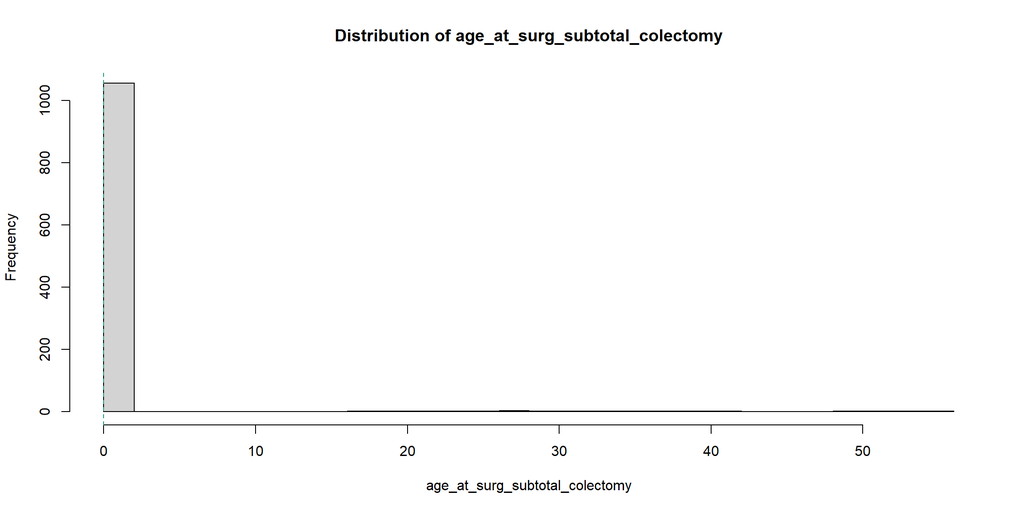

```r
# Visualize distribution
hist(combined_dataset_imputed$age_at_surg_subtotal_colectomy, breaks = 30,
     main = "Distribution of age_at_surg_subtotal_colectomy",
     xlab = "age_at_surg_subtotal_colectomy")
abline(v = c(0, median(combined_dataset_imputed$age_at_surg_subtotal_colectomy, na.rm = TRUE)),
       col = c( "#D95F02", "#1B9E77"), lty = 2)
```

```r
results <- categorize_and_test_predictor(
  data = combined_dataset_imputed,
  predictor_name = "age_at_surg_subtotal_colectomy",
  outcomes = flare_outcomes
)
combined_dataset_imputed$age_at_surg_subtotal_colectomy <- scale(combined_dataset_imputed$age_at_surg_subtotal_colectomy)

##
##  ================================================================================
## PROCESSING: age_at_surg_subtotal_colectomy
## ================================================================================
##
## Number of unique values: 25
## Number of valid observations: 1081
##
## Overall summary statistics:
##    Min. 1st Qu.  Median    Mean 3rd Qu.    Max.
##   0.000   0.000   0.000   0.724   0.000  55.568
##
## === CATEGORIZATION DISTRIBUTIONS ===
##
##  cat_q3 : SKIPPED (insufficient categories or data)
##
##  cat_q4 : SKIPPED (insufficient categories or data)
##
##  cat_median :
##
##  Low High
## 1057   24
##
##  cat_top25 :
##
## Normal   High
##   1057     24
##
## === CHI-SQUARE TEST RESULTS ===
## # A tibble: 8 × 8
##   predictor        categorization outcome chi_sq    df p_value p_formatted     n
##   <chr>            <chr>          <chr>    <dbl> <int>   <dbl> <chr>       <int>
## 1 age_at_surg_sub… cat_median     flare_…  1.53      1   0.216 0.2163       1081
## 2 age_at_surg_sub… cat_top25      flare_…  1.53      1   0.216 0.2163       1081
## 3 age_at_surg_sub… cat_median     flare_…  0.991     1   0.320 0.3195       1081
## 4 age_at_surg_sub… cat_top25      flare_…  0.991     1   0.320 0.3195       1081
## 5 age_at_surg_sub… cat_median     flare_…  0.055     1   0.815 0.8149       1081
## 6 age_at_surg_sub… cat_top25      flare_…  0.055     1   0.815 0.8149       1081
## 7 age_at_surg_sub… cat_median     flare_… NA        NA   1     1.0000       1081
## 8 age_at_surg_sub… cat_top25      flare_… NA        NA   1     1.0000       1081
##
## === BEST CATEGORIZATION FOR EACH OUTCOME ===
## # A tibble: 8 × 8
##   predictor        categorization outcome chi_sq    df p_value p_formatted     n
##   <chr>            <chr>          <chr>    <dbl> <int>   <dbl> <chr>       <int>
## 1 age_at_surg_sub… cat_median     flare_…  1.53      1   0.216 0.2163       1081
## 2 age_at_surg_sub… cat_top25      flare_…  1.53      1   0.216 0.2163       1081
## 3 age_at_surg_sub… cat_median     flare_…  0.991     1   0.320 0.3195       1081
## 4 age_at_surg_sub… cat_top25      flare_…  0.991     1   0.320 0.3195       1081
## 5 age_at_surg_sub… cat_median     flare_…  0.055     1   0.815 0.8149       1081
## 6 age_at_surg_sub… cat_top25      flare_…  0.055     1   0.815 0.8149       1081
## 7 age_at_surg_sub… cat_median     flare_… NA        NA   1     1.0000       1081
## 8 age_at_surg_sub… cat_top25      flare_… NA        NA   1     1.0000       1081
##
## === DETAILED CROSSTABS FOR BEST CATEGORIZATIONS ===
##
##  --------------------------------------------------------------------------------
## OUTCOME: flare_date1 | CATEGORIZATION: cat_median
## p-value: 0.2163 | N: 1081
## --------------------------------------------------------------------------------
##
## Frequency table:
##
##          0   1
##   Low  336 721
##   High  11  13
##
## Row proportions (% within each category):
##
##           0    1
##   Low  31.8 68.2
##   High 45.8 54.2
##
##  --------------------------------------------------------------------------------
## OUTCOME: flare_date1 | CATEGORIZATION: cat_top25
## p-value: 0.2163 | N: 1081
## --------------------------------------------------------------------------------
##
## Frequency table:
##
##            0   1
##   Normal 336 721
##   High    11  13
##
## Row proportions (% within each category):
##
##             0    1
##   Normal 31.8 68.2
##   High   45.8 54.2
##
##  --------------------------------------------------------------------------------
## OUTCOME: flare_date2 | CATEGORIZATION: cat_median
## p-value: 0.3195 | N: 1081
## --------------------------------------------------------------------------------
##
## Frequency table:
##
##          0   1
##   Low  574 483
##   High  16   8
##
## Row proportions (% within each category):
##
##           0    1
##   Low  54.3 45.7
##   High 66.7 33.3
##
##  --------------------------------------------------------------------------------
## OUTCOME: flare_date2 | CATEGORIZATION: cat_top25
## p-value: 0.3195 | N: 1081
## --------------------------------------------------------------------------------
##
## Frequency table:
##
##            0   1
##   Normal 574 483
##   High    16   8
##
## Row proportions (% within each category):
##
##             0    1
##   Normal 54.3 45.7
##   High   66.7 33.3
##
##  --------------------------------------------------------------------------------
## OUTCOME: flare_date3 | CATEGORIZATION: cat_median
## p-value: 0.8149 | N: 1081
## --------------------------------------------------------------------------------
##
## Frequency table:
##
##          0   1
##   Low  747 310
##   High  18   6
##
## Row proportions (% within each category):
##
##           0    1
##   Low  70.7 29.3
##   High 75.0 25.0
##
##  --------------------------------------------------------------------------------
## OUTCOME: flare_date3 | CATEGORIZATION: cat_top25
## p-value: 0.8149 | N: 1081
## --------------------------------------------------------------------------------
##
## Frequency table:
##
##            0   1
##   Normal 747 310
##   High    18   6
##
## Row proportions (% within each category):
##
##             0    1
##   Normal 70.7 29.3
##   High   75.0 25.0
##
##  --------------------------------------------------------------------------------
## OUTCOME: flare_date4 | CATEGORIZATION: cat_median
## p-value: 1.0000 | N: 1081
## --------------------------------------------------------------------------------
##
## Frequency table:
##
##          0   1
##   Low  904 153
##   High  21   3
##
## Row proportions (% within each category):
##
##           0    1
##   Low  85.5 14.5
##   High 87.5 12.5
##
##  --------------------------------------------------------------------------------
## OUTCOME: flare_date4 | CATEGORIZATION: cat_top25
## p-value: 1.0000 | N: 1081
## --------------------------------------------------------------------------------
##
## Frequency table:
##
##            0   1
##   Normal 904 153
##   High    21   3
##
## Row proportions (% within each category):
##
##             0    1
##   Normal 85.5 14.5
##   High   87.5 12.5
```

#### age_at_surg_fistula_abcess

[figure not shown]

```r
# Visualize distribution
hist(combined_dataset_imputed$age_at_surg_fistula_abcess, breaks = 30,
     main = "Distribution of bmi",
     xlab = "bmi")
abline(v = c(0, median(combined_dataset_imputed$age_at_surg_fistula_abcess, na.rm = TRUE)),
       col = c( "#D95F02", "#1B9E77"), lty = 2)
```

```r
results <- categorize_and_test_predictor(
  data = combined_dataset_imputed,
  predictor_name = "age_at_surg_fistula_abcess",
  outcomes = flare_outcomes
)
combined_dataset_imputed$age_at_surg_fistula_abcess <- scale(combined_dataset_imputed$age_at_surg_fistula_abcess)
##
##  ================================================================================
## PROCESSING: age_at_surg_fistula_abcess
## ================================================================================
##
## Number of unique values: 80
## Number of valid observations: 1081
##
## Overall summary statistics:
##    Min. 1st Qu.  Median    Mean 3rd Qu.    Max.
##   0.000   0.000   0.000   2.574   0.000  70.680
##
## === CATEGORIZATION DISTRIBUTIONS ===
##
##  cat_q3 : SKIPPED (insufficient categories or data)
##
##  cat_q4 : SKIPPED (insufficient categories or data)
##
##  cat_median :
##
##  Low High
## 1002   79
##
##  cat_top25 :
##
## Normal   High
##   1002     79
##
## === CHI-SQUARE TEST RESULTS ===
## # A tibble: 8 × 8
##   predictor        categorization outcome chi_sq    df p_value p_formatted     n
##   <chr>            <chr>          <chr>    <dbl> <int>   <dbl> <chr>       <int>
## 1 age_at_surg_fis… cat_median     flare_…  0.618     1   0.432 0.4317       1081
## 2 age_at_surg_fis… cat_top25      flare_…  0.618     1   0.432 0.4317       1081
## 3 age_at_surg_fis… cat_median     flare_…  0         1   1.00  1.0000       1081
## 4 age_at_surg_fis… cat_top25      flare_…  0         1   1.00  1.0000       1081
## 5 age_at_surg_fis… cat_median     flare_…  0.168     1   0.682 0.6822       1081
## 6 age_at_surg_fis… cat_top25      flare_…  0.168     1   0.682 0.6822       1081
## 7 age_at_surg_fis… cat_median     flare_…  0         1   1.00  1.0000       1081
## 8 age_at_surg_fis… cat_top25      flare_…  0         1   1.00  1.0000       1081
##
## === BEST CATEGORIZATION FOR EACH OUTCOME ===
## # A tibble: 8 × 8
##   predictor        categorization outcome chi_sq    df p_value p_formatted     n
##   <chr>            <chr>          <chr>    <dbl> <int>   <dbl> <chr>       <int>
## 1 age_at_surg_fis… cat_median     flare_…  0.618     1   0.432 0.4317       1081
## 2 age_at_surg_fis… cat_top25      flare_…  0.618     1   0.432 0.4317       1081
## 3 age_at_surg_fis… cat_median     flare_…  0         1   1.00  1.0000       1081
## 4 age_at_surg_fis… cat_top25      flare_…  0         1   1.00  1.0000       1081
## 5 age_at_surg_fis… cat_median     flare_…  0.168     1   0.682 0.6822       1081
## 6 age_at_surg_fis… cat_top25      flare_…  0.168     1   0.682 0.6822       1081
## 7 age_at_surg_fis… cat_median     flare_…  0         1   1.00  1.0000       1081
## 8 age_at_surg_fis… cat_top25      flare_…  0         1   1.00  1.0000       1081
##
## === DETAILED CROSSTABS FOR BEST CATEGORIZATIONS ===
##
##  --------------------------------------------------------------------------------
## OUTCOME: flare_date1 | CATEGORIZATION: cat_median
## p-value: 0.4317 | N: 1081
## --------------------------------------------------------------------------------
##
## Frequency table:
##
##          0   1
##   Low  318 684
##   High  29  50
##
## Row proportions (% within each category):
##
##           0    1
##   Low  31.7 68.3
##   High 36.7 63.3
##
##  --------------------------------------------------------------------------------
## OUTCOME: flare_date1 | CATEGORIZATION: cat_top25
## p-value: 0.4317 | N: 1081
## --------------------------------------------------------------------------------
##
## Frequency table:
##
##            0   1
##   Normal 318 684
##   High    29  50
##
## Row proportions (% within each category):
##
##             0    1
##   Normal 31.7 68.3
##   High   36.7 63.3
##
##  --------------------------------------------------------------------------------
## OUTCOME: flare_date2 | CATEGORIZATION: cat_median
## p-value: 1.0000 | N: 1081
## --------------------------------------------------------------------------------
##
## Frequency table:
##
##          0   1
##   Low  547 455
##   High  43  36
##
## Row proportions (% within each category):
##
##           0    1
##   Low  54.6 45.4
##   High 54.4 45.6
##
##  --------------------------------------------------------------------------------
## OUTCOME: flare_date2 | CATEGORIZATION: cat_top25
## p-value: 1.0000 | N: 1081
## --------------------------------------------------------------------------------
##
## Frequency table:
##
##            0   1
##   Normal 547 455
##   High    43  36
##
## Row proportions (% within each category):
##
##             0    1
##   Normal 54.6 45.4
##   High   54.4 45.6
##
##  --------------------------------------------------------------------------------
## OUTCOME: flare_date3 | CATEGORIZATION: cat_median
## p-value: 0.6822 | N: 1081
## --------------------------------------------------------------------------------
##
## Frequency table:
##
##          0   1
##   Low  707 295
##   High  58  21
##
## Row proportions (% within each category):
##
##           0    1
##   Low  70.6 29.4
##   High 73.4 26.6
##
##  --------------------------------------------------------------------------------
## OUTCOME: flare_date3 | CATEGORIZATION: cat_top25
## p-value: 0.6822 | N: 1081
## --------------------------------------------------------------------------------
##
## Frequency table:
##
##            0   1
##   Normal 707 295
##   High    58  21
##
## Row proportions (% within each category):
##
##             0    1
##   Normal 70.6 29.4
##   High   73.4 26.6
##
##  --------------------------------------------------------------------------------
## OUTCOME: flare_date4 | CATEGORIZATION: cat_median
## p-value: 1.0000 | N: 1081
## --------------------------------------------------------------------------------
##
## Frequency table:
##
##          0   1
##   Low  857 145
##   High  68  11
##
## Row proportions (% within each category):
##
##           0    1
##   Low  85.5 14.5
##   High 86.1 13.9
##
##  --------------------------------------------------------------------------------
## OUTCOME: flare_date4 | CATEGORIZATION: cat_top25
## p-value: 1.0000 | N: 1081
## --------------------------------------------------------------------------------
##
## Frequency table:
##
##            0   1
##   Normal 857 145
##   High    68  11
##
## Row proportions (% within each category):
##
##             0    1
##   Normal 85.5 14.5
##   High   86.1 13.9
```

#### age_at_surg_ileo_anal_pouch

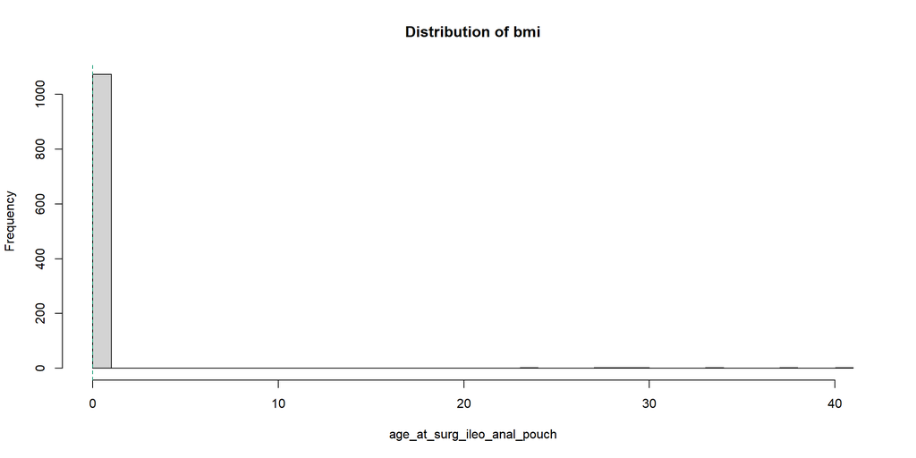

```r
# Visualize distribution
hist(combined_dataset_imputed$age_at_surg_ileo_anal_pouch, breaks = 30,
     main = "Distribution of bmi",
     xlab = "age_at_surg_ileo_anal_pouch")
abline(v = c(0, median(combined_dataset_imputed$age_at_surg_ileo_anal_pouch, na.rm = TRUE)),
       col = c( "#D95F02", "#1B9E77"), lty = 2)
```

```r
results <- categorize_and_test_predictor(
  data = combined_dataset_imputed,
  predictor_name = "age_at_surg_ileo_anal_pouch",
  outcomes = flare_outcomes
)
combined_dataset_imputed$age_at_surg_ileo_anal_pouch <- scale(combined_dataset_imputed$age_at_surg_ileo_anal_pouch)

##
##  ================================================================================
## PROCESSING: age_at_surg_ileo_anal_pouch
## ================================================================================
##
## Number of unique values: 8
## Number of valid observations: 1081
##
## Overall summary statistics:
##    Min. 1st Qu.  Median    Mean 3rd Qu.    Max.
##  0.0000  0.0000  0.0000  0.2059  0.0000 40.6490
##
## === CATEGORIZATION DISTRIBUTIONS ===
##
##  cat_q3 : SKIPPED (insufficient categories or data)
##
##  cat_q4 : SKIPPED (insufficient categories or data)
##
##  cat_median :
##
##  Low High
## 1074    7
##
##  cat_top25 :
##
## Normal   High
##   1074      7
##
## === CHI-SQUARE TEST RESULTS ===
## # A tibble: 8 × 8
##   predictor        categorization outcome chi_sq df    p_value p_formatted     n
##   <chr>            <chr>          <chr>   <lgl>  <lgl>   <dbl> <chr>       <int>
## 1 age_at_surg_ile… cat_median     flare_… NA     NA      0.687 0.6868       1081
## 2 age_at_surg_ile… cat_top25      flare_… NA     NA      0.687 0.6868       1081
## 3 age_at_surg_ile… cat_median     flare_… NA     NA      0.135 0.1348       1081
## 4 age_at_surg_ile… cat_top25      flare_… NA     NA      0.135 0.1348       1081
## 5 age_at_surg_ile… cat_median     flare_… NA     NA      0.113 0.1135       1081
## 6 age_at_surg_ile… cat_top25      flare_… NA     NA      0.113 0.1135       1081
## 7 age_at_surg_ile… cat_median     flare_… NA     NA      0.602 0.6022       1081
## 8 age_at_surg_ile… cat_top25      flare_… NA     NA      0.602 0.6022       1081
##
## === BEST CATEGORIZATION FOR EACH OUTCOME ===
## # A tibble: 8 × 8
##   predictor        categorization outcome chi_sq df    p_value p_formatted     n
##   <chr>            <chr>          <chr>   <lgl>  <lgl>   <dbl> <chr>       <int>
## 1 age_at_surg_ile… cat_median     flare_… NA     NA      0.687 0.6868       1081
## 2 age_at_surg_ile… cat_top25      flare_… NA     NA      0.687 0.6868       1081
## 3 age_at_surg_ile… cat_median     flare_… NA     NA      0.135 0.1348       1081
## 4 age_at_surg_ile… cat_top25      flare_… NA     NA      0.135 0.1348       1081
## 5 age_at_surg_ile… cat_median     flare_… NA     NA      0.113 0.1135       1081
## 6 age_at_surg_ile… cat_top25      flare_… NA     NA      0.113 0.1135       1081
## 7 age_at_surg_ile… cat_median     flare_… NA     NA      0.602 0.6022       1081
## 8 age_at_surg_ile… cat_top25      flare_… NA     NA      0.602 0.6022       1081
##
## === DETAILED CROSSTABS FOR BEST CATEGORIZATIONS ===
##
##  --------------------------------------------------------------------------------
## OUTCOME: flare_date1 | CATEGORIZATION: cat_median
## p-value: 0.6868 | N: 1081
## --------------------------------------------------------------------------------
##
## Frequency table:
##
##          0   1
##   Low  344 730
##   High   3   4
##
## Row proportions (% within each category):
##
##           0    1
##   Low  32.0 68.0
##   High 42.9 57.1
##
##  --------------------------------------------------------------------------------
## OUTCOME: flare_date1 | CATEGORIZATION: cat_top25
## p-value: 0.6868 | N: 1081
## --------------------------------------------------------------------------------
##
## Frequency table:
##
##            0   1
##   Normal 344 730
##   High     3   4
##
## Row proportions (% within each category):
##
##             0    1
##   Normal 32.0 68.0
##   High   42.9 57.1
##
##  --------------------------------------------------------------------------------
## OUTCOME: flare_date2 | CATEGORIZATION: cat_median
## p-value: 0.1348 | N: 1081
## --------------------------------------------------------------------------------
##
## Frequency table:
##
##          0   1
##   Low  584 490
##   High   6   1
##
## Row proportions (% within each category):
##
##           0    1
##   Low  54.4 45.6
##   High 85.7 14.3
##
##  --------------------------------------------------------------------------------
## OUTCOME: flare_date2 | CATEGORIZATION: cat_top25
## p-value: 0.1348 | N: 1081
## --------------------------------------------------------------------------------
##
## Frequency table:
##
##            0   1
##   Normal 584 490
##   High     6   1
##
## Row proportions (% within each category):
##
##             0    1
##   Normal 54.4 45.6
##   High   85.7 14.3
##
##  --------------------------------------------------------------------------------
## OUTCOME: flare_date3 | CATEGORIZATION: cat_median
## p-value: 0.1135 | N: 1081
## --------------------------------------------------------------------------------
##
## Frequency table:
##
##          0   1
##   Low  758 316
##   High   7   0
##
## Row proportions (% within each category):
##
##            0     1
##   Low   70.6  29.4
##   High 100.0   0.0
##
##  --------------------------------------------------------------------------------
## OUTCOME: flare_date3 | CATEGORIZATION: cat_top25
## p-value: 0.1135 | N: 1081
## --------------------------------------------------------------------------------
##
## Frequency table:
##
##            0   1
##   Normal 758 316
##   High     7   0
##
## Row proportions (% within each category):
##
##              0     1
##   Normal  70.6  29.4
##   High   100.0   0.0
##
##  --------------------------------------------------------------------------------
## OUTCOME: flare_date4 | CATEGORIZATION: cat_median
## p-value: 0.6022 | N: 1081
## --------------------------------------------------------------------------------
##
## Frequency table:
##
##          0   1
##   Low  918 156
##   High   7   0
##
## Row proportions (% within each category):
##
##            0     1
##   Low   85.5  14.5
##   High 100.0   0.0
##
##  --------------------------------------------------------------------------------
## OUTCOME: flare_date4 | CATEGORIZATION: cat_top25
## p-value: 0.6022 | N: 1081
## --------------------------------------------------------------------------------
##
## Frequency table:
##
##            0   1
##   Normal 918 156
##   High     7   0
##
## Row proportions (% within each category):
##
##              0     1
##   Normal  85.5  14.5
##   High   100.0   0.0
```

#### age_at_surg_small_bowel_resection

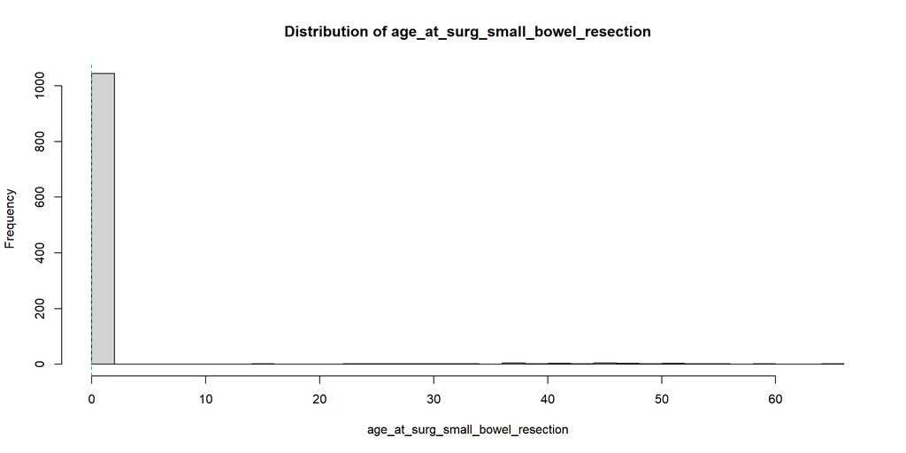

```r
# Visualize distribution
hist(combined_dataset_imputed$age_at_surg_small_bowel_resection, breaks = 30,
     main = "Distribution of age_at_surg_small_bowel_resection",
     xlab = "age_at_surg_small_bowel_resection")
abline(v = c(0, median(combined_dataset_imputed$age_at_surg_small_bowel_resection, na.rm = TRUE)),
       col = c( "#D95F02", "#1B9E77"), lty = 2)
```

```r
results <- categorize_and_test_predictor(
  data = combined_dataset_imputed,
  predictor_name = "age_at_surg_small_bowel_resection",
  outcomes = flare_outcomes
)


# Add best categorizations to the main dataset
combined_dataset_imputed <- add_best_categorizations(data= combined_dataset_imputed,
                                                     predictor_name= "age_at_surg_small_bowel_resection",
                                                     best_cat= "cat_median"  )


summarize_chisq_for_factor(combined_dataset_imputed, "age_at_surg_small_bowel_resection")
##
##  ================================================================================
## PROCESSING: age_at_surg_small_bowel_resection
## ================================================================================
##
## Number of unique values: 37
## Number of valid observations: 1081
##
## Overall summary statistics:
##    Min. 1st Qu.  Median    Mean 3rd Qu.    Max.
##   0.000   0.000   0.000   1.376   0.000  64.550
##
## === CATEGORIZATION DISTRIBUTIONS ===
##
##  cat_q3 : SKIPPED (insufficient categories or data)
##
##  cat_q4 : SKIPPED (insufficient categories or data)
##
##  cat_median :
##
##  Low High
## 1045   36
##
##  cat_top25 :
##
## Normal   High
##   1045     36
##
## === CHI-SQUARE TEST RESULTS ===
## # A tibble: 8 × 8
##   predictor        categorization outcome chi_sq    df p_value p_formatted     n
##   <chr>            <chr>          <chr>    <dbl> <int>   <dbl> <chr>       <int>
## 1 age_at_surg_sma… cat_median     flare_…  2.05      1   0.152 0.1521       1081
## 2 age_at_surg_sma… cat_top25      flare_…  2.05      1   0.152 0.1521       1081
## 3 age_at_surg_sma… cat_median     flare_…  0.084     1   0.772 0.7719       1081
## 4 age_at_surg_sma… cat_top25      flare_…  0.084     1   0.772 0.7719       1081
## 5 age_at_surg_sma… cat_median     flare_…  0.146     1   0.703 0.7028       1081
## 6 age_at_surg_sma… cat_top25      flare_…  0.146     1   0.703 0.7028       1081
## 7 age_at_surg_sma… cat_median     flare_…  1.24      1   0.266 0.2662       1081
## 8 age_at_surg_sma… cat_top25      flare_…  1.24      1   0.266 0.2662       1081
##
## === BEST CATEGORIZATION FOR EACH OUTCOME ===
## # A tibble: 8 × 8
##   predictor        categorization outcome chi_sq    df p_value p_formatted     n
##   <chr>            <chr>          <chr>    <dbl> <int>   <dbl> <chr>       <int>
## 1 age_at_surg_sma… cat_median     flare_…  2.05      1   0.152 0.1521       1081
## 2 age_at_surg_sma… cat_top25      flare_…  2.05      1   0.152 0.1521       1081
## 3 age_at_surg_sma… cat_median     flare_…  0.084     1   0.772 0.7719       1081
## 4 age_at_surg_sma… cat_top25      flare_…  0.084     1   0.772 0.7719       1081
## 5 age_at_surg_sma… cat_median     flare_…  0.146     1   0.703 0.7028       1081
## 6 age_at_surg_sma… cat_top25      flare_…  0.146     1   0.703 0.7028       1081
## 7 age_at_surg_sma… cat_median     flare_…  1.24      1   0.266 0.2662       1081
## 8 age_at_surg_sma… cat_top25      flare_…  1.24      1   0.266 0.2662       1081
##
## === DETAILED CROSSTABS FOR BEST CATEGORIZATIONS ===
##
##  --------------------------------------------------------------------------------
## OUTCOME: flare_date1 | CATEGORIZATION: cat_median
## p-value: 0.1521 | N: 1081
## --------------------------------------------------------------------------------
##
## Frequency table:
##
##          0   1
##   Low  331 714
##   High  16  20
##
## Row proportions (% within each category):
##
##           0    1
##   Low  31.7 68.3
##   High 44.4 55.6
##
##  --------------------------------------------------------------------------------
## OUTCOME: flare_date1 | CATEGORIZATION: cat_top25
## p-value: 0.1521 | N: 1081
## --------------------------------------------------------------------------------
##
## Frequency table:
##
##            0   1
##   Normal 331 714
##   High    16  20
##
## Row proportions (% within each category):
##
##             0    1
##   Normal 31.7 68.3
##   High   44.4 55.6
##
##  --------------------------------------------------------------------------------
## OUTCOME: flare_date2 | CATEGORIZATION: cat_median
## p-value: 0.7719 | N: 1081
## --------------------------------------------------------------------------------
##
## Frequency table:
##
##          0   1
##   Low  569 476
##   High  21  15
##
## Row proportions (% within each category):
##
##           0    1
##   Low  54.4 45.6
##   High 58.3 41.7
##
##  --------------------------------------------------------------------------------
## OUTCOME: flare_date2 | CATEGORIZATION: cat_top25
## p-value: 0.7719 | N: 1081
## --------------------------------------------------------------------------------
##
## Frequency table:
##
##            0   1
##   Normal 569 476
##   High    21  15
##
## Row proportions (% within each category):
##
##             0    1
##   Normal 54.4 45.6
##   High   58.3 41.7
##
##  --------------------------------------------------------------------------------
## OUTCOME: flare_date3 | CATEGORIZATION: cat_median
## p-value: 0.7028 | N: 1081
## --------------------------------------------------------------------------------
##
## Frequency table:
##
##          0   1
##   Low  738 307
##   High  27   9
##
## Row proportions (% within each category):
##
##           0    1
##   Low  70.6 29.4
##   High 75.0 25.0
##
##  --------------------------------------------------------------------------------
## OUTCOME: flare_date3 | CATEGORIZATION: cat_top25
## p-value: 0.7028 | N: 1081
## --------------------------------------------------------------------------------
##
## Frequency table:
##
##            0   1
##   Normal 738 307
##   High    27   9
##
## Row proportions (% within each category):
##
##             0    1
##   Normal 70.6 29.4
##   High   75.0 25.0
##
##  --------------------------------------------------------------------------------
## OUTCOME: flare_date4 | CATEGORIZATION: cat_median
## p-value: 0.2662 | N: 1081
## --------------------------------------------------------------------------------
##
## Frequency table:
##
##          0   1
##   Low  897 148
##   High  28   8
##
## Row proportions (% within each category):
##
##           0    1
##   Low  85.8 14.2
##   High 77.8 22.2
##
##  --------------------------------------------------------------------------------
## OUTCOME: flare_date4 | CATEGORIZATION: cat_top25
## p-value: 0.2662 | N: 1081
## --------------------------------------------------------------------------------
##
## Frequency table:
##
##            0   1
##   Normal 897 148
##   High    28   8
##
## Row proportions (% within each category):
##
##             0    1
##   Normal 85.8 14.2
##   High   77.8 22.2
## x
## High  Low
##   36 1045
##
## Chi-squared summary for predictor: age_at_surg_small_bowel_resection
##         Flare ChiSq df p_value
## 1 flare_date1 2.051  1  0.1521
## 2 flare_date2 0.084  1  0.7719
## 3 flare_date3 0.146  1  0.7028
## 4 flare_date4 1.236  1  0.2662
```

#### age_at_surg_ileocaecal_resection

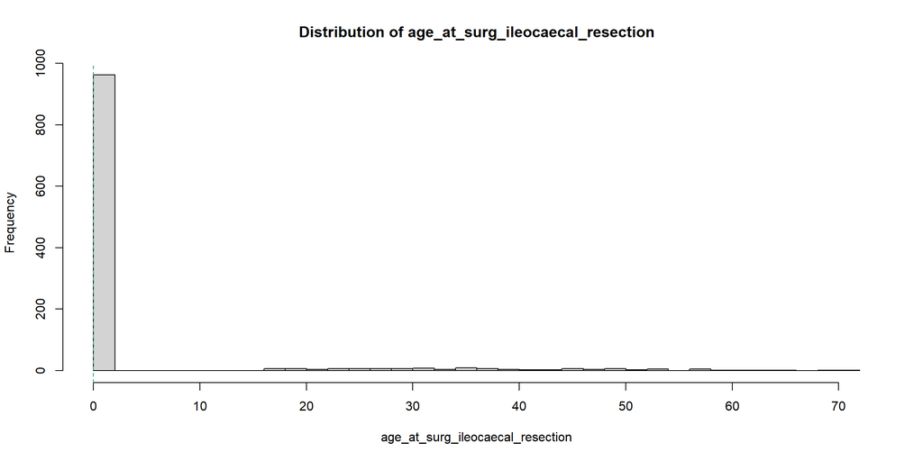

```r
# Visualize distribution
hist(combined_dataset_imputed$age_at_surg_ileocaecal_resection, breaks = 30,
     main = "Distribution of age_at_surg_ileocaecal_resection",
     xlab = "age_at_surg_ileocaecal_resection")
abline(v = c(0, median(combined_dataset_imputed$age_at_surg_ileocaecal_resection, na.rm = TRUE)),
       col = c( "#D95F02", "#1B9E77"), lty = 2)
```

```r
results <- categorize_and_test_predictor(
  data = combined_dataset_imputed,
  predictor_name = "age_at_surg_ileocaecal_resection",
  outcomes = flare_outcomes
)


# Add best categorizations to the main dataset
combined_dataset_imputed <- add_best_categorizations(data= combined_dataset_imputed,
                                                     predictor_name= "age_at_surg_ileocaecal_resection",
                                                     best_cat= "cat_median"  )


summarize_chisq_for_factor(combined_dataset_imputed, "age_at_surg_ileocaecal_resection")
##
##  ================================================================================
## PROCESSING: age_at_surg_ileocaecal_resection
## ================================================================================
##
## Number of unique values: 119
## Number of valid observations: 1081
##
## Overall summary statistics:
##    Min. 1st Qu.  Median    Mean 3rd Qu.    Max.
##   0.000   0.000   0.000   3.954   0.000  70.539
##
## === CATEGORIZATION DISTRIBUTIONS ===
##
##  cat_q3 : SKIPPED (insufficient categories or data)
##
##  cat_q4 : SKIPPED (insufficient categories or data)
##
##  cat_median :
##
##  Low High
##  963  118
##
##  cat_top25 :
##
## Normal   High
##    963    118
##
## === CHI-SQUARE TEST RESULTS ===
## # A tibble: 8 × 8
##   predictor        categorization outcome chi_sq    df p_value p_formatted     n
##   <chr>            <chr>          <chr>    <dbl> <int>   <dbl> <chr>       <int>
## 1 age_at_surg_ile… cat_median     flare_…  9.33      1 0.00225 0.0023       1081
## 2 age_at_surg_ile… cat_top25      flare_…  9.33      1 0.00225 0.0023       1081
## 3 age_at_surg_ile… cat_median     flare_…  1.43      1 0.232   0.2324       1081
## 4 age_at_surg_ile… cat_top25      flare_…  1.43      1 0.232   0.2324       1081
## 5 age_at_surg_ile… cat_median     flare_…  0.412     1 0.521   0.5208       1081
## 6 age_at_surg_ile… cat_top25      flare_…  0.412     1 0.521   0.5208       1081
## 7 age_at_surg_ile… cat_median     flare_…  0.022     1 0.883   0.8833       1081
## 8 age_at_surg_ile… cat_top25      flare_…  0.022     1 0.883   0.8833       1081
##
## === BEST CATEGORIZATION FOR EACH OUTCOME ===
## # A tibble: 8 × 8
##   predictor        categorization outcome chi_sq    df p_value p_formatted     n
##   <chr>            <chr>          <chr>    <dbl> <int>   <dbl> <chr>       <int>
## 1 age_at_surg_ile… cat_median     flare_…  9.33      1 0.00225 0.0023       1081
## 2 age_at_surg_ile… cat_top25      flare_…  9.33      1 0.00225 0.0023       1081
## 3 age_at_surg_ile… cat_median     flare_…  1.43      1 0.232   0.2324       1081
## 4 age_at_surg_ile… cat_top25      flare_…  1.43      1 0.232   0.2324       1081
## 5 age_at_surg_ile… cat_median     flare_…  0.412     1 0.521   0.5208       1081
## 6 age_at_surg_ile… cat_top25      flare_…  0.412     1 0.521   0.5208       1081
## 7 age_at_surg_ile… cat_median     flare_…  0.022     1 0.883   0.8833       1081
## 8 age_at_surg_ile… cat_top25      flare_…  0.022     1 0.883   0.8833       1081
##
## === DETAILED CROSSTABS FOR BEST CATEGORIZATIONS ===
##
##  --------------------------------------------------------------------------------
## OUTCOME: flare_date1 | CATEGORIZATION: cat_median
## p-value: 0.0023 | N: 1081
## --------------------------------------------------------------------------------
##
## Frequency table:
##
##          0   1
##   Low  294 669
##   High  53  65
##
## Row proportions (% within each category):
##
##           0    1
##   Low  30.5 69.5
##   High 44.9 55.1
##
##  --------------------------------------------------------------------------------
## OUTCOME: flare_date1 | CATEGORIZATION: cat_top25
## p-value: 0.0023 | N: 1081
## --------------------------------------------------------------------------------
##
## Frequency table:
##
##            0   1
##   Normal 294 669
##   High    53  65
##
## Row proportions (% within each category):
##
##             0    1
##   Normal 30.5 69.5
##   High   44.9 55.1
##
##  --------------------------------------------------------------------------------
## OUTCOME: flare_date2 | CATEGORIZATION: cat_median
## p-value: 0.2324 | N: 1081
## --------------------------------------------------------------------------------
##
## Frequency table:
##
##          0   1
##   Low  519 444
##   High  71  47
##
## Row proportions (% within each category):
##
##           0    1
##   Low  53.9 46.1
##   High 60.2 39.8
##
##  --------------------------------------------------------------------------------
## OUTCOME: flare_date2 | CATEGORIZATION: cat_top25
## p-value: 0.2324 | N: 1081
## --------------------------------------------------------------------------------
##
## Frequency table:
##
##            0   1
##   Normal 519 444
##   High    71  47
##
## Row proportions (% within each category):
##
##             0    1
##   Normal 53.9 46.1
##   High   60.2 39.8
##
##  --------------------------------------------------------------------------------
## OUTCOME: flare_date3 | CATEGORIZATION: cat_median
## p-value: 0.5208 | N: 1081
## --------------------------------------------------------------------------------
##
## Frequency table:
##
##          0   1
##   Low  678 285
##   High  87  31
##
## Row proportions (% within each category):
##
##           0    1
##   Low  70.4 29.6
##   High 73.7 26.3
##
##  --------------------------------------------------------------------------------
## OUTCOME: flare_date3 | CATEGORIZATION: cat_top25
## p-value: 0.5208 | N: 1081
## --------------------------------------------------------------------------------
##
## Frequency table:
##
##            0   1
##   Normal 678 285
##   High    87  31
##
## Row proportions (% within each category):
##
##             0    1
##   Normal 70.4 29.6
##   High   73.7 26.3
##
##  --------------------------------------------------------------------------------
## OUTCOME: flare_date4 | CATEGORIZATION: cat_median
## p-value: 0.8833 | N: 1081
## --------------------------------------------------------------------------------
##
## Frequency table:
##
##          0   1
##   Low  823 140
##   High 102  16
##
## Row proportions (% within each category):
##
##           0    1
##   Low  85.5 14.5
##   High 86.4 13.6
##
##  --------------------------------------------------------------------------------
## OUTCOME: flare_date4 | CATEGORIZATION: cat_top25
## p-value: 0.8833 | N: 1081
## --------------------------------------------------------------------------------
##
## Frequency table:
##
##            0   1
##   Normal 823 140
##   High   102  16
##
## Row proportions (% within each category):
##
##             0    1
##   Normal 85.5 14.5
##   High   86.4 13.6
## x
## High  Low
##  118  963
##
## Chi-squared summary for predictor: age_at_surg_ileocaecal_resection
##         Flare ChiSq df  p_value
## 1 flare_date1 9.332  1 0.002252
## 2 flare_date2 1.426  1 0.232400
## 3 flare_date3 0.412  1 0.520800
## 4 flare_date4 0.022  1 0.883300
```

#### age_at_surg_small_bowel_stoma

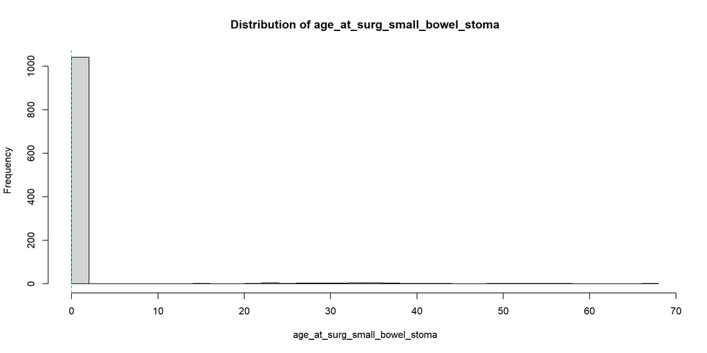

```r
# Visualize distribution
hist(combined_dataset_imputed$age_at_surg_small_bowel_stoma, breaks = 30,
     main = "Distribution of age_at_surg_small_bowel_stoma",
     xlab = "age_at_surg_small_bowel_stoma")
abline(v = c(0, median(combined_dataset_imputed$age_at_surg_small_bowel_stoma, na.rm = TRUE)),
       col = c( "#D95F02", "#1B9E77"), lty = 2)
```

```r
results <- categorize_and_test_predictor(
  data = combined_dataset_imputed,
  predictor_name = "age_at_surg_small_bowel_stoma",
  outcomes = flare_outcomes
)


# Add best categorizations to the main dataset
combined_dataset_imputed <- add_best_categorizations(data= combined_dataset_imputed,
                                                     predictor_name= "age_at_surg_small_bowel_stoma",
                                                     best_cat= "cat_median"  )


summarize_chisq_for_factor(combined_dataset_imputed, "age_at_surg_small_bowel_stoma")
##
##  ================================================================================
## PROCESSING: age_at_surg_small_bowel_stoma
## ================================================================================
##
## Number of unique values: 40
## Number of valid observations: 1081
##
## Overall summary statistics:
##    Min. 1st Qu.  Median    Mean 3rd Qu.    Max.
##   0.000   0.000   0.000   1.253   0.000  67.493
##
## === CATEGORIZATION DISTRIBUTIONS ===
##
##  cat_q3 : SKIPPED (insufficient categories or data)
##
##  cat_q4 : SKIPPED (insufficient categories or data)
##
##  cat_median :
##
##  Low High
## 1042   39
##
##  cat_top25 :
##
## Normal   High
##   1042     39
##
## === CHI-SQUARE TEST RESULTS ===
## # A tibble: 8 × 8
##   predictor        categorization outcome chi_sq    df p_value p_formatted     n
##   <chr>            <chr>          <chr>    <dbl> <int>   <dbl> <chr>       <int>
## 1 age_at_surg_sma… cat_median     flare_…  1.93      1   0.164 0.1643       1081
## 2 age_at_surg_sma… cat_top25      flare_…  1.93      1   0.164 0.1643       1081
## 3 age_at_surg_sma… cat_median     flare_…  1.11      1   0.292 0.2924       1081
## 4 age_at_surg_sma… cat_top25      flare_…  1.11      1   0.292 0.2924       1081
## 5 age_at_surg_sma… cat_median     flare_…  0.001     1   0.972 0.9716       1081
## 6 age_at_surg_sma… cat_top25      flare_…  0.001     1   0.972 0.9716       1081
## 7 age_at_surg_sma… cat_median     flare_…  0.755     1   0.385 0.3850       1081
## 8 age_at_surg_sma… cat_top25      flare_…  0.755     1   0.385 0.3850       1081
##
## === BEST CATEGORIZATION FOR EACH OUTCOME ===
## # A tibble: 8 × 8
##   predictor        categorization outcome chi_sq    df p_value p_formatted     n
##   <chr>            <chr>          <chr>    <dbl> <int>   <dbl> <chr>       <int>
## 1 age_at_surg_sma… cat_median     flare_…  1.93      1   0.164 0.1643       1081
## 2 age_at_surg_sma… cat_top25      flare_…  1.93      1   0.164 0.1643       1081
## 3 age_at_surg_sma… cat_median     flare_…  1.11      1   0.292 0.2924       1081
## 4 age_at_surg_sma… cat_top25      flare_…  1.11      1   0.292 0.2924       1081
## 5 age_at_surg_sma… cat_median     flare_…  0.001     1   0.972 0.9716       1081
## 6 age_at_surg_sma… cat_top25      flare_…  0.001     1   0.972 0.9716       1081
## 7 age_at_surg_sma… cat_median     flare_…  0.755     1   0.385 0.3850       1081
## 8 age_at_surg_sma… cat_top25      flare_…  0.755     1   0.385 0.3850       1081
##
## === DETAILED CROSSTABS FOR BEST CATEGORIZATIONS ===
##
##  --------------------------------------------------------------------------------
## OUTCOME: flare_date1 | CATEGORIZATION: cat_median
## p-value: 0.1643 | N: 1081
## --------------------------------------------------------------------------------
##
## Frequency table:
##
##          0   1
##   Low  330 712
##   High  17  22
##
## Row proportions (% within each category):
##
##           0    1
##   Low  31.7 68.3
##   High 43.6 56.4
##
##  --------------------------------------------------------------------------------
## OUTCOME: flare_date1 | CATEGORIZATION: cat_top25
## p-value: 0.1643 | N: 1081
## --------------------------------------------------------------------------------
##
## Frequency table:
##
##            0   1
##   Normal 330 712
##   High    17  22
##
## Row proportions (% within each category):
##
##             0    1
##   Normal 31.7 68.3
##   High   43.6 56.4
##
##  --------------------------------------------------------------------------------
## OUTCOME: flare_date2 | CATEGORIZATION: cat_median
## p-value: 0.2924 | N: 1081
## --------------------------------------------------------------------------------
##
## Frequency table:
##
##          0   1
##   Low  565 477
##   High  25  14
##
## Row proportions (% within each category):
##
##           0    1
##   Low  54.2 45.8
##   High 64.1 35.9
##
##  --------------------------------------------------------------------------------
## OUTCOME: flare_date2 | CATEGORIZATION: cat_top25
## p-value: 0.2924 | N: 1081
## --------------------------------------------------------------------------------
##
## Frequency table:
##
##            0   1
##   Normal 565 477
##   High    25  14
##
## Row proportions (% within each category):
##
##             0    1
##   Normal 54.2 45.8
##   High   64.1 35.9
##
##  --------------------------------------------------------------------------------
## OUTCOME: flare_date3 | CATEGORIZATION: cat_median
## p-value: 0.9716 | N: 1081
## --------------------------------------------------------------------------------
##
## Frequency table:
##
##          0   1
##   Low  738 304
##   High  27  12
##
## Row proportions (% within each category):
##
##           0    1
##   Low  70.8 29.2
##   High 69.2 30.8
##
##  --------------------------------------------------------------------------------
## OUTCOME: flare_date3 | CATEGORIZATION: cat_top25
## p-value: 0.9716 | N: 1081
## --------------------------------------------------------------------------------
##
## Frequency table:
##
##            0   1
##   Normal 738 304
##   High    27  12
##
## Row proportions (% within each category):
##
##             0    1
##   Normal 70.8 29.2
##   High   69.2 30.8
##
##  --------------------------------------------------------------------------------
## OUTCOME: flare_date4 | CATEGORIZATION: cat_median
## p-value: 0.3850 | N: 1081
## --------------------------------------------------------------------------------
##
## Frequency table:
##
##          0   1
##   Low  894 148
##   High  31   8
##
## Row proportions (% within each category):
##
##           0    1
##   Low  85.8 14.2
##   High 79.5 20.5
##
##  --------------------------------------------------------------------------------
## OUTCOME: flare_date4 | CATEGORIZATION: cat_top25
## p-value: 0.3850 | N: 1081
## --------------------------------------------------------------------------------
##
## Frequency table:
##
##            0   1
##   Normal 894 148
##   High    31   8
##
## Row proportions (% within each category):
##
##             0    1
##   Normal 85.8 14.2
##   High   79.5 20.5
## x
## High  Low
##   39 1042
##
## Chi-squared summary for predictor: age_at_surg_small_bowel_stoma
##         Flare ChiSq df p_value
## 1 flare_date1 1.934  1  0.1643
## 2 flare_date2 1.109  1  0.2924
## 3 flare_date3 0.001  1  0.9716
## 4 flare_date4 0.755  1  0.3850
```

#### age_at_surg_colostoma

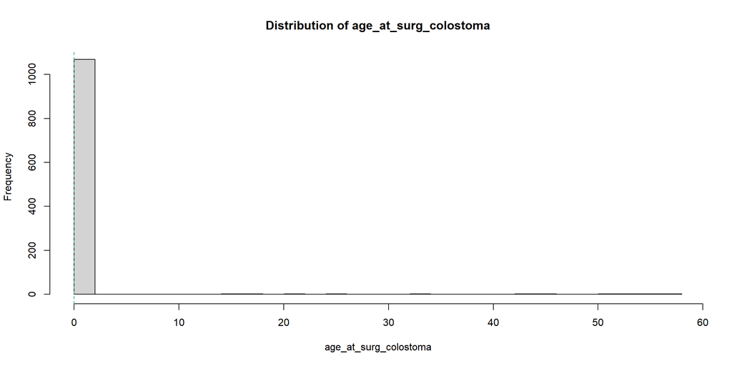

```r
# Visualize distribution
hist(combined_dataset_imputed$age_at_surg_colostoma, breaks = 30,
     main = "Distribution of age_at_surg_colostoma",
     xlab = "age_at_surg_colostoma")
abline(v = c(0, median(combined_dataset_imputed$age_at_surg_colostoma, na.rm = TRUE)),
       col = c( "#D95F02", "#1B9E77"), lty = 2)
```

```r
results <- categorize_and_test_predictor(
  data = combined_dataset_imputed,
  predictor_name = "age_at_surg_colostoma",
  outcomes = flare_outcomes
)

combined_dataset_imputed$age_at_surg_colostoma <- scale(combined_dataset_imputed$age_at_surg_colostoma)
##
##  ================================================================================
## PROCESSING: age_at_surg_colostoma
## ================================================================================
##
## Number of unique values: 13
## Number of valid observations: 1081
##
## Overall summary statistics:
##    Min. 1st Qu.  Median    Mean 3rd Qu.    Max.
##  0.0000  0.0000  0.0000  0.4308  0.0000 57.8865
##
## === CATEGORIZATION DISTRIBUTIONS ===
##
##  cat_q3 : SKIPPED (insufficient categories or data)
##
##  cat_q4 : SKIPPED (insufficient categories or data)
##
##  cat_median :
##
##  Low High
## 1069   12
##
##  cat_top25 :
##
## Normal   High
##   1069     12
##
## === CHI-SQUARE TEST RESULTS ===
## # A tibble: 8 × 8
##   predictor        categorization outcome chi_sq    df p_value p_formatted     n
##   <chr>            <chr>          <chr>    <dbl> <int>   <dbl> <chr>       <int>
## 1 age_at_surg_col… cat_median     flare_…     NA    NA   0.761 0.7612       1081
## 2 age_at_surg_col… cat_top25      flare_…     NA    NA   0.761 0.7612       1081
## 3 age_at_surg_col… cat_median     flare_…      0     1   1.00  1.0000       1081
## 4 age_at_surg_col… cat_top25      flare_…      0     1   1.00  1.0000       1081
## 5 age_at_surg_col… cat_median     flare_…     NA    NA   1     1.0000       1081
## 6 age_at_surg_col… cat_top25      flare_…     NA    NA   1     1.0000       1081
## 7 age_at_surg_col… cat_median     flare_…     NA    NA   0.688 0.6876       1081
## 8 age_at_surg_col… cat_top25      flare_…     NA    NA   0.688 0.6876       1081
##
## === BEST CATEGORIZATION FOR EACH OUTCOME ===
## # A tibble: 8 × 8
##   predictor        categorization outcome chi_sq    df p_value p_formatted     n
##   <chr>            <chr>          <chr>    <dbl> <int>   <dbl> <chr>       <int>
## 1 age_at_surg_col… cat_median     flare_…     NA    NA   0.761 0.7612       1081
## 2 age_at_surg_col… cat_top25      flare_…     NA    NA   0.761 0.7612       1081
## 3 age_at_surg_col… cat_median     flare_…      0     1   1.00  1.0000       1081
## 4 age_at_surg_col… cat_top25      flare_…      0     1   1.00  1.0000       1081
## 5 age_at_surg_col… cat_median     flare_…     NA    NA   1     1.0000       1081
## 6 age_at_surg_col… cat_top25      flare_…     NA    NA   1     1.0000       1081
## 7 age_at_surg_col… cat_median     flare_…     NA    NA   0.688 0.6876       1081
## 8 age_at_surg_col… cat_top25      flare_…     NA    NA   0.688 0.6876       1081
##
## === DETAILED CROSSTABS FOR BEST CATEGORIZATIONS ===
##
##  --------------------------------------------------------------------------------
## OUTCOME: flare_date1 | CATEGORIZATION: cat_median
## p-value: 0.7612 | N: 1081
## --------------------------------------------------------------------------------
##
## Frequency table:
##
##          0   1
##   Low  344 725
##   High   3   9
##
## Row proportions (% within each category):
##
##           0    1
##   Low  32.2 67.8
##   High 25.0 75.0
##
##  --------------------------------------------------------------------------------
## OUTCOME: flare_date1 | CATEGORIZATION: cat_top25
## p-value: 0.7612 | N: 1081
## --------------------------------------------------------------------------------
##
## Frequency table:
##
##            0   1
##   Normal 344 725
##   High     3   9
##
## Row proportions (% within each category):
##
##             0    1
##   Normal 32.2 67.8
##   High   25.0 75.0
##
##  --------------------------------------------------------------------------------
## OUTCOME: flare_date2 | CATEGORIZATION: cat_median
## p-value: 1.0000 | N: 1081
## --------------------------------------------------------------------------------
##
## Frequency table:
##
##          0   1
##   Low  583 486
##   High   7   5
##
## Row proportions (% within each category):
##
##           0    1
##   Low  54.5 45.5
##   High 58.3 41.7
##
##  --------------------------------------------------------------------------------
## OUTCOME: flare_date2 | CATEGORIZATION: cat_top25
## p-value: 1.0000 | N: 1081
## --------------------------------------------------------------------------------
##
## Frequency table:
##
##            0   1
##   Normal 583 486
##   High     7   5
##
## Row proportions (% within each category):
##
##             0    1
##   Normal 54.5 45.5
##   High   58.3 41.7
##
##  --------------------------------------------------------------------------------
## OUTCOME: flare_date3 | CATEGORIZATION: cat_median
## p-value: 1.0000 | N: 1081
## --------------------------------------------------------------------------------
##
## Frequency table:
##
##          0   1
##   Low  756 313
##   High   9   3
##
## Row proportions (% within each category):
##
##           0    1
##   Low  70.7 29.3
##   High 75.0 25.0
##
##  --------------------------------------------------------------------------------
## OUTCOME: flare_date3 | CATEGORIZATION: cat_top25
## p-value: 1.0000 | N: 1081
## --------------------------------------------------------------------------------
##
## Frequency table:
##
##            0   1
##   Normal 756 313
##   High     9   3
##
## Row proportions (% within each category):
##
##             0    1
##   Normal 70.7 29.3
##   High   75.0 25.0
##
##  --------------------------------------------------------------------------------
## OUTCOME: flare_date4 | CATEGORIZATION: cat_median
## p-value: 0.6876 | N: 1081
## --------------------------------------------------------------------------------
##
## Frequency table:
##
##          0   1
##   Low  915 154
##   High  10   2
##
## Row proportions (% within each category):
##
##           0    1
##   Low  85.6 14.4
##   High 83.3 16.7
##
##  --------------------------------------------------------------------------------
## OUTCOME: flare_date4 | CATEGORIZATION: cat_top25
## p-value: 0.6876 | N: 1081
## --------------------------------------------------------------------------------
##
## Frequency table:
##
##            0   1
##   Normal 915 154
##   High    10   2
##
## Row proportions (% within each category):
##
##             0    1
##   Normal 85.6 14.4
##   High   83.3 16.7
```

#### age_at_surg_proctocolectomy

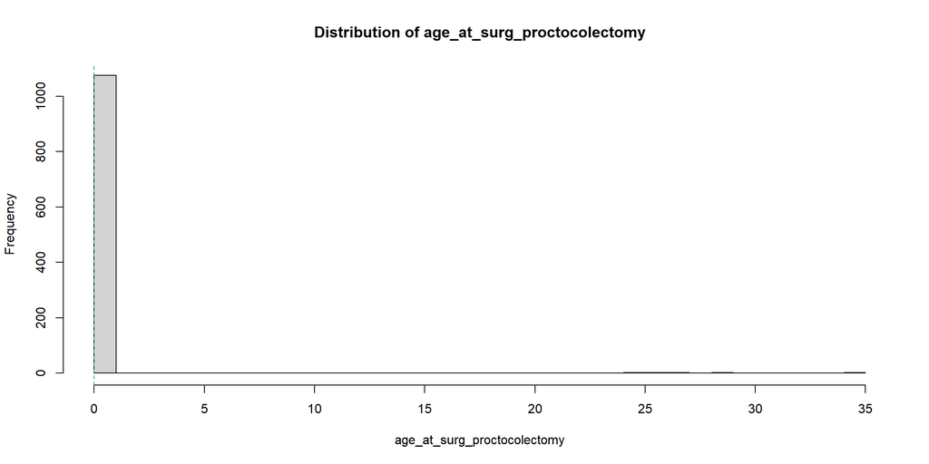

```r
# Visualize distribution
hist(combined_dataset_imputed$age_at_surg_proctocolectomy, breaks = 30,
     main = "Distribution of age_at_surg_proctocolectomy",
     xlab = "age_at_surg_proctocolectomy")
abline(v = c(0, median(combined_dataset_imputed$age_at_surg_proctocolectomy, na.rm = TRUE)),
       col = c( "#D95F02", "#1B9E77"), lty = 2)
```

```r
results <- categorize_and_test_predictor(
  data = combined_dataset_imputed,
  predictor_name = "age_at_surg_proctocolectomy",
  outcomes = flare_outcomes
)

combined_dataset_imputed$age_at_surg_proctocolectomy <- scale(combined_dataset_imputed$age_at_surg_proctocolectomy)
##
##  ================================================================================
## PROCESSING: age_at_surg_proctocolectomy
## ================================================================================
##
## Number of unique values: 6
## Number of valid observations: 1081
##
## Overall summary statistics:
##    Min. 1st Qu.  Median    Mean 3rd Qu.    Max.
##  0.0000  0.0000  0.0000  0.1296  0.0000 34.1028
##
## === CATEGORIZATION DISTRIBUTIONS ===
##
##  cat_q3 : SKIPPED (insufficient categories or data)
##
##  cat_q4 : SKIPPED (insufficient categories or data)
##
##  cat_median :
##
##  Low High
## 1076    5
##
##  cat_top25 :
##
## Normal   High
##   1076      5
##
## === CHI-SQUARE TEST RESULTS ===
## # A tibble: 8 × 8
##   predictor        categorization outcome chi_sq df    p_value p_formatted     n
##   <chr>            <chr>          <chr>   <lgl>  <lgl>   <dbl> <chr>       <int>
## 1 age_at_surg_pro… cat_median     flare_… NA     NA     1      1.0000       1081
## 2 age_at_surg_pro… cat_top25      flare_… NA     NA     1      1.0000       1081
## 3 age_at_surg_pro… cat_median     flare_… NA     NA     0.0672 0.0672       1081
## 4 age_at_surg_pro… cat_top25      flare_… NA     NA     0.0672 0.0672       1081
## 5 age_at_surg_pro… cat_median     flare_… NA     NA     0.329  0.3294       1081
## 6 age_at_surg_pro… cat_top25      flare_… NA     NA     0.329  0.3294       1081
## 7 age_at_surg_pro… cat_median     flare_… NA     NA     1      1.0000       1081
## 8 age_at_surg_pro… cat_top25      flare_… NA     NA     1      1.0000       1081
##
## === BEST CATEGORIZATION FOR EACH OUTCOME ===
## # A tibble: 8 × 8
##   predictor        categorization outcome chi_sq df    p_value p_formatted     n
##   <chr>            <chr>          <chr>   <lgl>  <lgl>   <dbl> <chr>       <int>
## 1 age_at_surg_pro… cat_median     flare_… NA     NA     1      1.0000       1081
## 2 age_at_surg_pro… cat_top25      flare_… NA     NA     1      1.0000       1081
## 3 age_at_surg_pro… cat_median     flare_… NA     NA     0.0672 0.0672       1081
## 4 age_at_surg_pro… cat_top25      flare_… NA     NA     0.0672 0.0672       1081
## 5 age_at_surg_pro… cat_median     flare_… NA     NA     0.329  0.3294       1081
## 6 age_at_surg_pro… cat_top25      flare_… NA     NA     0.329  0.3294       1081
## 7 age_at_surg_pro… cat_median     flare_… NA     NA     1      1.0000       1081
## 8 age_at_surg_pro… cat_top25      flare_… NA     NA     1      1.0000       1081
##
## === DETAILED CROSSTABS FOR BEST CATEGORIZATIONS ===
##
##  --------------------------------------------------------------------------------
## OUTCOME: flare_date1 | CATEGORIZATION: cat_median
## p-value: 1.0000 | N: 1081
## --------------------------------------------------------------------------------
##
## Frequency table:
##
##          0   1
##   Low  346 730
##   High   1   4
##
## Row proportions (% within each category):
##
##           0    1
##   Low  32.2 67.8
##   High 20.0 80.0
##
##  --------------------------------------------------------------------------------
## OUTCOME: flare_date1 | CATEGORIZATION: cat_top25
## p-value: 1.0000 | N: 1081
## --------------------------------------------------------------------------------
##
## Frequency table:
##
##            0   1
##   Normal 346 730
##   High     1   4
##
## Row proportions (% within each category):
##
##             0    1
##   Normal 32.2 67.8
##   High   20.0 80.0
##
##  --------------------------------------------------------------------------------
## OUTCOME: flare_date2 | CATEGORIZATION: cat_median
## p-value: 0.0672 | N: 1081
## --------------------------------------------------------------------------------
##
## Frequency table:
##
##          0   1
##   Low  585 491
##   High   5   0
##
## Row proportions (% within each category):
##
##            0     1
##   Low   54.4  45.6
##   High 100.0   0.0
##
##  --------------------------------------------------------------------------------
## OUTCOME: flare_date2 | CATEGORIZATION: cat_top25
## p-value: 0.0672 | N: 1081
## --------------------------------------------------------------------------------
##
## Frequency table:
##
##            0   1
##   Normal 585 491
##   High     5   0
##
## Row proportions (% within each category):
##
##              0     1
##   Normal  54.4  45.6
##   High   100.0   0.0
##
##  --------------------------------------------------------------------------------
## OUTCOME: flare_date3 | CATEGORIZATION: cat_median
## p-value: 0.3294 | N: 1081
## --------------------------------------------------------------------------------
##
## Frequency table:
##
##          0   1
##   Low  760 316
##   High   5   0
##
## Row proportions (% within each category):
##
##            0     1
##   Low   70.6  29.4
##   High 100.0   0.0
##
##  --------------------------------------------------------------------------------
## OUTCOME: flare_date3 | CATEGORIZATION: cat_top25
## p-value: 0.3294 | N: 1081
## --------------------------------------------------------------------------------
##
## Frequency table:
##
##            0   1
##   Normal 760 316
##   High     5   0
##
## Row proportions (% within each category):
##
##              0     1
##   Normal  70.6  29.4
##   High   100.0   0.0
##
##  --------------------------------------------------------------------------------
## OUTCOME: flare_date4 | CATEGORIZATION: cat_median
## p-value: 1.0000 | N: 1081
## --------------------------------------------------------------------------------
##
## Frequency table:
##
##          0   1
##   Low  920 156
##   High   5   0
##
## Row proportions (% within each category):
##
##            0     1
##   Low   85.5  14.5
##   High 100.0   0.0
##
##  --------------------------------------------------------------------------------
## OUTCOME: flare_date4 | CATEGORIZATION: cat_top25
## p-value: 1.0000 | N: 1081
## --------------------------------------------------------------------------------
##
## Frequency table:
##
##            0   1
##   Normal 920 156
##   High     5   0
##
## Row proportions (% within each category):
##
##              0     1
##   Normal  85.5  14.5
##   High   100.0   0.0
```

#### age_at_surg_stoma_reversal

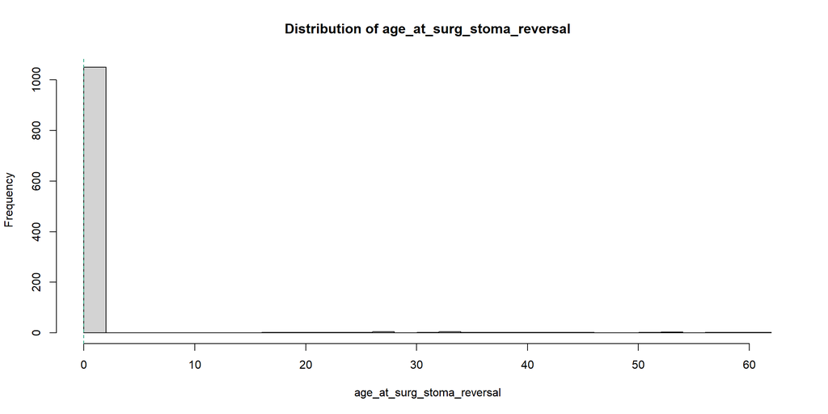

```r
# Visualize distribution
hist(combined_dataset_imputed$age_at_surg_stoma_reversal, breaks = 30,
     main = "Distribution of age_at_surg_stoma_reversal",
     xlab = "age_at_surg_stoma_reversal")
abline(v = c(0, median(combined_dataset_imputed$age_at_surg_stoma_reversal, na.rm = TRUE)),
       col = c( "#D95F02", "#1B9E77"), lty = 2)
```

```r
results <- categorize_and_test_predictor(
  data = combined_dataset_imputed,
  predictor_name = "age_at_surg_stoma_reversal",
  outcomes = flare_outcomes
)

# Add best categorizations to the main dataset
combined_dataset_imputed <- add_best_categorizations(data= combined_dataset_imputed,
                                                     predictor_name= "age_at_surg_stoma_reversal",
                                                     best_cat= "cat_median"  )

summarize_chisq_for_factor(combined_dataset_imputed, "age_at_surg_stoma_reversal")
##
##  ================================================================================
## PROCESSING: age_at_surg_stoma_reversal
## ================================================================================
##
## Number of unique values: 31
## Number of valid observations: 1081
##
## Overall summary statistics:
##    Min. 1st Qu.  Median    Mean 3rd Qu.    Max.
##   0.000   0.000   0.000   1.031   0.000  61.240
##
## === CATEGORIZATION DISTRIBUTIONS ===
##
##  cat_q3 : SKIPPED (insufficient categories or data)
##
##  cat_q4 : SKIPPED (insufficient categories or data)
##
##  cat_median :
##
##  Low High
## 1051   30
##
##  cat_top25 :
##
## Normal   High
##   1051     30
##
## === CHI-SQUARE TEST RESULTS ===
## # A tibble: 8 × 8
##   predictor        categorization outcome chi_sq    df p_value p_formatted     n
##   <chr>            <chr>          <chr>    <dbl> <int>   <dbl> <chr>       <int>
## 1 age_at_surg_sto… cat_median     flare_…  3.73      1  0.0534 0.0534       1081
## 2 age_at_surg_sto… cat_top25      flare_…  3.73      1  0.0534 0.0534       1081
## 3 age_at_surg_sto… cat_median     flare_…  0         1  1.00   1.0000       1081
## 4 age_at_surg_sto… cat_top25      flare_…  0         1  1.00   1.0000       1081
## 5 age_at_surg_sto… cat_median     flare_…  0.088     1  0.766  0.7662       1081
## 6 age_at_surg_sto… cat_top25      flare_…  0.088     1  0.766  0.7662       1081
## 7 age_at_surg_sto… cat_median     flare_… NA        NA  0.791  0.7907       1081
## 8 age_at_surg_sto… cat_top25      flare_… NA        NA  0.791  0.7907       1081
##
## === BEST CATEGORIZATION FOR EACH OUTCOME ===
## # A tibble: 8 × 8
##   predictor        categorization outcome chi_sq    df p_value p_formatted     n
##   <chr>            <chr>          <chr>    <dbl> <int>   <dbl> <chr>       <int>
## 1 age_at_surg_sto… cat_median     flare_…  3.73      1  0.0534 0.0534       1081
## 2 age_at_surg_sto… cat_top25      flare_…  3.73      1  0.0534 0.0534       1081
## 3 age_at_surg_sto… cat_median     flare_…  0         1  1.00   1.0000       1081
## 4 age_at_surg_sto… cat_top25      flare_…  0         1  1.00   1.0000       1081
## 5 age_at_surg_sto… cat_median     flare_…  0.088     1  0.766  0.7662       1081
## 6 age_at_surg_sto… cat_top25      flare_…  0.088     1  0.766  0.7662       1081
## 7 age_at_surg_sto… cat_median     flare_… NA        NA  0.791  0.7907       1081
## 8 age_at_surg_sto… cat_top25      flare_… NA        NA  0.791  0.7907       1081
##
## === DETAILED CROSSTABS FOR BEST CATEGORIZATIONS ===
##
##  --------------------------------------------------------------------------------
## OUTCOME: flare_date1 | CATEGORIZATION: cat_median
## p-value: 0.0534 | N: 1081
## --------------------------------------------------------------------------------
##
## Frequency table:
##
##          0   1
##   Low  332 719
##   High  15  15
##
## Row proportions (% within each category):
##
##           0    1
##   Low  31.6 68.4
##   High 50.0 50.0
##
##  --------------------------------------------------------------------------------
## OUTCOME: flare_date1 | CATEGORIZATION: cat_top25
## p-value: 0.0534 | N: 1081
## --------------------------------------------------------------------------------
##
## Frequency table:
##
##            0   1
##   Normal 332 719
##   High    15  15
##
## Row proportions (% within each category):
##
##             0    1
##   Normal 31.6 68.4
##   High   50.0 50.0
##
##  --------------------------------------------------------------------------------
## OUTCOME: flare_date2 | CATEGORIZATION: cat_median
## p-value: 1.0000 | N: 1081
## --------------------------------------------------------------------------------
##
## Frequency table:
##
##          0   1
##   Low  574 477
##   High  16  14
##
## Row proportions (% within each category):
##
##           0    1
##   Low  54.6 45.4
##   High 53.3 46.7
##
##  --------------------------------------------------------------------------------
## OUTCOME: flare_date2 | CATEGORIZATION: cat_top25
## p-value: 1.0000 | N: 1081
## --------------------------------------------------------------------------------
##
## Frequency table:
##
##            0   1
##   Normal 574 477
##   High    16  14
##
## Row proportions (% within each category):
##
##             0    1
##   Normal 54.6 45.4
##   High   53.3 46.7
##
##  --------------------------------------------------------------------------------
## OUTCOME: flare_date3 | CATEGORIZATION: cat_median
## p-value: 0.7662 | N: 1081
## --------------------------------------------------------------------------------
##
## Frequency table:
##
##          0   1
##   Low  745 306
##   High  20  10
##
## Row proportions (% within each category):
##
##           0    1
##   Low  70.9 29.1
##   High 66.7 33.3
##
##  --------------------------------------------------------------------------------
## OUTCOME: flare_date3 | CATEGORIZATION: cat_top25
## p-value: 0.7662 | N: 1081
## --------------------------------------------------------------------------------
##
## Frequency table:
##
##            0   1
##   Normal 745 306
##   High    20  10
##
## Row proportions (% within each category):
##
##             0    1
##   Normal 70.9 29.1
##   High   66.7 33.3
##
##  --------------------------------------------------------------------------------
## OUTCOME: flare_date4 | CATEGORIZATION: cat_median
## p-value: 0.7907 | N: 1081
## --------------------------------------------------------------------------------
##
## Frequency table:
##
##          0   1
##   Low  900 151
##   High  25   5
##
## Row proportions (% within each category):
##
##           0    1
##   Low  85.6 14.4
##   High 83.3 16.7
##
##  --------------------------------------------------------------------------------
## OUTCOME: flare_date4 | CATEGORIZATION: cat_top25
## p-value: 0.7907 | N: 1081
## --------------------------------------------------------------------------------
##
## Frequency table:
##
##            0   1
##   Normal 900 151
##   High    25   5
##
## Row proportions (% within each category):
##
##             0    1
##   Normal 85.6 14.4
##   High   83.3 16.7
## x
## High  Low
##   30 1051
##
## Chi-squared summary for predictor: age_at_surg_stoma_reversal
##         Flare ChiSq df p_value
## 1 flare_date1 3.731  1 0.05342
## 2 flare_date2 0.000  1 1.00000
## 3 flare_date3 0.088  1 0.76620
## 4 flare_date4 0.008  1 0.92830
```

#### age_at_surg_proctectomy

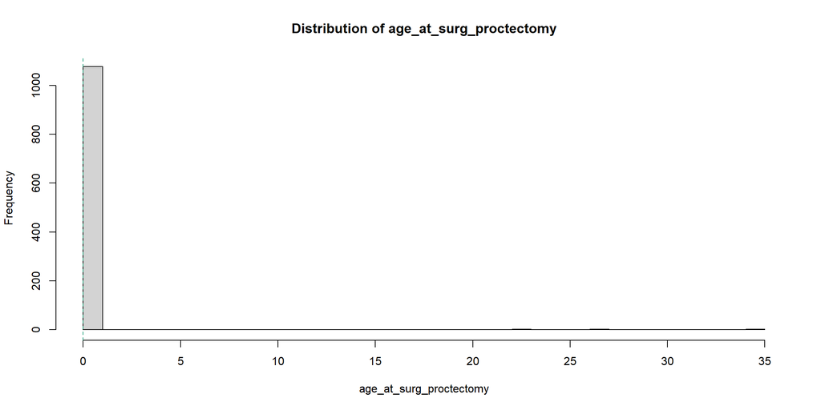

```r
# Visualize distribution
hist(combined_dataset_imputed$age_at_surg_proctectomy, breaks = 30,
     main = "Distribution of age_at_surg_proctectomy",
     xlab = "age_at_surg_proctectomy")
abline(v = c(0, median(combined_dataset_imputed$age_at_surg_proctectomy, na.rm = TRUE)),
       col = c( "#D95F02", "#1B9E77"), lty = 2)
```

```r
results <- categorize_and_test_predictor(
  data = combined_dataset_imputed,
  predictor_name = "age_at_surg_proctectomy",
  outcomes = flare_outcomes
)


combined_dataset_imputed$age_at_surg_proctectomy <- scale(combined_dataset_imputed$age_at_surg_proctectomy)
##
##  ================================================================================
## PROCESSING: age_at_surg_proctectomy
## ================================================================================
##
## Number of unique values: 4
## Number of valid observations: 1081
##
## Overall summary statistics:
##     Min.  1st Qu.   Median     Mean  3rd Qu.     Max.
##  0.00000  0.00000  0.00000  0.07693  0.00000 34.10278
##
## === CATEGORIZATION DISTRIBUTIONS ===
##
##  cat_q3 : SKIPPED (insufficient categories or data)
##
##  cat_q4 : SKIPPED (insufficient categories or data)
##
##  cat_median :
##
##  Low High
## 1078    3
##
##  cat_top25 :
##
## Normal   High
##   1078      3
##
## === CHI-SQUARE TEST RESULTS ===
## # A tibble: 8 × 8
##   predictor        categorization outcome chi_sq df    p_value p_formatted     n
##   <chr>            <chr>          <chr>   <lgl>  <lgl>   <dbl> <chr>       <int>
## 1 age_at_surg_pro… cat_median     flare_… NA     NA      0.555 0.5554       1081
## 2 age_at_surg_pro… cat_top25      flare_… NA     NA      0.555 0.5554       1081
## 3 age_at_surg_pro… cat_median     flare_… NA     NA      0.256 0.2556       1081
## 4 age_at_surg_pro… cat_top25      flare_… NA     NA      0.256 0.2556       1081
## 5 age_at_surg_pro… cat_median     flare_… NA     NA      0.560 0.5602       1081
## 6 age_at_surg_pro… cat_top25      flare_… NA     NA      0.560 0.5602       1081
## 7 age_at_surg_pro… cat_median     flare_… NA     NA      1     1.0000       1081
## 8 age_at_surg_pro… cat_top25      flare_… NA     NA      1     1.0000       1081
##
## === BEST CATEGORIZATION FOR EACH OUTCOME ===
## # A tibble: 8 × 8
##   predictor        categorization outcome chi_sq df    p_value p_formatted     n
##   <chr>            <chr>          <chr>   <lgl>  <lgl>   <dbl> <chr>       <int>
## 1 age_at_surg_pro… cat_median     flare_… NA     NA      0.555 0.5554       1081
## 2 age_at_surg_pro… cat_top25      flare_… NA     NA      0.555 0.5554       1081
## 3 age_at_surg_pro… cat_median     flare_… NA     NA      0.256 0.2556       1081
## 4 age_at_surg_pro… cat_top25      flare_… NA     NA      0.256 0.2556       1081
## 5 age_at_surg_pro… cat_median     flare_… NA     NA      0.560 0.5602       1081
## 6 age_at_surg_pro… cat_top25      flare_… NA     NA      0.560 0.5602       1081
## 7 age_at_surg_pro… cat_median     flare_… NA     NA      1     1.0000       1081
## 8 age_at_surg_pro… cat_top25      flare_… NA     NA      1     1.0000       1081
##
## === DETAILED CROSSTABS FOR BEST CATEGORIZATIONS ===
##
##  --------------------------------------------------------------------------------
## OUTCOME: flare_date1 | CATEGORIZATION: cat_median
## p-value: 0.5554 | N: 1081
## --------------------------------------------------------------------------------
##
## Frequency table:
##
##          0   1
##   Low  347 731
##   High   0   3
##
## Row proportions (% within each category):
##
##            0     1
##   Low   32.2  67.8
##   High   0.0 100.0
##
##  --------------------------------------------------------------------------------
## OUTCOME: flare_date1 | CATEGORIZATION: cat_top25
## p-value: 0.5554 | N: 1081
## --------------------------------------------------------------------------------
##
## Frequency table:
##
##            0   1
##   Normal 347 731
##   High     0   3
##
## Row proportions (% within each category):
##
##              0     1
##   Normal  32.2  67.8
##   High     0.0 100.0
##
##  --------------------------------------------------------------------------------
## OUTCOME: flare_date2 | CATEGORIZATION: cat_median
## p-value: 0.2556 | N: 1081
## --------------------------------------------------------------------------------
##
## Frequency table:
##
##          0   1
##   Low  587 491
##   High   3   0
##
## Row proportions (% within each category):
##
##            0     1
##   Low   54.5  45.5
##   High 100.0   0.0
##
##  --------------------------------------------------------------------------------
## OUTCOME: flare_date2 | CATEGORIZATION: cat_top25
## p-value: 0.2556 | N: 1081
## --------------------------------------------------------------------------------
##
## Frequency table:
##
##            0   1
##   Normal 587 491
##   High     3   0
##
## Row proportions (% within each category):
##
##              0     1
##   Normal  54.5  45.5
##   High   100.0   0.0
##
##  --------------------------------------------------------------------------------
## OUTCOME: flare_date3 | CATEGORIZATION: cat_median
## p-value: 0.5602 | N: 1081
## --------------------------------------------------------------------------------
##
## Frequency table:
##
##          0   1
##   Low  762 316
##   High   3   0
##
## Row proportions (% within each category):
##
##            0     1
##   Low   70.7  29.3
##   High 100.0   0.0
##
##  --------------------------------------------------------------------------------
## OUTCOME: flare_date3 | CATEGORIZATION: cat_top25
## p-value: 0.5602 | N: 1081
## --------------------------------------------------------------------------------
##
## Frequency table:
##
##            0   1
##   Normal 762 316
##   High     3   0
##
## Row proportions (% within each category):
##
##              0     1
##   Normal  70.7  29.3
##   High   100.0   0.0
##
##  --------------------------------------------------------------------------------
## OUTCOME: flare_date4 | CATEGORIZATION: cat_median
## p-value: 1.0000 | N: 1081
## --------------------------------------------------------------------------------
##
## Frequency table:
##
##          0   1
##   Low  922 156
##   High   3   0
##
## Row proportions (% within each category):
##
##            0     1
##   Low   85.5  14.5
##   High 100.0   0.0
##
##  --------------------------------------------------------------------------------
## OUTCOME: flare_date4 | CATEGORIZATION: cat_top25
## p-value: 1.0000 | N: 1081
## --------------------------------------------------------------------------------
##
## Frequency table:
##
##            0   1
##   Normal 922 156
##   High     3   0
##
## Row proportions (% within each category):
##
##              0     1
##   Normal  85.5  14.5
##   High   100.0   0.0
```

#### age_at_surg_stenoplast

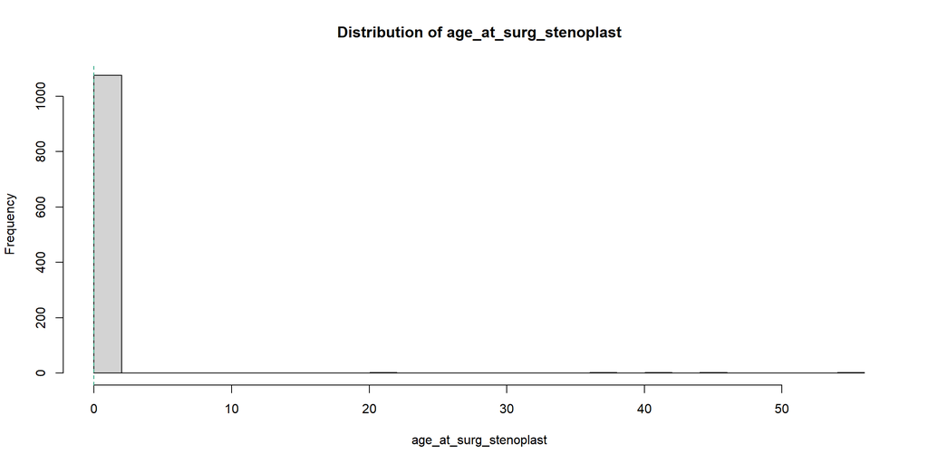

```r
# Visualize distribution
hist(combined_dataset_imputed$age_at_surg_stenoplast, breaks = 30,
     main = "Distribution of age_at_surg_stenoplast",
     xlab = "age_at_surg_stenoplast")
abline(v = c(0, median(combined_dataset_imputed$age_at_surg_stenoplast, na.rm = TRUE)),
       col = c( "#D95F02", "#1B9E77"), lty = 2)
```

```r
combined_dataset_imputed$age_at_surg_stenoplast <- scale(combined_dataset_imputed$age_at_surg_stenoplast)
```

#### max_age_at_surg

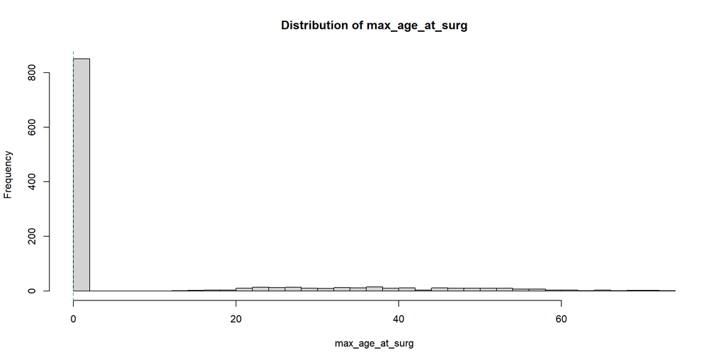

```r
# Visualize distribution
hist(combined_dataset_imputed$max_age_at_surg, breaks = 30,
     main = "Distribution of max_age_at_surg",
     xlab = "max_age_at_surg")
abline(v = c(0, median(combined_dataset_imputed$max_age_at_surg, na.rm = TRUE)),
       col = c( "#D95F02", "#1B9E77"), lty = 2)
```

```r
results <- categorize_and_test_predictor(
  data = combined_dataset_imputed,
  predictor_name = "max_age_at_surg",
  outcomes = flare_outcomes
)

# Add best categorizations to the main dataset
combined_dataset_imputed <- add_best_categorizations(data= combined_dataset_imputed,
                                                     predictor_name= "max_age_at_surg",
                                                     best_cat= "cat_top25"  )

summarize_chisq_for_factor(combined_dataset_imputed, "max_age_at_surg")
##
##  ================================================================================
## PROCESSING: max_age_at_surg
## ================================================================================
##
## Number of unique values: 231
## Number of valid observations: 1081
##
## Overall summary statistics:
##    Min. 1st Qu.  Median    Mean 3rd Qu.    Max.
##   0.000   0.000   0.000   8.215   0.000  73.985
##
## === CATEGORIZATION DISTRIBUTIONS ===
##
##  cat_q3 : SKIPPED (insufficient categories or data)
##
##  cat_q4 : SKIPPED (insufficient categories or data)
##
##  cat_median :
##
##  Low High
##  851  230
##
##  cat_top25 :
##
## Normal   High
##    851    230
##
## === CHI-SQUARE TEST RESULTS ===
## # A tibble: 8 × 8
##   predictor       categorization outcome  chi_sq    df p_value p_formatted     n
##   <chr>           <chr>          <chr>     <dbl> <int>   <dbl> <chr>       <int>
## 1 max_age_at_surg cat_median     flare_d…  2.37      1   0.124 0.1237       1081
## 2 max_age_at_surg cat_top25      flare_d…  2.37      1   0.124 0.1237       1081
## 3 max_age_at_surg cat_median     flare_d…  0.351     1   0.554 0.5537       1081
## 4 max_age_at_surg cat_top25      flare_d…  0.351     1   0.554 0.5537       1081
## 5 max_age_at_surg cat_median     flare_d…  0.878     1   0.349 0.3488       1081
## 6 max_age_at_surg cat_top25      flare_d…  0.878     1   0.349 0.3488       1081
## 7 max_age_at_surg cat_median     flare_d…  1.26      1   0.262 0.2616       1081
## 8 max_age_at_surg cat_top25      flare_d…  1.26      1   0.262 0.2616       1081
##
## === BEST CATEGORIZATION FOR EACH OUTCOME ===
## # A tibble: 8 × 8
##   predictor       categorization outcome  chi_sq    df p_value p_formatted     n
##   <chr>           <chr>          <chr>     <dbl> <int>   <dbl> <chr>       <int>
## 1 max_age_at_surg cat_median     flare_d…  2.37      1   0.124 0.1237       1081
## 2 max_age_at_surg cat_top25      flare_d…  2.37      1   0.124 0.1237       1081
## 3 max_age_at_surg cat_median     flare_d…  0.351     1   0.554 0.5537       1081
## 4 max_age_at_surg cat_top25      flare_d…  0.351     1   0.554 0.5537       1081
## 5 max_age_at_surg cat_median     flare_d…  0.878     1   0.349 0.3488       1081
## 6 max_age_at_surg cat_top25      flare_d…  0.878     1   0.349 0.3488       1081
## 7 max_age_at_surg cat_median     flare_d…  1.26      1   0.262 0.2616       1081
## 8 max_age_at_surg cat_top25      flare_d…  1.26      1   0.262 0.2616       1081
##
## === DETAILED CROSSTABS FOR BEST CATEGORIZATIONS ===
##
##  --------------------------------------------------------------------------------
## OUTCOME: flare_date1 | CATEGORIZATION: cat_median
## p-value: 0.1237 | N: 1081
## --------------------------------------------------------------------------------
##
## Frequency table:
##
##          0   1
##   Low  263 588
##   High  84 146
##
## Row proportions (% within each category):
##
##           0    1
##   Low  30.9 69.1
##   High 36.5 63.5
##
##  --------------------------------------------------------------------------------
## OUTCOME: flare_date1 | CATEGORIZATION: cat_top25
## p-value: 0.1237 | N: 1081
## --------------------------------------------------------------------------------
##
## Frequency table:
##
##            0   1
##   Normal 263 588
##   High    84 146
##
## Row proportions (% within each category):
##
##             0    1
##   Normal 30.9 69.1
##   High   36.5 63.5
##
##  --------------------------------------------------------------------------------
## OUTCOME: flare_date2 | CATEGORIZATION: cat_median
## p-value: 0.5537 | N: 1081
## --------------------------------------------------------------------------------
##
## Frequency table:
##
##          0   1
##   Low  460 391
##   High 130 100
##
## Row proportions (% within each category):
##
##           0    1
##   Low  54.1 45.9
##   High 56.5 43.5
##
##  --------------------------------------------------------------------------------
## OUTCOME: flare_date2 | CATEGORIZATION: cat_top25
## p-value: 0.5537 | N: 1081
## --------------------------------------------------------------------------------
##
## Frequency table:
##
##            0   1
##   Normal 460 391
##   High   130 100
##
## Row proportions (% within each category):
##
##             0    1
##   Normal 54.1 45.9
##   High   56.5 43.5
##
##  --------------------------------------------------------------------------------
## OUTCOME: flare_date3 | CATEGORIZATION: cat_median
## p-value: 0.3488 | N: 1081
## --------------------------------------------------------------------------------
##
## Frequency table:
##
##          0   1
##   Low  596 255
##   High 169  61
##
## Row proportions (% within each category):
##
##           0    1
##   Low  70.0 30.0
##   High 73.5 26.5
##
##  --------------------------------------------------------------------------------
## OUTCOME: flare_date3 | CATEGORIZATION: cat_top25
## p-value: 0.3488 | N: 1081
## --------------------------------------------------------------------------------
##
## Frequency table:
##
##            0   1
##   Normal 596 255
##   High   169  61
##
## Row proportions (% within each category):
##
##             0    1
##   Normal 70.0 30.0
##   High   73.5 26.5
##
##  --------------------------------------------------------------------------------
## OUTCOME: flare_date4 | CATEGORIZATION: cat_median
## p-value: 0.2616 | N: 1081
## --------------------------------------------------------------------------------
##
## Frequency table:
##
##          0   1
##   Low  734 117
##   High 191  39
##
## Row proportions (% within each category):
##
##           0    1
##   Low  86.3 13.7
##   High 83.0 17.0
##
##  --------------------------------------------------------------------------------
## OUTCOME: flare_date4 | CATEGORIZATION: cat_top25
## p-value: 0.2616 | N: 1081
## --------------------------------------------------------------------------------
##
## Frequency table:
##
##            0   1
##   Normal 734 117
##   High   191  39
##
## Row proportions (% within each category):
##
##             0    1
##   Normal 86.3 13.7
##   High   83.0 17.0
## x
##   High Normal
##    230    851
##
## Chi-squared summary for predictor: max_age_at_surg
##         Flare ChiSq df p_value
## 1 flare_date1 2.370  1  0.1237
## 2 flare_date2 0.351  1  0.5537
## 3 flare_date3 0.878  1  0.3488
## 4 flare_date4 1.260  1  0.2616
```

#### Anxious_mean

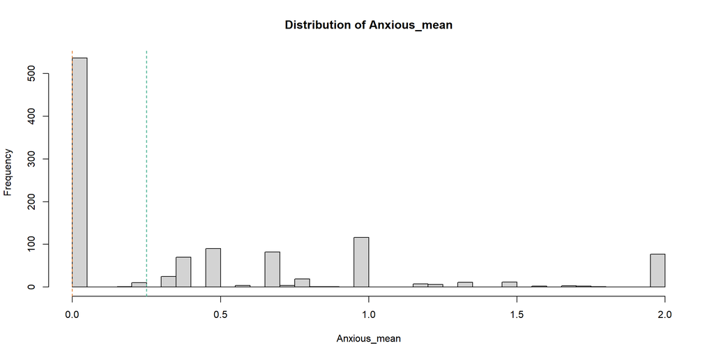

```r
# Visualize distribution
hist(combined_dataset_imputed$Anxious_mean, breaks = 30,
     main = "Distribution of Anxious_mean",
     xlab = "Anxious_mean")
abline(v = c(0, median(combined_dataset_imputed$Anxious_mean, na.rm = TRUE)),
       col = c( "#D95F02", "#1B9E77"), lty = 2)
```

```r
results <- categorize_and_test_predictor(
  data = combined_dataset_imputed,
  predictor_name = "Anxious_mean",
  outcomes = flare_outcomes
)
# Add best categorizations to the main dataset
combined_dataset_imputed <- add_best_categorizations(data= combined_dataset_imputed,
                                                     predictor_name= "Anxious_mean",
                                                     best_cat= "cat_q4"  )
summarize_chisq_for_factor(combined_dataset_imputed, "Anxious_mean")
##
##  ================================================================================
## PROCESSING: Anxious_mean
## ================================================================================
##
## Number of unique values: 23
## Number of valid observations: 1081
##
## Overall summary statistics:
##    Min. 1st Qu.  Median    Mean 3rd Qu.    Max.
##  0.0000  0.0000  0.2500  0.4560  0.6667  2.0000
##
## === CATEGORIZATION DISTRIBUTIONS ===
##
##  cat_q3 :
##
## [0,0.5] (0.5,2]
##     733     348
##
##  cat_q4 :
##
##     [0,0.25] (0.25,0.667]    (0.667,2]
##          548          271          262
##
##  cat_median :
##
##  Low High
##  548  533
##
##  cat_top25 :
##
## Normal   High
##    819    262
##
## === CHI-SQUARE TEST RESULTS ===
## # A tibble: 16 × 8
##    predictor    categorization outcome   chi_sq    df  p_value p_formatted     n
##    <chr>        <chr>          <chr>      <dbl> <int>    <dbl> <chr>       <int>
##  1 Anxious_mean cat_top25      flare_da…  41.5      1 1.15e-10 < 0.001      1081
##  2 Anxious_mean cat_q4         flare_da…  44.1      2 2.69e-10 < 0.001      1081
##  3 Anxious_mean cat_q3         flare_da…  26.3      1 2.89e- 7 < 0.001      1081
##  4 Anxious_mean cat_median     flare_da…   7.07     1 7.83e- 3 0.0078       1081
##  5 Anxious_mean cat_q4         flare_da…  54.5      2 1.45e-12 < 0.001      1081
##  6 Anxious_mean cat_top25      flare_da…  15.4      1 8.83e- 5 < 0.001      1081
##  7 Anxious_mean cat_median     flare_da…   7.50     1 6.19e- 3 0.0062       1081
##  8 Anxious_mean cat_q3         flare_da…   1.56     1 2.11e- 1 0.2111       1081
##  9 Anxious_mean cat_q4         flare_da…  78.2      2 1.06e-17 < 0.001      1081
## 10 Anxious_mean cat_median     flare_da…  16.9      1 4.04e- 5 < 0.001      1081
## 11 Anxious_mean cat_top25      flare_da…  15.3      1 9.04e- 5 < 0.001      1081
## 12 Anxious_mean cat_q3         flare_da…   2.14     1 1.43e- 1 0.1432       1081
## 13 Anxious_mean cat_q4         flare_da…  95.5      2 1.82e-21 < 0.001      1081
## 14 Anxious_mean cat_median     flare_da…  35.8      1 2.14e- 9 < 0.001      1081
## 15 Anxious_mean cat_top25      flare_da…   7.23     1 7.18e- 3 0.0072       1081
## 16 Anxious_mean cat_q3         flare_da…   6.46     1 1.10e- 2 0.0110       1081
##
## === BEST CATEGORIZATION FOR EACH OUTCOME ===
## # A tibble: 4 × 8
##   predictor    categorization outcome    chi_sq    df  p_value p_formatted     n
##   <chr>        <chr>          <chr>       <dbl> <int>    <dbl> <chr>       <int>
## 1 Anxious_mean cat_top25      flare_dat…   41.5     1 1.15e-10 < 0.001      1081
## 2 Anxious_mean cat_q4         flare_dat…   54.5     2 1.45e-12 < 0.001      1081
## 3 Anxious_mean cat_q4         flare_dat…   78.2     2 1.06e-17 < 0.001      1081
## 4 Anxious_mean cat_q4         flare_dat…   95.5     2 1.82e-21 < 0.001      1081
##
## === DETAILED CROSSTABS FOR BEST CATEGORIZATIONS ===
##
##  --------------------------------------------------------------------------------
## OUTCOME: flare_date1 | CATEGORIZATION: cat_top25
## p-value: < 0.001 | N: 1081
## --------------------------------------------------------------------------------
##
## Frequency table:
##
##            0   1
##   Normal 220 599
##   High   127 135
##
## Row proportions (% within each category):
##
##             0    1
##   Normal 26.9 73.1
##   High   48.5 51.5
##
##  --------------------------------------------------------------------------------
## OUTCOME: flare_date2 | CATEGORIZATION: cat_q4
## p-value: < 0.001 | N: 1081
## --------------------------------------------------------------------------------
##
## Frequency table:
##
##                  0   1
##   [0,0.25]     322 226
##   (0.25,0.667]  97 174
##   (0.667,2]    171  91
##
## Row proportions (% within each category):
##
##                   0    1
##   [0,0.25]     58.8 41.2
##   (0.25,0.667] 35.8 64.2
##   (0.667,2]    65.3 34.7
##
##  --------------------------------------------------------------------------------
## OUTCOME: flare_date3 | CATEGORIZATION: cat_q4
## p-value: < 0.001 | N: 1081
## --------------------------------------------------------------------------------
##
## Frequency table:
##
##                  0   1
##   [0,0.25]     419 129
##   (0.25,0.667] 135 136
##   (0.667,2]    211  51
##
## Row proportions (% within each category):
##
##                   0    1
##   [0,0.25]     76.5 23.5
##   (0.25,0.667] 49.8 50.2
##   (0.667,2]    80.5 19.5
##
##  --------------------------------------------------------------------------------
## OUTCOME: flare_date4 | CATEGORIZATION: cat_q4
## p-value: < 0.001 | N: 1081
## --------------------------------------------------------------------------------
##
## Frequency table:
##
##                  0   1
##   [0,0.25]     504  44
##   (0.25,0.667] 183  88
##   (0.667,2]    238  24
##
## Row proportions (% within each category):
##
##                   0    1
##   [0,0.25]     92.0  8.0
##   (0.25,0.667] 67.5 32.5
##   (0.667,2]    90.8  9.2
## x
## (0.25,0.667]    (0.667,2]     [0,0.25]
##          271          262          548
##
## Chi-squared summary for predictor: Anxious_mean
##         Flare  ChiSq df   p_value
## 1 flare_date1 44.073  2 2.690e-10
## 2 flare_date2 54.514  2 1.454e-12
## 3 flare_date3 78.172  2 1.060e-17
## 4 flare_date4 95.513  2 1.818e-21
```

#### Stress_mean

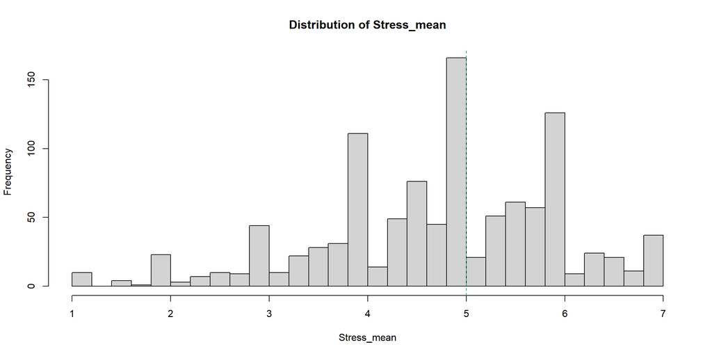

```r
# Visualize distribution
hist(combined_dataset_imputed$Stress_mean, breaks = 30,
     main = "Distribution of Stress_mean",
     xlab = "Stress_mean")
abline(v = c(0, median(combined_dataset_imputed$Stress_mean, na.rm = TRUE)),
       col = c( "#D95F02", "#1B9E77"), lty = 2)
```

```r
results <- categorize_and_test_predictor(
  data = combined_dataset_imputed,
  predictor_name = "Stress_mean",
  outcomes = flare_outcomes
)

# Add best categorizations to the main dataset
combined_dataset_imputed <- add_best_categorizations(data= combined_dataset_imputed,
                                                     predictor_name= "Stress_mean",
                                                     best_cat= "cat_q4"  )
summarize_chisq_for_factor(combined_dataset_imputed, "Stress_mean")
##
##  ================================================================================
## PROCESSING: Stress_mean
## ================================================================================
##
## Number of unique values: 169
## Number of valid observations: 1081
##
## Overall summary statistics:
##    Min. 1st Qu.  Median    Mean 3rd Qu.    Max.
##   1.000   4.000   5.000   4.768   5.667   7.000
##
## === CATEGORIZATION DISTRIBUTIONS ===
##
##  cat_q3 :
##
##    Low Medium   High
##    368    356    357
##
##  cat_q4 :
##
##  Q1  Q2  Q3  Q4
## 313 350 164 254
##
##  cat_median :
##
##  Low High
##  663  418
##
##  cat_top25 :
##
## Normal   High
##    827    254
##
## === CHI-SQUARE TEST RESULTS ===
## # A tibble: 16 × 8
##    predictor   categorization outcome    chi_sq    df  p_value p_formatted     n
##    <chr>       <chr>          <chr>       <dbl> <int>    <dbl> <chr>       <int>
##  1 Stress_mean cat_q4         flare_dat…  46.2      3 5.16e-10 < 0.001      1081
##  2 Stress_mean cat_q3         flare_dat…  35.6      2 1.90e- 8 < 0.001      1081
##  3 Stress_mean cat_median     flare_dat…  22.8      1 1.82e- 6 < 0.001      1081
##  4 Stress_mean cat_top25      flare_dat…  13.6      1 2.22e- 4 < 0.001      1081
##  5 Stress_mean cat_q4         flare_dat…  56.5      3 3.31e-12 < 0.001      1081
##  6 Stress_mean cat_median     flare_dat…  38.8      1 4.76e-10 < 0.001      1081
##  7 Stress_mean cat_q3         flare_dat…  37.7      2 6.51e- 9 < 0.001      1081
##  8 Stress_mean cat_top25      flare_dat…   6.09     1 1.36e- 2 0.0136       1081
##  9 Stress_mean cat_q4         flare_dat…  45.9      3 6.08e-10 < 0.001      1081
## 10 Stress_mean cat_median     flare_dat…  33.8      1 6.26e- 9 < 0.001      1081
## 11 Stress_mean cat_q3         flare_dat…  28.1      2 7.96e- 7 < 0.001      1081
## 12 Stress_mean cat_top25      flare_dat…   8.29     1 4.00e- 3 0.0040       1081
## 13 Stress_mean cat_q4         flare_dat…  31.8      3 5.80e- 7 < 0.001      1081
## 14 Stress_mean cat_median     flare_dat…  18.5      1 1.73e- 5 < 0.001      1081
## 15 Stress_mean cat_q3         flare_dat…  19.4      2 6.13e- 5 < 0.001      1081
## 16 Stress_mean cat_top25      flare_dat…   2.56     1 1.09e- 1 0.1093       1081
##
## === BEST CATEGORIZATION FOR EACH OUTCOME ===
## # A tibble: 4 × 8
##   predictor   categorization outcome     chi_sq    df  p_value p_formatted     n
##   <chr>       <chr>          <chr>        <dbl> <int>    <dbl> <chr>       <int>
## 1 Stress_mean cat_q4         flare_date1   46.2     3 5.16e-10 < 0.001      1081
## 2 Stress_mean cat_q4         flare_date2   56.5     3 3.31e-12 < 0.001      1081
## 3 Stress_mean cat_q4         flare_date3   45.9     3 6.08e-10 < 0.001      1081
## 4 Stress_mean cat_q4         flare_date4   31.8     3 5.80e- 7 < 0.001      1081
##
## === DETAILED CROSSTABS FOR BEST CATEGORIZATIONS ===
##
##  --------------------------------------------------------------------------------
## OUTCOME: flare_date1 | CATEGORIZATION: cat_q4
## p-value: < 0.001 | N: 1081
## --------------------------------------------------------------------------------
##
## Frequency table:
##
##        0   1
##   Q1 146 167
##   Q2 103 247
##   Q3  41 123
##   Q4  57 197
##
## Row proportions (% within each category):
##
##         0    1
##   Q1 46.6 53.4
##   Q2 29.4 70.6
##   Q3 25.0 75.0
##   Q4 22.4 77.6
##
##  --------------------------------------------------------------------------------
## OUTCOME: flare_date2 | CATEGORIZATION: cat_q4
## p-value: < 0.001 | N: 1081
## --------------------------------------------------------------------------------
##
## Frequency table:
##
##        0   1
##   Q1 215  98
##   Q2 197 153
##   Q3  57 107
##   Q4 121 133
##
## Row proportions (% within each category):
##
##         0    1
##   Q1 68.7 31.3
##   Q2 56.3 43.7
##   Q3 34.8 65.2
##   Q4 47.6 52.4
##
##  --------------------------------------------------------------------------------
## OUTCOME: flare_date3 | CATEGORIZATION: cat_q4
## p-value: < 0.001 | N: 1081
## --------------------------------------------------------------------------------
##
## Frequency table:
##
##        0   1
##   Q1 259  54
##   Q2 253  97
##   Q3  92  72
##   Q4 161  93
##
## Row proportions (% within each category):
##
##         0    1
##   Q1 82.7 17.3
##   Q2 72.3 27.7
##   Q3 56.1 43.9
##   Q4 63.4 36.6
##
##  --------------------------------------------------------------------------------
## OUTCOME: flare_date4 | CATEGORIZATION: cat_q4
## p-value: < 0.001 | N: 1081
## --------------------------------------------------------------------------------
##
## Frequency table:
##
##        0   1
##   Q1 293  20
##   Q2 299  51
##   Q3 124  40
##   Q4 209  45
##
## Row proportions (% within each category):
##
##         0    1
##   Q1 93.6  6.4
##   Q2 85.4 14.6
##   Q3 75.6 24.4
##   Q4 82.3 17.7
## x
##  Q1  Q2  Q3  Q4
## 313 350 164 254
##
## Chi-squared summary for predictor: Stress_mean
##         Flare  ChiSq df   p_value
## 1 flare_date1 46.194  3 5.158e-10
## 2 flare_date2 56.484  3 3.311e-12
## 3 flare_date3 45.857  3 6.084e-10
## 4 flare_date4 31.789  3 5.799e-07
```

#### Fatigue_mean

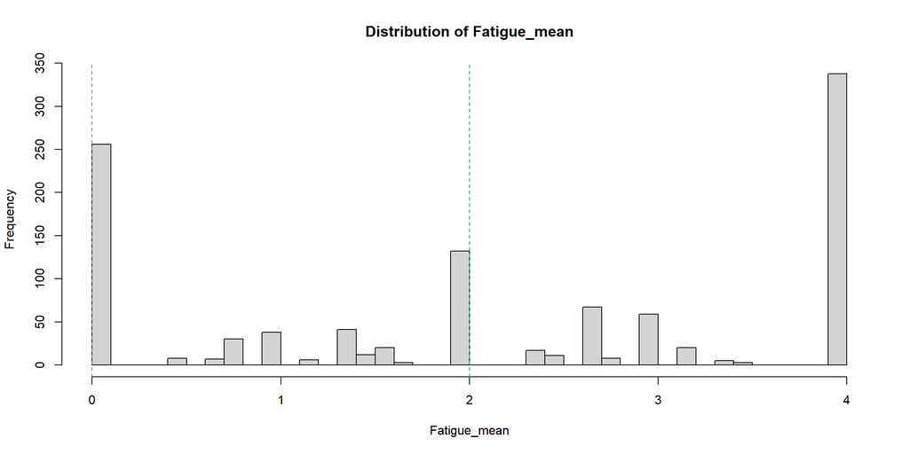

```r
# Visualize distribution
hist(combined_dataset_imputed$Fatigue_mean, breaks = 30,
     main = "Distribution of Fatigue_mean",
     xlab = "Fatigue_mean")
abline(v = c(0, median(combined_dataset_imputed$Fatigue_mean, na.rm = TRUE)),
       col = c( "#D95F02", "#1B9E77"), lty = 2)
```

```r
results <- categorize_and_test_predictor(
  data = combined_dataset_imputed,
  predictor_name = "Fatigue_mean",
  outcomes = flare_outcomes
)

# Add best categorizations to the main dataset
combined_dataset_imputed <- add_best_categorizations(data= combined_dataset_imputed,
                                                     predictor_name= "Fatigue_mean",
                                                     best_cat= "cat_q3"  )

summarize_chisq_for_factor(combined_dataset_imputed, "Fatigue_mean")
##
##  ================================================================================
## PROCESSING: Fatigue_mean
## ================================================================================
##
## Number of unique values: 22
## Number of valid observations: 1081
##
## Overall summary statistics:
##    Min. 1st Qu.  Median    Mean 3rd Qu.    Max.
##  0.0000  0.6667  2.0000  2.1655  4.0000  4.0000
##
## === CATEGORIZATION DISTRIBUTIONS ===
##
##  cat_q3 :
##
##    Low Medium   High
##    386    349    346
##
##  cat_q4 :
##
## [0,0.667] (0.667,2]     (2,4]
##       271       282       528
##
##  cat_median :
##
##  Low High
##  553  528
##
##  cat_top25 : SKIPPED (insufficient categories or data)
##
## === CHI-SQUARE TEST RESULTS ===
## # A tibble: 12 × 8
##    predictor    categorization outcome   chi_sq    df  p_value p_formatted     n
##    <chr>        <chr>          <chr>      <dbl> <int>    <dbl> <chr>       <int>
##  1 Fatigue_mean cat_q3         flare_da…  66.3      2 4.01e-15 < 0.001      1081
##  2 Fatigue_mean cat_median     flare_da…  42.5      1 7.12e-11 < 0.001      1081
##  3 Fatigue_mean cat_q4         flare_da…  44.3      2 2.46e-10 < 0.001      1081
##  4 Fatigue_mean cat_q3         flare_da…  71.7      2 2.75e-16 < 0.001      1081
##  5 Fatigue_mean cat_q4         flare_da…  45.9      2 1.06e-10 < 0.001      1081
##  6 Fatigue_mean cat_median     flare_da…  23.1      1 1.54e- 6 < 0.001      1081
##  7 Fatigue_mean cat_q3         flare_da…  56.9      2 4.43e-13 < 0.001      1081
##  8 Fatigue_mean cat_q4         flare_da…  26.5      2 1.74e- 6 < 0.001      1081
##  9 Fatigue_mean cat_median     flare_da…   5.7      1 1.70e- 2 0.0170       1081
## 10 Fatigue_mean cat_q4         flare_da…  54.0      2 1.92e-12 < 0.001      1081
## 11 Fatigue_mean cat_q3         flare_da…  38.2      2 4.99e- 9 < 0.001      1081
## 12 Fatigue_mean cat_median     flare_da…   7.39     1 6.57e- 3 0.0066       1081
##
## === BEST CATEGORIZATION FOR EACH OUTCOME ===
## # A tibble: 4 × 8
##   predictor    categorization outcome    chi_sq    df  p_value p_formatted     n
##   <chr>        <chr>          <chr>       <dbl> <int>    <dbl> <chr>       <int>
## 1 Fatigue_mean cat_q3         flare_dat…   66.3     2 4.01e-15 < 0.001      1081
## 2 Fatigue_mean cat_q3         flare_dat…   71.7     2 2.75e-16 < 0.001      1081
## 3 Fatigue_mean cat_q3         flare_dat…   56.9     2 4.43e-13 < 0.001      1081
## 4 Fatigue_mean cat_q4         flare_dat…   54.0     2 1.92e-12 < 0.001      1081
##
## === DETAILED CROSSTABS FOR BEST CATEGORIZATIONS ===
##
##  --------------------------------------------------------------------------------
## OUTCOME: flare_date1 | CATEGORIZATION: cat_q3
## p-value: < 0.001 | N: 1081
## --------------------------------------------------------------------------------
##
## Frequency table:
##
##            0   1
##   Low     80 306
##   Medium 100 249
##   High   167 179
##
## Row proportions (% within each category):
##
##             0    1
##   Low    20.7 79.3
##   Medium 28.7 71.3
##   High   48.3 51.7
##
##  --------------------------------------------------------------------------------
## OUTCOME: flare_date2 | CATEGORIZATION: cat_q3
## p-value: < 0.001 | N: 1081
## --------------------------------------------------------------------------------
##
## Frequency table:
##
##            0   1
##   Low    184 202
##   Medium 153 196
##   High   253  93
##
## Row proportions (% within each category):
##
##             0    1
##   Low    47.7 52.3
##   Medium 43.8 56.2
##   High   73.1 26.9
##
##  --------------------------------------------------------------------------------
## OUTCOME: flare_date3 | CATEGORIZATION: cat_q3
## p-value: < 0.001 | N: 1081
## --------------------------------------------------------------------------------
##
## Frequency table:
##
##            0   1
##   Low    252 134
##   Medium 216 133
##   High   297  49
##
## Row proportions (% within each category):
##
##             0    1
##   Low    65.3 34.7
##   Medium 61.9 38.1
##   High   85.8 14.2
##
##  --------------------------------------------------------------------------------
## OUTCOME: flare_date4 | CATEGORIZATION: cat_q4
## p-value: < 0.001 | N: 1081
## --------------------------------------------------------------------------------
##
## Frequency table:
##
##               0   1
##   [0,0.667] 252  19
##   (0.667,2] 205  77
##   (2,4]     468  60
##
## Row proportions (% within each category):
##
##                0    1
##   [0,0.667] 93.0  7.0
##   (0.667,2] 72.7 27.3
##   (2,4]     88.6 11.4
## x
##   High    Low Medium
##    346    386    349
##
## Chi-squared summary for predictor: Fatigue_mean
##         Flare  ChiSq df   p_value
## 1 flare_date1 66.301  2 4.007e-15
## 2 flare_date2 71.660  2 2.749e-16
## 3 flare_date3 56.889  2 4.434e-13
## 4 flare_date4 38.231  2 4.993e-09
```

#### Pain_mean

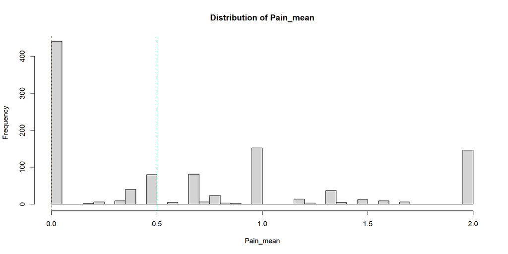

```r
# Visualize distribution
hist(combined_dataset_imputed$Pain_mean, breaks = 30,
     main = "Distribution of Pain_mean",
     xlab = "Pain_mean")
abline(v = c(0, median(combined_dataset_imputed$Pain_mean, na.rm = TRUE)),
       col = c( "#D95F02", "#1B9E77"), lty = 2)
```

```r
results <- categorize_and_test_predictor(
  data = combined_dataset_imputed,
  predictor_name = "Pain_mean",
  outcomes = flare_outcomes
)

# Add best categorizations to the main dataset
combined_dataset_imputed <- add_best_categorizations(data= combined_dataset_imputed,
                                                     predictor_name= "Pain_mean",
                                                     best_cat= "cat_q3"  )
summarize_chisq_for_factor(combined_dataset_imputed, "Pain_mean")
##
##  ================================================================================
## PROCESSING: Pain_mean
## ================================================================================
##
## Number of unique values: 22
## Number of valid observations: 1081
##
## Overall summary statistics:
##    Min. 1st Qu.  Median    Mean 3rd Qu.    Max.
##  0.0000  0.0000  0.5000  0.6538  1.0000  2.0000
##
## === CATEGORIZATION DISTRIBUTIONS ===
##
##  cat_q3 :
##
## [0,1] (1,2]
##   850   231
##
##  cat_q4 :
##
## [0,0.5] (0.5,1]   (1,2]
##     578     272     231
##
##  cat_median :
##
##  Low High
##  578  503
##
##  cat_top25 :
##
## Normal   High
##    850    231
##
## === CHI-SQUARE TEST RESULTS ===
## # A tibble: 16 × 8
##    predictor categorization outcome     chi_sq    df  p_value p_formatted     n
##    <chr>     <chr>          <chr>        <dbl> <int>    <dbl> <chr>       <int>
##  1 Pain_mean cat_q4         flare_date1  46.3      2 8.98e-11 < 0.001      1081
##  2 Pain_mean cat_q3         flare_date1  37.1      1 1.10e- 9 < 0.001      1081
##  3 Pain_mean cat_top25      flare_date1  37.1      1 1.10e- 9 < 0.001      1081
##  4 Pain_mean cat_median     flare_date1  33.1      1 8.83e- 9 < 0.001      1081
##  5 Pain_mean cat_q3         flare_date2  40.0      1 2.58e-10 < 0.001      1081
##  6 Pain_mean cat_top25      flare_date2  40.0      1 2.58e-10 < 0.001      1081
##  7 Pain_mean cat_q4         flare_date2  41.0      2 1.26e- 9 < 0.001      1081
##  8 Pain_mean cat_median     flare_date2  10.9      1 9.58e- 4 < 0.001      1081
##  9 Pain_mean cat_q3         flare_date3  15.4      1 8.87e- 5 < 0.001      1081
## 10 Pain_mean cat_top25      flare_date3  15.4      1 8.87e- 5 < 0.001      1081
## 11 Pain_mean cat_q4         flare_date3  16.5      2 2.61e- 4 < 0.001      1081
## 12 Pain_mean cat_median     flare_date3   7.58     1 5.90e- 3 0.0059       1081
## 13 Pain_mean cat_q3         flare_date4  12.6      1 3.78e- 4 < 0.001      1081
## 14 Pain_mean cat_top25      flare_date4  12.6      1 3.78e- 4 < 0.001      1081
## 15 Pain_mean cat_q4         flare_date4  13.4      2 1.21e- 3 0.0012       1081
## 16 Pain_mean cat_median     flare_date4   4.4      1 3.59e- 2 0.0359       1081
##
## === BEST CATEGORIZATION FOR EACH OUTCOME ===
## # A tibble: 7 × 8
##   predictor categorization outcome     chi_sq    df  p_value p_formatted     n
##   <chr>     <chr>          <chr>        <dbl> <int>    <dbl> <chr>       <int>
## 1 Pain_mean cat_q4         flare_date1   46.3     2 8.98e-11 < 0.001      1081
## 2 Pain_mean cat_q3         flare_date2   40.0     1 2.58e-10 < 0.001      1081
## 3 Pain_mean cat_top25      flare_date2   40.0     1 2.58e-10 < 0.001      1081
## 4 Pain_mean cat_q3         flare_date3   15.4     1 8.87e- 5 < 0.001      1081
## 5 Pain_mean cat_top25      flare_date3   15.4     1 8.87e- 5 < 0.001      1081
## 6 Pain_mean cat_q3         flare_date4   12.6     1 3.78e- 4 < 0.001      1081
## 7 Pain_mean cat_top25      flare_date4   12.6     1 3.78e- 4 < 0.001      1081
##
## === DETAILED CROSSTABS FOR BEST CATEGORIZATIONS ===
##
##  --------------------------------------------------------------------------------
## OUTCOME: flare_date1 | CATEGORIZATION: cat_q4
## p-value: < 0.001 | N: 1081
## --------------------------------------------------------------------------------
##
## Frequency table:
##
##             0   1
##   [0,0.5] 141 437
##   (0.5,1]  93 179
##   (1,2]   113 118
##
## Row proportions (% within each category):
##
##              0    1
##   [0,0.5] 24.4 75.6
##   (0.5,1] 34.2 65.8
##   (1,2]   48.9 51.1
##
##  --------------------------------------------------------------------------------
## OUTCOME: flare_date2 | CATEGORIZATION: cat_q3
## p-value: < 0.001 | N: 1081
## --------------------------------------------------------------------------------
##
## Frequency table:
##
##           0   1
##   [0,1] 421 429
##   (1,2] 169  62
##
## Row proportions (% within each category):
##
##            0    1
##   [0,1] 49.5 50.5
##   (1,2] 73.2 26.8
##
##  --------------------------------------------------------------------------------
## OUTCOME: flare_date2 | CATEGORIZATION: cat_top25
## p-value: < 0.001 | N: 1081
## --------------------------------------------------------------------------------
##
## Frequency table:
##
##            0   1
##   Normal 421 429
##   High   169  62
##
## Row proportions (% within each category):
##
##             0    1
##   Normal 49.5 50.5
##   High   73.2 26.8
##
##  --------------------------------------------------------------------------------
## OUTCOME: flare_date3 | CATEGORIZATION: cat_q3
## p-value: < 0.001 | N: 1081
## --------------------------------------------------------------------------------
##
## Frequency table:
##
##           0   1
##   [0,1] 577 273
##   (1,2] 188  43
##
## Row proportions (% within each category):
##
##            0    1
##   [0,1] 67.9 32.1
##   (1,2] 81.4 18.6
##
##  --------------------------------------------------------------------------------
## OUTCOME: flare_date3 | CATEGORIZATION: cat_top25
## p-value: < 0.001 | N: 1081
## --------------------------------------------------------------------------------
##
## Frequency table:
##
##            0   1
##   Normal 577 273
##   High   188  43
##
## Row proportions (% within each category):
##
##             0    1
##   Normal 67.9 32.1
##   High   81.4 18.6
##
##  --------------------------------------------------------------------------------
## OUTCOME: flare_date4 | CATEGORIZATION: cat_q3
## p-value: < 0.001 | N: 1081
## --------------------------------------------------------------------------------
##
## Frequency table:
##
##           0   1
##   [0,1] 710 140
##   (1,2] 215  16
##
## Row proportions (% within each category):
##
##            0    1
##   [0,1] 83.5 16.5
##   (1,2] 93.1  6.9
##
##  --------------------------------------------------------------------------------
## OUTCOME: flare_date4 | CATEGORIZATION: cat_top25
## p-value: < 0.001 | N: 1081
## --------------------------------------------------------------------------------
##
## Frequency table:
##
##            0   1
##   Normal 710 140
##   High   215  16
##
## Row proportions (% within each category):
##
##             0    1
##   Normal 83.5 16.5
##   High   93.1  6.9
## x
## (1,2] [0,1]
##   231   850
##
## Chi-squared summary for predictor: Pain_mean
##         Flare  ChiSq df   p_value
## 1 flare_date1 37.148  1 1.095e-09
## 2 flare_date2 39.967  1 2.583e-10
## 3 flare_date3 15.363  1 8.871e-05
## 4 flare_date4 12.637  1 3.782e-04
```

#### total_medication

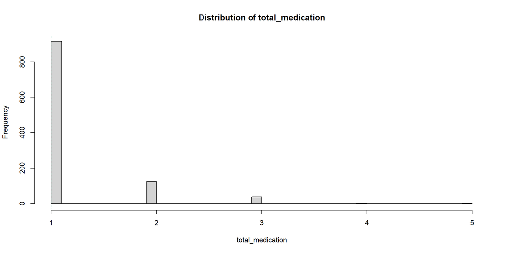

```r
# Visualize distribution
hist(combined_dataset_imputed$total_medication, breaks = 30,
     main = "Distribution of total_medication",
     xlab = "total_medication")
abline(v = c(0, median(combined_dataset_imputed$total_medication, na.rm = TRUE)),
       col = c( "#D95F02", "#1B9E77"), lty = 2)
```

```r
results <- categorize_and_test_predictor(
  data = combined_dataset_imputed,
  predictor_name = "total_medication",
  outcomes = flare_outcomes
)

# Add best categorizations to the main dataset
combined_dataset_imputed <- add_best_categorizations(data= combined_dataset_imputed,
                                                     predictor_name= "total_medication",
                                                     best_cat= "cat_top25"  )

summarize_chisq_for_factor(combined_dataset_imputed, "total_medication")
##
##  ================================================================================
## PROCESSING: total_medication
## ================================================================================
##
## Number of unique values: 5
## Number of valid observations: 1081
##
## Overall summary statistics:
##    Min. 1st Qu.  Median    Mean 3rd Qu.    Max.
##   1.000   1.000   1.000   1.191   1.000   5.000
##
## === CATEGORIZATION DISTRIBUTIONS ===
##
##  cat_q3 : SKIPPED (insufficient categories or data)
##
##  cat_q4 : SKIPPED (insufficient categories or data)
##
##  cat_median :
##
##  Low High
##  918  163
##
##  cat_top25 :
##
## Normal   High
##    918    163
##
## === CHI-SQUARE TEST RESULTS ===
## # A tibble: 8 × 8
##   predictor        categorization outcome chi_sq    df p_value p_formatted     n
##   <chr>            <chr>          <chr>    <dbl> <int>   <dbl> <chr>       <int>
## 1 total_medication cat_median     flare_…  3.88      1  0.0488 0.0488       1081
## 2 total_medication cat_top25      flare_…  3.88      1  0.0488 0.0488       1081
## 3 total_medication cat_median     flare_…  4.53      1  0.0334 0.0334       1081
## 4 total_medication cat_top25      flare_…  4.53      1  0.0334 0.0334       1081
## 5 total_medication cat_median     flare_…  0.001     1  0.978  0.9779       1081
## 6 total_medication cat_top25      flare_…  0.001     1  0.978  0.9779       1081
## 7 total_medication cat_median     flare_…  0.535     1  0.465  0.4647       1081
## 8 total_medication cat_top25      flare_…  0.535     1  0.465  0.4647       1081
##
## === BEST CATEGORIZATION FOR EACH OUTCOME ===
## # A tibble: 8 × 8
##   predictor        categorization outcome chi_sq    df p_value p_formatted     n
##   <chr>            <chr>          <chr>    <dbl> <int>   <dbl> <chr>       <int>
## 1 total_medication cat_median     flare_…  3.88      1  0.0488 0.0488       1081
## 2 total_medication cat_top25      flare_…  3.88      1  0.0488 0.0488       1081
## 3 total_medication cat_median     flare_…  4.53      1  0.0334 0.0334       1081
## 4 total_medication cat_top25      flare_…  4.53      1  0.0334 0.0334       1081
## 5 total_medication cat_median     flare_…  0.001     1  0.978  0.9779       1081
## 6 total_medication cat_top25      flare_…  0.001     1  0.978  0.9779       1081
## 7 total_medication cat_median     flare_…  0.535     1  0.465  0.4647       1081
## 8 total_medication cat_top25      flare_…  0.535     1  0.465  0.4647       1081
##
## === DETAILED CROSSTABS FOR BEST CATEGORIZATIONS ===
##
##  --------------------------------------------------------------------------------
## OUTCOME: flare_date1 | CATEGORIZATION: cat_median
## p-value: 0.0488 | N: 1081
## --------------------------------------------------------------------------------
##
## Frequency table:
##
##          0   1
##   Low  306 612
##   High  41 122
##
## Row proportions (% within each category):
##
##           0    1
##   Low  33.3 66.7
##   High 25.2 74.8
##
##  --------------------------------------------------------------------------------
## OUTCOME: flare_date1 | CATEGORIZATION: cat_top25
## p-value: 0.0488 | N: 1081
## --------------------------------------------------------------------------------
##
## Frequency table:
##
##            0   1
##   Normal 306 612
##   High    41 122
##
## Row proportions (% within each category):
##
##             0    1
##   Normal 33.3 66.7
##   High   25.2 74.8
##
##  --------------------------------------------------------------------------------
## OUTCOME: flare_date2 | CATEGORIZATION: cat_median
## p-value: 0.0334 | N: 1081
## --------------------------------------------------------------------------------
##
## Frequency table:
##
##          0   1
##   Low  514 404
##   High  76  87
##
## Row proportions (% within each category):
##
##           0    1
##   Low  56.0 44.0
##   High 46.6 53.4
##
##  --------------------------------------------------------------------------------
## OUTCOME: flare_date2 | CATEGORIZATION: cat_top25
## p-value: 0.0334 | N: 1081
## --------------------------------------------------------------------------------
##
## Frequency table:
##
##            0   1
##   Normal 514 404
##   High    76  87
##
## Row proportions (% within each category):
##
##             0    1
##   Normal 56.0 44.0
##   High   46.6 53.4
##
##  --------------------------------------------------------------------------------
## OUTCOME: flare_date3 | CATEGORIZATION: cat_median
## p-value: 0.9779 | N: 1081
## --------------------------------------------------------------------------------
##
## Frequency table:
##
##          0   1
##   Low  649 269
##   High 116  47
##
## Row proportions (% within each category):
##
##           0    1
##   Low  70.7 29.3
##   High 71.2 28.8
##
##  --------------------------------------------------------------------------------
## OUTCOME: flare_date3 | CATEGORIZATION: cat_top25
## p-value: 0.9779 | N: 1081
## --------------------------------------------------------------------------------
##
## Frequency table:
##
##            0   1
##   Normal 649 269
##   High   116  47
##
## Row proportions (% within each category):
##
##             0    1
##   Normal 70.7 29.3
##   High   71.2 28.8
##
##  --------------------------------------------------------------------------------
## OUTCOME: flare_date4 | CATEGORIZATION: cat_median
## p-value: 0.4647 | N: 1081
## --------------------------------------------------------------------------------
##
## Frequency table:
##
##          0   1
##   Low  782 136
##   High 143  20
##
## Row proportions (% within each category):
##
##           0    1
##   Low  85.2 14.8
##   High 87.7 12.3
##
##  --------------------------------------------------------------------------------
## OUTCOME: flare_date4 | CATEGORIZATION: cat_top25
## p-value: 0.4647 | N: 1081
## --------------------------------------------------------------------------------
##
## Frequency table:
##
##            0   1
##   Normal 782 136
##   High   143  20
##
## Row proportions (% within each category):
##
##             0    1
##   Normal 85.2 14.8
##   High   87.7 12.3
## x
##   High Normal
##    163    918
##
## Chi-squared summary for predictor: total_medication
##         Flare ChiSq df p_value
## 1 flare_date1 3.882  1 0.04879
## 2 flare_date2 4.527  1 0.03336
## 3 flare_date3 0.001  1 0.97790
## 4 flare_date4 0.535  1 0.46470
```

#### total_medication_period

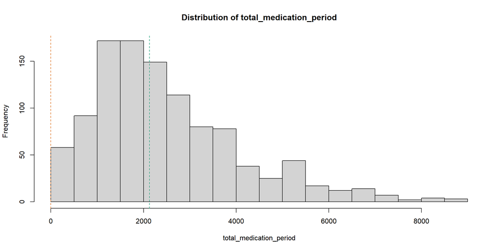

```r
# Visualize distribution
hist(combined_dataset_imputed$total_medication_period, breaks = 30,
     main = "Distribution of total_medication_period",
     xlab = "total_medication_period")
abline(v = c(0, median(combined_dataset_imputed$total_medication_period, na.rm = TRUE)),
       col = c( "#D95F02", "#1B9E77"), lty = 2)
```

```r
results <- categorize_and_test_predictor(
  data = combined_dataset_imputed,
  predictor_name = "total_medication_period",
  outcomes = flare_outcomes
)

# Add best categorizations to the main dataset
combined_dataset_imputed <- add_best_categorizations(data= combined_dataset_imputed,
                                                     predictor_name= "total_medication_period",
                                                     best_cat= "cat_top25"  )

summarize_chisq_for_factor(combined_dataset_imputed, "total_medication_period")
##
##  ================================================================================
## PROCESSING: total_medication_period
## ================================================================================
##
## Number of unique values: 978
## Number of valid observations: 1081
##
## Overall summary statistics:
##    Min. 1st Qu.  Median    Mean 3rd Qu.    Max.
##       0    1341    2129    2504    3320    8983
##
## === CATEGORIZATION DISTRIBUTIONS ===
##
##  cat_q3 :
##
##    Low Medium   High
##    361    360    360
##
##  cat_q4 :
##
##  Q1  Q2  Q3  Q4
## 271 270 270 270
##
##  cat_median :
##
##  Low High
##  541  540
##
##  cat_top25 :
##
## Normal   High
##    811    270
##
## === CHI-SQUARE TEST RESULTS ===
## # A tibble: 16 × 8
##    predictor       categorization outcome chi_sq    df p_value p_formatted     n
##    <chr>           <chr>          <chr>    <dbl> <int>   <dbl> <chr>       <int>
##  1 total_medicati… cat_top25      flare_…  2.66      1   0.103 0.1031       1081
##  2 total_medicati… cat_q3         flare_…  3.69      2   0.158 0.1577       1081
##  3 total_medicati… cat_q4         flare_…  4.12      3   0.248 0.2484       1081
##  4 total_medicati… cat_median     flare_…  0         1   0.983 0.9833       1081
##  5 total_medicati… cat_top25      flare_…  2.05      1   0.153 0.1526       1081
##  6 total_medicati… cat_median     flare_…  0.902     1   0.342 0.3423       1081
##  7 total_medicati… cat_q4         flare_…  2.60      3   0.458 0.4582       1081
##  8 total_medicati… cat_q3         flare_…  0.985     2   0.611 0.6112       1081
##  9 total_medicati… cat_median     flare_…  0.238     1   0.626 0.6258       1081
## 10 total_medicati… cat_top25      flare_…  0.158     1   0.691 0.6910       1081
## 11 total_medicati… cat_q4         flare_…  0.467     3   0.926 0.9262       1081
## 12 total_medicati… cat_q3         flare_…  0.135     2   0.935 0.9346       1081
## 13 total_medicati… cat_top25      flare_…  0.243     1   0.622 0.6223       1081
## 14 total_medicati… cat_q3         flare_…  0.592     2   0.744 0.7439       1081
## 15 total_medicati… cat_q4         flare_…  0.917     3   0.821 0.8213       1081
## 16 total_medicati… cat_median     flare_…  0.01      1   0.921 0.9211       1081
##
## === BEST CATEGORIZATION FOR EACH OUTCOME ===
## # A tibble: 4 × 8
##   predictor        categorization outcome chi_sq    df p_value p_formatted     n
##   <chr>            <chr>          <chr>    <dbl> <int>   <dbl> <chr>       <int>
## 1 total_medicatio… cat_top25      flare_…  2.66      1   0.103 0.1031       1081
## 2 total_medicatio… cat_top25      flare_…  2.05      1   0.153 0.1526       1081
## 3 total_medicatio… cat_median     flare_…  0.238     1   0.626 0.6258       1081
## 4 total_medicatio… cat_top25      flare_…  0.243     1   0.622 0.6223       1081
##
## === DETAILED CROSSTABS FOR BEST CATEGORIZATIONS ===
##
##  --------------------------------------------------------------------------------
## OUTCOME: flare_date1 | CATEGORIZATION: cat_top25
## p-value: 0.1031 | N: 1081
## --------------------------------------------------------------------------------
##
## Frequency table:
##
##            0   1
##   Normal 249 562
##   High    98 172
##
## Row proportions (% within each category):
##
##             0    1
##   Normal 30.7 69.3
##   High   36.3 63.7
##
##  --------------------------------------------------------------------------------
## OUTCOME: flare_date2 | CATEGORIZATION: cat_top25
## p-value: 0.1526 | N: 1081
## --------------------------------------------------------------------------------
##
## Frequency table:
##
##            0   1
##   Normal 432 379
##   High   158 112
##
## Row proportions (% within each category):
##
##             0    1
##   Normal 53.3 46.7
##   High   58.5 41.5
##
##  --------------------------------------------------------------------------------
## OUTCOME: flare_date3 | CATEGORIZATION: cat_median
## p-value: 0.6258 | N: 1081
## --------------------------------------------------------------------------------
##
## Frequency table:
##
##          0   1
##   Low  387 154
##   High 378 162
##
## Row proportions (% within each category):
##
##           0    1
##   Low  71.5 28.5
##   High 70.0 30.0
##
##  --------------------------------------------------------------------------------
## OUTCOME: flare_date4 | CATEGORIZATION: cat_top25
## p-value: 0.6223 | N: 1081
## --------------------------------------------------------------------------------
##
## Frequency table:
##
##            0   1
##   Normal 691 120
##   High   234  36
##
## Row proportions (% within each category):
##
##             0    1
##   Normal 85.2 14.8
##   High   86.7 13.3
## x
##   High Normal
##    270    811
##
## Chi-squared summary for predictor: total_medication_period
##         Flare ChiSq df p_value
## 1 flare_date1 2.657  1  0.1031
## 2 flare_date2 2.046  1  0.1526
## 3 flare_date3 0.158  1  0.6910
## 4 flare_date4 0.243  1  0.6223
```

#### period_Adalimumab

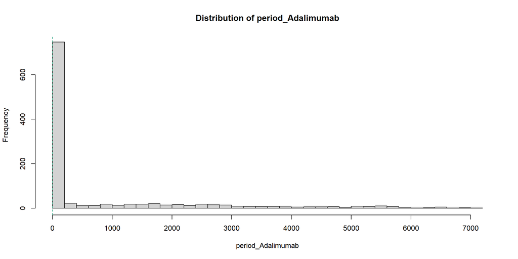

```r
# Visualize distribution
hist(combined_dataset_imputed$period_Adalimumab, breaks = 30,
     main = "Distribution of period_Adalimumab",
     xlab = "period_Adalimumab")
abline(v = c(0, median(combined_dataset_imputed$period_Adalimumab, na.rm = TRUE)),
       col = c( "#D95F02", "#1B9E77"), lty = 2)
```

```r
results <- categorize_and_test_predictor(
  data = combined_dataset_imputed,
  predictor_name = "period_Adalimumab",
  outcomes = flare_outcomes
)
# Add best categorizations to the main dataset
combined_dataset_imputed <- add_best_categorizations(data= combined_dataset_imputed,
                                                     predictor_name= "period_Adalimumab",
                                                     best_cat= "cat_top25"  )
summarize_chisq_for_factor(combined_dataset_imputed, "period_Adalimumab")
##
##  ================================================================================
## PROCESSING: period_Adalimumab
## ================================================================================
##
## Number of unique values: 334
## Number of valid observations: 1081
##
## Overall summary statistics:
##    Min. 1st Qu.  Median    Mean 3rd Qu.    Max.
##     0.0     0.0     0.0   812.7  1004.0  7198.0
##
## === CATEGORIZATION DISTRIBUTIONS ===
##
##  cat_q3 : SKIPPED (insufficient categories or data)
##
##  cat_q4 :
##
##       [0,1e+03] (1e+03,7.2e+03]
##             811             270
##
##  cat_median :
##
##  Low High
##  737  344
##
##  cat_top25 :
##
## Normal   High
##    811    270
##
## === CHI-SQUARE TEST RESULTS ===
## # A tibble: 12 × 8
##    predictor       categorization outcome chi_sq    df p_value p_formatted     n
##    <chr>           <chr>          <chr>    <dbl> <int>   <dbl> <chr>       <int>
##  1 period_Adalimu… cat_q4         flare_…  3.17      1  0.0750 0.0750       1081
##  2 period_Adalimu… cat_top25      flare_…  3.17      1  0.0750 0.0750       1081
##  3 period_Adalimu… cat_median     flare_…  0.325     1  0.569  0.5686       1081
##  4 period_Adalimu… cat_q4         flare_…  1.01      1  0.314  0.3139       1081
##  5 period_Adalimu… cat_top25      flare_…  1.01      1  0.314  0.3139       1081
##  6 period_Adalimu… cat_median     flare_…  0.13      1  0.719  0.7186       1081
##  7 period_Adalimu… cat_median     flare_…  0.087     1  0.768  0.7676       1081
##  8 period_Adalimu… cat_q4         flare_…  0         1  1      1.0000       1081
##  9 period_Adalimu… cat_top25      flare_…  0         1  1      1.0000       1081
## 10 period_Adalimu… cat_median     flare_…  0.025     1  0.873  0.8735       1081
## 11 period_Adalimu… cat_q4         flare_…  0         1  1.00   1.0000       1081
## 12 period_Adalimu… cat_top25      flare_…  0         1  1.00   1.0000       1081
##
## === BEST CATEGORIZATION FOR EACH OUTCOME ===
## # A tibble: 6 × 8
##   predictor        categorization outcome chi_sq    df p_value p_formatted     n
##   <chr>            <chr>          <chr>    <dbl> <int>   <dbl> <chr>       <int>
## 1 period_Adalimum… cat_q4         flare_…  3.17      1  0.0750 0.0750       1081
## 2 period_Adalimum… cat_top25      flare_…  3.17      1  0.0750 0.0750       1081
## 3 period_Adalimum… cat_q4         flare_…  1.01      1  0.314  0.3139       1081
## 4 period_Adalimum… cat_top25      flare_…  1.01      1  0.314  0.3139       1081
## 5 period_Adalimum… cat_median     flare_…  0.087     1  0.768  0.7676       1081
## 6 period_Adalimum… cat_median     flare_…  0.025     1  0.873  0.8735       1081
##
## === DETAILED CROSSTABS FOR BEST CATEGORIZATIONS ===
##
##  --------------------------------------------------------------------------------
## OUTCOME: flare_date1 | CATEGORIZATION: cat_q4
## p-value: 0.0750 | N: 1081
## --------------------------------------------------------------------------------
##
## Frequency table:
##
##                     0   1
##   [0,1e+03]       248 563
##   (1e+03,7.2e+03]  99 171
##
## Row proportions (% within each category):
##
##                      0    1
##   [0,1e+03]       30.6 69.4
##   (1e+03,7.2e+03] 36.7 63.3
##
##  --------------------------------------------------------------------------------
## OUTCOME: flare_date1 | CATEGORIZATION: cat_top25
## p-value: 0.0750 | N: 1081
## --------------------------------------------------------------------------------
##
## Frequency table:
##
##            0   1
##   Normal 248 563
##   High    99 171
##
## Row proportions (% within each category):
##
##             0    1
##   Normal 30.6 69.4
##   High   36.7 63.3
##
##  --------------------------------------------------------------------------------
## OUTCOME: flare_date2 | CATEGORIZATION: cat_q4
## p-value: 0.3139 | N: 1081
## --------------------------------------------------------------------------------
##
## Frequency table:
##
##                     0   1
##   [0,1e+03]       435 376
##   (1e+03,7.2e+03] 155 115
##
## Row proportions (% within each category):
##
##                      0    1
##   [0,1e+03]       53.6 46.4
##   (1e+03,7.2e+03] 57.4 42.6
##
##  --------------------------------------------------------------------------------
## OUTCOME: flare_date2 | CATEGORIZATION: cat_top25
## p-value: 0.3139 | N: 1081
## --------------------------------------------------------------------------------
##
## Frequency table:
##
##            0   1
##   Normal 435 376
##   High   155 115
##
## Row proportions (% within each category):
##
##             0    1
##   Normal 53.6 46.4
##   High   57.4 42.6
##
##  --------------------------------------------------------------------------------
## OUTCOME: flare_date3 | CATEGORIZATION: cat_median
## p-value: 0.7676 | N: 1081
## --------------------------------------------------------------------------------
##
## Frequency table:
##
##          0   1
##   Low  519 218
##   High 246  98
##
## Row proportions (% within each category):
##
##           0    1
##   Low  70.4 29.6
##   High 71.5 28.5
##
##  --------------------------------------------------------------------------------
## OUTCOME: flare_date4 | CATEGORIZATION: cat_median
## p-value: 0.8735 | N: 1081
## --------------------------------------------------------------------------------
##
## Frequency table:
##
##          0   1
##   Low  632 105
##   High 293  51
##
## Row proportions (% within each category):
##
##           0    1
##   Low  85.8 14.2
##   High 85.2 14.8
## x
##   High Normal
##    270    811
##
## Chi-squared summary for predictor: period_Adalimumab
##         Flare ChiSq df p_value
## 1 flare_date1 3.170  1  0.0750
## 2 flare_date2 1.014  1  0.3139
## 3 flare_date3 0.000  1  1.0000
## 4 flare_date4 0.000  1  1.0000
```

#### period_Infliximab_Remicade

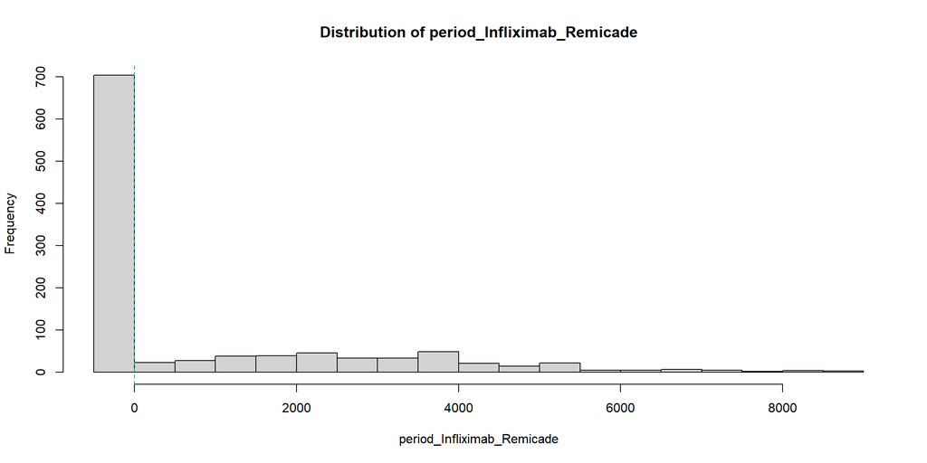

```r
# Visualize distribution
hist(combined_dataset_imputed$period_Infliximab_Remicade, breaks = 30,
     main = "Distribution of period_Infliximab_Remicade",
     xlab = "period_Infliximab_Remicade")
abline(v = c(0, median(combined_dataset_imputed$period_Infliximab_Remicade, na.rm = TRUE)),
       col = c( "#D95F02", "#1B9E77"), lty = 2)
```

```r
results <- categorize_and_test_predictor(
  data = combined_dataset_imputed,
  predictor_name = "period_Infliximab_Remicade",
  outcomes = flare_outcomes
)
# Add best categorizations to the main dataset
combined_dataset_imputed <- add_best_categorizations(data= combined_dataset_imputed,
                                                     predictor_name= "period_Infliximab_Remicade",
                                                     best_cat= "cat_q4"  )
summarize_chisq_for_factor(combined_dataset_imputed, "period_Infliximab_Remicade")
##
##  ================================================================================
## PROCESSING: period_Infliximab_Remicade
## ================================================================================
##
## Number of unique values: 362
## Number of valid observations: 1081
##
## Overall summary statistics:
##      Min.   1st Qu.    Median      Mean   3rd Qu.      Max.
##   -0.0833    0.0000    0.0000 1033.4682 1728.9583 8982.9583
##
## === CATEGORIZATION DISTRIBUTIONS ===
##
##  cat_q3 :
##
##    Low Medium   High
##    704     17    360
##
##  cat_q4 :
##
##         [-0.0833,0]        (0,1.73e+03] (1.73e+03,8.98e+03]
##                 704                 107                 270
##
##  cat_median :
##
##  Low High
##  704  377
##
##  cat_top25 :
##
## Normal   High
##    811    270
##
## === CHI-SQUARE TEST RESULTS ===
## # A tibble: 16 × 8
##    predictor       categorization outcome chi_sq    df p_value p_formatted     n
##    <chr>           <chr>          <chr>    <dbl> <int>   <dbl> <chr>       <int>
##  1 period_Inflixi… cat_top25      flare_…  1.16      1  0.281  0.2806       1081
##  2 period_Inflixi… cat_median     flare_…  1.06      1  0.304  0.3042       1081
##  3 period_Inflixi… cat_q3         flare_…  1.54      2  0.463  0.4630       1081
##  4 period_Inflixi… cat_q4         flare_…  1.42      2  0.491  0.4908       1081
##  5 period_Inflixi… cat_q3         flare_…  1.56      2  0.459  0.4588       1081
##  6 period_Inflixi… cat_median     flare_…  0.455     1  0.500  0.4999       1081
##  7 period_Inflixi… cat_top25      flare_…  0.297     1  0.586  0.5856       1081
##  8 period_Inflixi… cat_q4         flare_…  0.549     2  0.760  0.7601       1081
##  9 period_Inflixi… cat_top25      flare_…  1.03      1  0.310  0.3099       1081
## 10 period_Inflixi… cat_q4         flare_…  2.18      2  0.337  0.3368       1081
## 11 period_Inflixi… cat_q3         flare_…  0.332     2  0.847  0.8471       1081
## 12 period_Inflixi… cat_median     flare_…  0.033     1  0.856  0.8559       1081
## 13 period_Inflixi… cat_q4         flare_…  6.29      2  0.0431 0.0431       1081
## 14 period_Inflixi… cat_top25      flare_…  0.823     1  0.364  0.3644       1081
## 15 period_Inflixi… cat_q3         flare_…  1.23      2  0.542  0.5419       1081
## 16 period_Inflixi… cat_median     flare_…  0.278     1  0.598  0.5978       1081
##
## === BEST CATEGORIZATION FOR EACH OUTCOME ===
## # A tibble: 4 × 8
##   predictor        categorization outcome chi_sq    df p_value p_formatted     n
##   <chr>            <chr>          <chr>    <dbl> <int>   <dbl> <chr>       <int>
## 1 period_Inflixim… cat_top25      flare_…   1.16     1  0.281  0.2806       1081
## 2 period_Inflixim… cat_q3         flare_…   1.56     2  0.459  0.4588       1081
## 3 period_Inflixim… cat_top25      flare_…   1.03     1  0.310  0.3099       1081
## 4 period_Inflixim… cat_q4         flare_…   6.29     2  0.0431 0.0431       1081
##
## === DETAILED CROSSTABS FOR BEST CATEGORIZATIONS ===
##
##  --------------------------------------------------------------------------------
## OUTCOME: flare_date1 | CATEGORIZATION: cat_top25
## p-value: 0.2806 | N: 1081
## --------------------------------------------------------------------------------
##
## Frequency table:
##
##            0   1
##   Normal 268 543
##   High    79 191
##
## Row proportions (% within each category):
##
##             0    1
##   Normal 33.0 67.0
##   High   29.3 70.7
##
##  --------------------------------------------------------------------------------
## OUTCOME: flare_date2 | CATEGORIZATION: cat_q3
## p-value: 0.4588 | N: 1081
## --------------------------------------------------------------------------------
##
## Frequency table:
##
##            0   1
##   Low    390 314
##   Medium   7  10
##   High   193 167
##
## Row proportions (% within each category):
##
##             0    1
##   Low    55.4 44.6
##   Medium 41.2 58.8
##   High   53.6 46.4
##
##  --------------------------------------------------------------------------------
## OUTCOME: flare_date3 | CATEGORIZATION: cat_top25
## p-value: 0.3099 | N: 1081
## --------------------------------------------------------------------------------
##
## Frequency table:
##
##            0   1
##   Normal 581 230
##   High   184  86
##
## Row proportions (% within each category):
##
##             0    1
##   Normal 71.6 28.4
##   High   68.1 31.9
##
##  --------------------------------------------------------------------------------
## OUTCOME: flare_date4 | CATEGORIZATION: cat_q4
## p-value: 0.0431 | N: 1081
## --------------------------------------------------------------------------------
##
## Frequency table:
##
##                         0   1
##   [-0.0833,0]         599 105
##   (0,1.73e+03]        100   7
##   (1.73e+03,8.98e+03] 226  44
##
## Row proportions (% within each category):
##
##                          0    1
##   [-0.0833,0]         85.1 14.9
##   (0,1.73e+03]        93.5  6.5
##   (1.73e+03,8.98e+03] 83.7 16.3
## x
##        (0,1.73e+03] (1.73e+03,8.98e+03]         [-0.0833,0]
##                 107                 270                 704
##
## Chi-squared summary for predictor: period_Infliximab_Remicade
##         Flare ChiSq df p_value
## 1 flare_date1 1.424  2 0.49080
## 2 flare_date2 0.549  2 0.76010
## 3 flare_date3 2.177  2 0.33680
## 4 flare_date4 6.287  2 0.04313
```